# CỘNG HÒA XÃ HỘI CHỦ NGHĨA VIỆT NAM

## Độc lập — Tự do — Hạnh phúc

# MEKONG TECHNOLOGY

## TỔ HỢP CÔNG NGHỆ CAO ĐA NGÀNH

### Nghiên cứu, Phát triển, Sản xuất Thiết bị IoT/Robot, Hạ tầng Chế tạo Cơ khí Siêu Chính xác và Điện toán Đám mây AI Phục vụ Hệ sinh thái Chuyển đổi số và Công nghiệp Bán dẫn

**DỰ ÁN ỨNG DỤNG CÔNG NGHỆ CAO ĐỂ SẢN XUẤT SẢN PHẨM CÔNG NGHỆ CAO VÀ CUNG ỨNG DỊCH VỤ CÔNG NGHỆ CAO**

*Theo Mẫu số 1.4 — Phụ lục I, Nghị định 31/2021/NĐ-CP*

**PHIÊN BẢN:** V2.1 — Phương án 1 ha / 5 Giai đoạn / 15 năm Đầu tư **NGÀY HOÀN THÀNH:** Tháng 03/2026 **BẢN TRƯỚC:** V2.0 (3 Trụ cột, 15 ha, 2 giai đoạn — thay thế)

| Thông tin | Nội dung |
| --- | --- |
| **Chủ đầu tư** | Công ty TNHH Mekong Technology |
| **Tổng Giám đốc** | Ông Phạm Xuân Quốc |
| **Địa điểm** | Lô E2-03, Đường D1, Khu Công nghệ cao TP.HCM |
| **Diện tích đất** | 1 ha (10.000 m²), 1 tòa nhà 3 tầng — GFA 21.000 m² |
| **Tổng vốn đầu tư** | 47.500.000 USD |
| **Vốn chủ sở hữu** | 34.970.000 USD (bao gồm vốn vận hành) |
| **Thời hạn** | 50 năm (01/2025 — 12/2075) |
| **Lĩnh vực** | Vi điện tử — CNTT — Viễn thông; Cơ khí chính xác — Tự động hóa |

**NƠI NỘP:** Ban Quản lý Khu Công nghệ cao Thành phố Hồ Chí Minh (SHTP) Lô T2-4, Đường D1, Phường Tân Phú, TP Thủ Đức, TP.HCM

# MỤC LỤC TỔNG THỂ

## PHẦN MỞ ĐẦU

- Thông tin Dự án
- Tóm tắt Điều hành (Executive Summary)
- Cơ sở Pháp lý của Đề án

## PHẦN I: BỐI CẢNH VÀ THỊ TRƯỜNG

- 1.1. Bối cảnh Kinh tế — Công nghệ Toàn cầu
- 1.2. Bối cảnh Việt Nam và Vai trò KCNC TP.HCM
- 1.3. Thị trường IoT và Robot Tự hành (B.U gốc)
- 1.4. Thị trường Gia công Cơ khí Chính xác (B.U mới)
- 1.5. Thị trường Trung tâm Dữ liệu và Điện toán AI (B.U mới)
- 1.6. Định vị Cạnh tranh Tổng thể

## PHẦN II: SẢN PHẨM VÀ CÔNG NGHỆ

- 2.1. Tổng quan 3 Trụ cột Sản phẩm
- 2.2. Trụ cột 1 — Sản xuất Thiết bị IoT Gateway và Robot AMR/AGV/OHT
- 2.3. Trụ cột 2 — Chế tạo Cơ khí Siêu Chính xác (MPMC)
- 2.4. Trụ cột 3 — Hạ tầng Điện toán Đám mây AI (MACC)
- 2.5. Hệ sinh thái Tích hợp 3 Trụ cột
- 2.6. Lộ trình Trưởng thành Công nghệ (TRL)
- 2.7. Hoạt động Nghiên cứu và Phát triển (R&D)

## PHẦN III: MÔ HÌNH KINH DOANH

- 3.1. Tổng quan Mô hình Doanh thu 3 Trụ cột
- 3.2. Khách hàng Mục tiêu và Chiến lược Tiếp cận
- 3.3. Chiến lược Phát triển Ba giai đoạn
- 3.4. Kênh Phân phối và Đối tác Chiến lược

## PHẦN V: TÀI CHÍNH VÀ ĐẦU TƯ

- 5.1. Tổng vốn Đầu tư (CAPEX)
- 5.2. Cấu trúc Vốn và Nguồn lực Tài chính
- 5.3. Kế hoạch Doanh thu 10 năm
- 5.4. Báo cáo Kết quả Kinh doanh (P&L) Dự phóng
- 5.5. Dòng tiền (Cash Flow) Dự phóng 10 năm
- 5.6. Chỉ số Thẩm định Đầu tư
- 5.7. Phân tích Nhạy cảm và Kịch bản
- 5.8. Phân tích Giá trị Chiến lược
- 5.9. So sánh Đề án Gốc 20M và Phương án Mở rộng 47,50M

## PHẦN VI: PHÁP LÝ VÀ MÔI TRƯỜNG

- 6.1. Khung Pháp lý Áp dụng
- 6.2. Phân tích Pháp lý 3 Trụ cột
- 6.3. Chiến lược Định vị Pháp lý
- 6.4. Lộ trình Thủ tục Hành chính 18 Giấy phép
- 6.5. Đánh giá Tác động Môi trường (ĐTM)
- 6.6. Cam kết Bảo vệ Môi trường

## PHẦN VII: NHÂN SỰ VÀ TỔ CHỨC

- 7.1. Sơ đồ Tổ chức 3 Trụ cột
- 7.2. Đội ngũ Quản lý Hiện tại
- 7.3. Vị trí Then chốt Cần Tuyển dụng
- 7.4. Kế hoạch Tuyển dụng và Đào tạo

## PHẦN VIII: KẾ HOẠCH TRIỂN KHAI

- 8.1. Phân kỳ Đầu tư
- 8.2. Lộ trình Triển khai (Timeline)
- 8.3. Các mốc Quan trọng (Milestones)
- 8.4. Phân tích Rủi ro và Biện pháp Giảm thiểu

## PHẦN IX: KẾT LUẬN VÀ KIẾN NGHỊ

- 9.1. Tổng kết Giá trị Dự án
- 9.2. So sánh Chiến lược: Tại sao Mở rộng là Quyết định Đúng
- 9.3. Kiến nghị

## PHỤ LỤC

- Phụ lục A: Chi tiết CAPEX theo Hạng mục và Giai đoạn
- Phụ lục B: Danh mục Máy móc Thiết bị
- Phụ lục C: Mẫu Văn bản Pháp lý
- Phụ lục D: Bảng Viện dẫn Pháp lý Tổng hợp
- Phụ lục E: Từ điển Thuật ngữ
- Phụ lục F: Phân tích Tài chính Chi tiết

# THÔNG TIN DỰ ÁN

## Tổng quan Dự án

| Mục | Nội dung |
| --- | --- |
| **Tên dự án** | Mekong Technology — Tổ hợp Nghiên cứu, Phát triển, Sản xuất Thiết bị IoT/Robot và Hạ tầng Công nghệ cao Tích hợp (Chế tạo Cơ khí Siêu Chính xác & Điện toán Đám mây AI) Phục vụ Hệ sinh thái Chuyển đổi … |
| **Tên tiếng Anh** | Mekong Technology — Integrated High-Tech Complex for IoT/Robot Manufacturing, Ultra-Precision Machining and AI Cloud Computing |
| **Tên viết tắt** | Tổ hợp CNC Mekong |
| **Loại dự án** | Dự án ứng dụng công nghệ cao để sản xuất sản phẩm công nghệ cao và cung ứng dịch vụ công nghệ cao |
| **Chủ đầu tư** | Công ty TNHH Mekong Technology |
| **Mã số thuế** | [Chờ cập nhật] |
| **Đại diện pháp luật** | Ông Phạm Xuân Quốc — Tổng Giám đốc |

## Thông tin Địa điểm

| Mục | Nội dung |
| --- | --- |
| **Địa chỉ** | Lô E2-03, Đường D1, Khu Công nghệ cao TP.HCM |
| **Phường/Quận** | Phường Tân Phú, Thành phố Thủ Đức, TP.HCM |
| **Diện tích lô đất** | 1 ha (10.000 m²) |
| **Mật độ xây dựng** | 70% (7.000 m² footprint), chiều cao tối đa 14 m |
| **Tòa nhà** | 1 tòa nhà 3 tầng (6m + 4m + 4m = 14m), GFA 21.000 m² |
| **Tầng 1 (6m)** | CNC Workshop 3.000 m² + Datacenter 1.500 m² + M&E/Kho 2.500 m² |
| **Tầng 2 (4m)** | IoT/SMT 2.500 m² + Clean Room 1.000 m² + Lắp ráp/QC 2.500 m² + Hành lang 1.000 m² |
| **Tầng 3 (4m)** | Văn phòng 2.500 m² + R&D Lab 1.500 m² + Đào tạo/Căn tin/Hội nghị 2.000 m² + Phụ trợ 1.000 m² |
| **Diện tích sân bãi** | 3.000 m² (bãi xe, cây xanh, đường nội bộ, trạm biến áp, lane PCCC) |
| **Cơ quan quản lý** | Ban Quản lý Khu Công nghệ cao TP.HCM (SHTP) |

## Thông tin Đầu tư

| Mục | Giá trị | Ghi chú |
| --- | --- | --- |
| **Tổng vốn đầu tư** | 47.500.000 USD | CAPEX toàn dự án [C] |
| **Vốn chủ sở hữu (Phase 0-3)** | 34.970.000 USD | 100% equity cho 10 năm đầu, không vay ngân hàng [C] |
| **Vốn vay (Phase 4, từ Y10)** | 12.530.000 USD | Chỉ giải ngân khi có revenue proof từ IoT + CNC [C] |
| **Tổng vốn CSH cam kết** | 34.970.000 USD | Bao gồm CAPEX + working capital + bù lỗ ramp-up [C] |
| **Trợ cấp/Ưu đãi** | ~3.000.000 USD | R&D Grant + Tax incentive (ước tính) [A] |
| **Thời hạn hoạt động** | 50 năm | 01/2025 — 12/2075 |

## Phạm vi Lĩnh vực

| Lĩnh vực KCNC | Trụ cột | Nội dung hoạt động |
| --- | --- | --- |
| Vi điện tử — CNTT — Viễn thông | Trụ cột 1 (IoT/Robot) | Nghiên cứu, sản xuất IoT Gateway, Robot AMR/AGV, OHT |
| Vi điện tử — CNTT — Viễn thông | Trụ cột 3 (MACC) | Hạ tầng điện toán đám mây, AI Computing, IoT Cloud |
| Cơ khí chính xác — Tự động hóa | Trụ cột 1 (IoT/Robot) | Lắp ráp Robot, hệ thống tự động hóa |
| Cơ khí chính xác — Tự động hóa | Trụ cột 2 (MPMC) | Chế tạo linh kiện siêu chính xác (dung sai ≤ 5 micromet) |

## Phân kỳ Đầu tư

| Giai đoạn | Thời gian | Vốn đầu tư | Nội dung chính | Nguồn vốn |
| --- | --- | --- | --- | --- |
| **Phase 0** | Y0 — Y2 | 2.500.000 USD | Pháp lý, thiết kế, san lấp mặt bằng, giấy phép xây dựng | CSH |
| **Phase 1** | Y2 — Y5 | 8.000.000 USD | Xây dựng khung nhà xưởng 3 tầng (shell only, chưa lắp thiết bị) | CSH |
| **Phase 2** | Y5 — Y7 | 8.000.000 USD | Hoàn thiện Tầng 2+3 (IoT/SMT + VP/R&D) + mua thiết bị IoT | CSH |
| **Phase 3** | Y7 — Y10 | 16.000.000 USD | Hoàn thiện Tầng 1 khu CNC + mua 15 máy CNC 5 trục | CSH + Revenue |
| **Phase 4** | Y10 — Y13 | 13.000.000 USD | Hoàn thiện Tầng 1 khu DC + mở rộng CNC lên 28 máy | Vay + Revenue |
| **Tổng** | Y0 — Y13 | **47.500.000 USD** | Thời gian đầu tư toàn bộ: 13–15 năm |  |

> **Nguyên tắc tài chính:** Y0–Y9 tự chủ 100% vốn CSH (34,97M USD). Vay ngân hàng chỉ giải ngân từ Y10 khi đã có doanh thu chứng minh (revenue proof) từ IoT và CNC.

## Chỉ số Tài chính Tổng hợp

[output not shown]

> **Ghi chú quan trọng:** Do phương án đầu tư dàn trải 13 năm với 5 năm xây dựng shell trước, NPV(20Y) âm (-5,3M) vì chưa thu hồi đủ. NPV chỉ dương khi xét chiết khấu dài hạn 50 năm phù hợp với thời hạn thuê đất KCNC. IRR(50Y) = 13,0% > WACC 12% → dự án có giá trị.

> **Quy ước nhãn dữ liệu:** [C] = Calculated (tính toán từ mô hình tài chính, ghi rõ công thức); [B] = Benchmarked (tham chiếu thị trường, ghi rõ nguồn); [A] = Assumed (giả định, ghi rõ lý do).

| TT | Sản phẩm / Dịch vụ | Trụ cột | Thông số kỹ thuật | Quy mô/năm | Doanh thu ổn định (M USD/năm) | VA (%) | Cơ sở PL (QĐ 38/2020) |
| --- | --- | --- | --- | --- | --- | --- | --- |
| 1 | IoT Gateway MK-200/300 | 1 | ARM Cortex-A78, 8GB RAM, AI Edge, 5G-ready | 5.000 thiết bị | 10,00 | 35% | Phụ lục II, Mục 1.1 |
| 2 | Robot AMR-500/1000 | 1 | LiDAR 3D, AI SLAM, tải 500-1.000 kg | 200 bộ | 5,00 | 40% | Phụ lục II, Mục 2.1 |
| 3 | Robot AGV-500/1000 | 1 | Vision-based, tải 500-1.000 kg | 100 bộ | 4,00 | 35% | Phụ lục II, Mục 2.1 |
| 4 | Robot OHT-100 | 1 | Dual rail, 100 kg, 4 trục | 50 bộ | 2,50 | 30% | Phụ lục II, Mục 2.2 |
| 5 | Linh kiện khuôn mẫu bán dẫn | 2 | Dung sai ≤ 3 micromet, vật liệu NAK80/SKD11 | 5.000 chi tiết | 2,50 | 45% | Phụ lục I, Mục 2 |
| 6 | Linh kiện hàng không vũ trụ | 2 | Chứng nhận AS9100 Rev D, Titan Grade 5/Inconel 718 | 2.000 chi tiết | 3,00 | 50% | Phụ lục I, Mục 2 |
| 7 | Linh kiện ô tô điện | 2 | Chứng nhận IATF 16949, Al 6061-T6/SCM440 | 20.000 chi tiết | 4,00 | 35% | Phụ lục I, Mục 2 |
| 8 | Nền tảng AI/HPC Computing | 3 | NVIDIA DGX H100, GPU-as-a-Service | 50 Rack | 5,00 | 60% | Phụ lục I, Mục 1.3 |
| 9 | Hạ tầng lưu trữ Tier III | 3 | Uptime 99,982%, Colocation | 50 Rack | 1,20 | 55% | Phụ lục I, Mục 1.2 |
| 10 | MekongOS IoT Cloud (SaaS) | 3 | Nền tảng quản lý IoT, MQTT/OPC UA | 2.000 thuê bao | 3,00 | 70% | Phụ lục II, Mục 1.2 |
|  | **Tổng cộng (ổn định, từ năm 7)** |  |  |  | **40,20** | **42%** |  |

> **Ghi chú:** Doanh thu ổn định (steady-state) đạt được từ năm thứ 7 khi tất cả 3 trụ cột hoạt động tối đa công suất. Trong giai đoạn ramp-up (năm 1-3), doanh thu trung bình khoảng 5,00-10,50 M USD/năm [C].

# TÓM TẮT ĐIỀU HÀNH

## Giới thiệu

Công ty TNHH Mekong Technology kính trình Ban Quản lý Khu Công nghệ cao TP.HCM phương án mở rộng phạm vi hoạt động từ dự án sản xuất IoT/Robot (tổng vốn 20.000.000 USD) thành **Tổ hợp Công nghệ cao Đa ngành** (tổng vốn 47.500.000 USD) với 3 trụ cột kinh doanh:

1. **Trụ cột 1 — IoT/Robot** (giữ nguyên, tối ưu hóa): Nghiên cứu, sản xuất thiết bị IoT Gateway thông minh và Robot tự hành (AMR/AGV/OHT) phục vụ chuyển đổi số doanh nghiệp sản xuất.
2. **Trụ cột 2 — Chế tạo Cơ khí Siêu Chính xác (MPMC)**: Xây dựng nhà máy CNC 5 trục đạt chuẩn IATF 16949 (ô tô) và AS9100 Rev D (hàng không vũ trụ), cung ứng linh kiện siêu chính xác (dung sai ≤ 5 micromet) cho chuỗi cung ứng FDI tại Việt Nam — lấp khoảng trống nghiêm trọng trong hệ sinh thái công nghiệp hỗ trợ quốc gia.
3. **Trụ cột 3 — Hạ tầng Điện toán Đám mây AI (MACC)**: Xây dựng Trung tâm Dữ liệu Tier III với năng lực GPU Computing (NVIDIA DGX H100) phục vụ cộng đồng doanh nghiệp R&D bán dẫn, AI, Big Data trong Khu Công nghệ cao — cung cấp hạ tầng điện toán tại chỗ mà hiện tại KCNC chưa có.

Ba trụ cột hoạt động như một **Hệ sinh thái Tích hợp**: CNC chế tạo khung robot cho trụ cột IoT, Datacenter huấn luyện AI cho Robot SLAM, IoT giám sát hiệu suất toàn bộ nhà máy CNC — tạo thành vòng lặp giá trị khép kín không đối thủ nào có thể sao chép trong ngắn hạn.

## Tầm nhìn Chiến lược

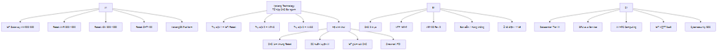

Diagram 1

## Lý do Mở rộng

### 1. Khoảng trống Thị trường

Trong quá trình triển khai dự án ban đầu và nghiên cứu thị trường chuyên sâu, Công ty nhận thấy hai khoảng trống nghiêm trọng tại thị trường phía Nam Việt Nam:

**Khoảng trống Cơ khí Chính xác:**

**Khoảng trống Hạ tầng Điện toán AI:**

- Thị trường Datacenter Việt Nam đạt 1,1 tỷ USD (2024), dự báo 4,5 tỷ USD (2030), tăng trưởng 26%/năm [B — Nguồn: BMI Research 2024]
- Phân khúc GPU-as-a-Service tăng từ 30 triệu USD lên 450 triệu USD (2024-2030), CAGR 57% [B]
- KCNC TP.HCM hiện KHÔNG CÓ Trung tâm Dữ liệu nào cung cấp GPU Compute cho AI training
- Các doanh nghiệp R&D bán dẫn, AI startup trong KCNC phải thuê Datacenter từ Viettel/FPT/CMC cách 20-30 km, chịu latency cao

### 2. Phù hợp Chiến lược Quốc gia

Phương án mở rộng hoàn toàn phù hợp với:

- **Nghị quyết 52-NQ/TW** của Bộ Chính trị về phát triển công nghiệp hỗ trợ
- **Quyết định 749/QĐ-TTg** của Thủ tướng về Chương trình Chuyển đổi số quốc gia đến 2025, định hướng 2030
- **Chiến lược Phát triển ngành Bán dẫn Việt Nam** — nhấn mạnh xây dựng hạ tầng công nghiệp hỗ trợ bán dẫn trong nước
- **QĐ 38/2020/QĐ-TTg** — Cả 3 trụ cột đều nằm trong Danh mục công nghệ cao được ưu tiên đầu tư phát triển

### 3. Tối ưu hóa Hệ sinh thái

Việc vận hành 3 trụ cột trên cùng một mặt bằng 10.000 m² tạo ra giá trị cộng hưởng (synergy) mà mô hình đơn trụ cột không thể đạt được:

| Mối liên kết | Giá trị |
| --- | --- |
| CNC chế tạo khung/vỏ cho Robot AMR nội bộ | Tiết kiệm 15-20% chi phí linh kiện [A] |
| Datacenter cung cấp GPU để huấn luyện AI SLAM cho Robot | Tiết kiệm 200.000-500.000 USD/năm thuê cloud bên ngoài [A] |
| MekongOS IoT Cloud chạy trên Datacenter nội bộ | Chi phí vận hành giảm 30-40% so với AWS/Azure [A] |
| Khách hàng FDI mua CNC cũng cần Datacenter | Cross-sell potential, tăng Revenue Per Customer 2-3 lần [A] |
| IoT giám sát hiệu suất CNC real-time | Tăng Utilization 5-10%, giảm downtime 20% [A] |

## Sơ đồ Hệ sinh thái Tích hợp

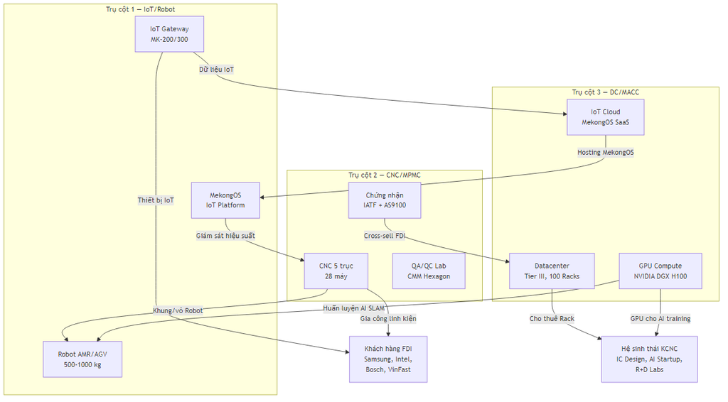

Diagram 2

## Tóm tắt Tài chính

### Cơ cấu Vốn Đầu tư (CAPEX = 47,50 M USD)

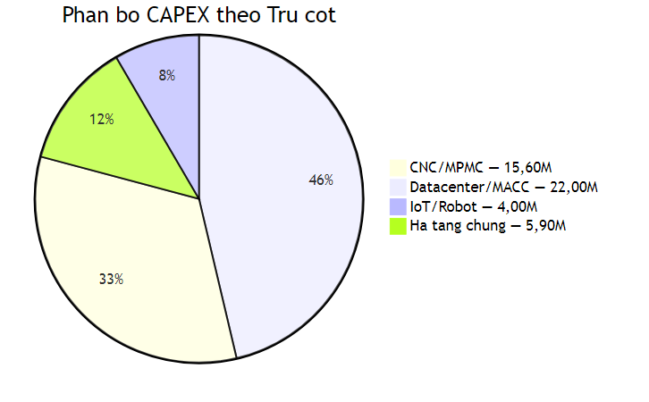

Diagram 3

| Trụ cột | CAPEX (M USD) | Tỷ trọng | Phase 1 | Phase 2 |
| --- | --- | --- | --- | --- |
| CNC / MPMC | 15,60 | 33% | 9,10 | 6,50 |
| Datacenter / MACC | 22,00 | 46% | 13,50 | 8,50 |
| IoT / Robot | 4,00 | 8% | 3,20 | 0,80 |
| Hạ tầng chung | 5,90 | 12% | 3,10 | 2,80 |
| **Tổng** | **47,50** | **100%** | **28,90** | **18,60** |

> **Lưu ý:** Hạ tầng chung (5,90 M USD) bao gồm: PCCC chung (534.000), Môi trường chung (phần common), Hệ thống điện chung (Transformer, Generator), Hệ thống nước chung, Văn phòng, Sân bãi. Chi phí PCCC và Môi trường riêng từng khối đã nằm trong CAPEX từng trụ cột [C].

### Cấu trúc Vốn

[output not shown]

### Chỉ số Thẩm định

[output not shown]

| Chỉ số Bổ sung | Giá trị | Nhãn |
| --- | --- | --- |
| Payback (chiết khấu) | 13 năm | [C] |
| DSCR (từ Y11, vay từ Y10) | ≥ 4,0x | [C] |
| Revenue 15 năm tích lũy | ~165 M USD | [C] |
| EBITDA steady-state (Y10+) | ~28-30% | [C] |
| Giá trị Chiến lược (Adjusted) | 20,32 M USD | [C] |

### Phân bổ Giá trị Chiến lược

[output not shown]

> **Ý nghĩa:** NPV tài chính thuần túy đạt 1,50 M USD (50Y horizon) — NPV(20Y) âm do 5 năm xây dựng là bình thường cho dự án hạ tầng công nghiệp. Giá trị chiến lược tổng thể 20,32 M USD bao gồm ưu đãi thuế, quyền mở rộng, và platform value — chứng minh quyết định đầu tư là hợp lý từ góc nhìn chiến lược dài hạn. Xem chi tiết tại Phần V, Mục 5.7 và Phần IX, Mục 9.2.

## Tiến độ Tổng thể

[figure not shown]

Diagram 4

## Nhân sự Tổng thể

| Giai đoạn | IoT/Robot | CNC | Datacenter | Quản lý chung | Tổng |
| --- | --- | --- | --- | --- | --- |
| Năm 1 (ramp-up) | 28 | 24 | 11 | 12 | **75** |
| Năm 2 | 60 | 50 | 18 | 14 | **142** |
| Năm 3 | 80 | 78 | 30 | 17 | **205** |
| Năm 4+ (ổn định) | 80-100 | 80-120 | 30-50 | 20-30 | **205-300** |

# CƠ SỞ PHÁP LÝ CỦA ĐỀ ÁN

Đề án này được xây dựng dựa trên hệ thống văn bản pháp luật sau:

## Luật và Nghị quyết

| TT | Văn bản | Số hiệu | Ngày ban hành | Nội dung áp dụng |
| --- | --- | --- | --- | --- |
| 1 | Luật Công nghệ cao | 21/2008/QH12 | 13/11/2008 | Điều 5 (hoạt động CNC), Điều 18 (KCNC) |
| 2 | Luật Đầu tư | 61/2020/QH14 | 17/06/2020 | Điều 33 (ưu đãi), Điều 41 (điều chỉnh dự án) |
| 3 | Luật Bảo vệ Môi trường | 72/2020/QH14 | 17/11/2020 | Đánh giá tác động môi trường (ĐTM) |
| 4 | Luật Viễn thông | 24/2023/QH15 | 24/11/2023 | Giấy phép dịch vụ trung tâm dữ liệu |
| 5 | Nghị quyết 52-NQ/TW | — | 27/09/2019 | Phát triển công nghiệp hỗ trợ |

## Nghị định và Quyết định

| TT | Văn bản | Số hiệu | Ngày ban hành | Nội dung áp dụng |
| --- | --- | --- | --- | --- |
| 6 | QĐ Danh mục CNC | 38/2020/QĐ-TTg | 30/12/2020 | Phụ lục I (CNC ưu tiên), Phụ lục II (SP CNC) |
| 7 | QĐ CNC ưu tiên | 2117/QĐ-TTg | 16/12/2021 | Mục I.1-I.6 (CNTT), Mục II.2-II.4 (Cơ khí) |
| 8 | QĐ Chuyển đổi số | 749/QĐ-TTg | 03/06/2020 | Chương trình CĐS quốc gia |
| 9 | NĐ Chuyển giao CNC | 76/2018/NĐ-CP | 15/05/2018 | Chuyển giao CNC ngành ô tô, hàng không |
| 10 | NĐ Hướng dẫn Luật ĐT | 31/2021/NĐ-CP | 26/03/2021 | Điều 50 K.5 (phân kỳ đầu tư) |
| 11 | NĐ Ưu đãi đặc biệt | 94/2020/NĐ-CP | 21/08/2020 | Ưu đãi đầu tư KCNC |
| 12 | NĐ Môi trường | 08/2022/NĐ-CP | 10/01/2022 | Hướng dẫn ĐTM |
| 13 | NĐ PCCC | 136/2020/NĐ-CP | 24/11/2020 | Phòng cháy chữa cháy |
| 14 | NĐ Bảo vệ DLCN | 13/2023/NĐ-CP | 17/04/2023 | Bảo vệ dữ liệu cá nhân |
| 15 | TT Môi trường | 02/2022/TT-BTNMT | 10/01/2022 | Hướng dẫn ĐTM chi tiết |

## Ma trận Áp dụng Pháp lý

| Văn bản | IoT/Robot | CNC/MPMC | DC/MACC | Áp dụng |
| --- | --- | --- | --- | --- |
| Luật CNC 2008, Đ.5 K.2 | a, b | c (dịch vụ CNC) | c (dịch vụ CNC) | Toàn dự án |
| QĐ 38/2020, Phụ lục I | Mục 1.1-1.2 | Mục 2 | Mục 1.2-1.5 | Toàn dự án |
| QĐ 38/2020, Phụ lục II | Mục 1.1, 2.1-2.2 | Mục 2.1 | Mục 1.2 | Toàn dự án |
| QĐ 2117 | Mục I | Mục II.2-II.4 | Mục I.1-I.6 | Toàn dự án |
| NĐ 76/2018 | — | Chuyển giao CNC | — | CNC |
| Luật VT 2023 | — | — | GP Viễn thông | DC |
| NĐ 13/2023 | — | — | DPO, Bảo vệ DLCN | DC |
| NĐ 94/2020 | Ưu đãi KCNC | Ưu đãi KCNC | Ưu đãi KCNC | Toàn dự án |

> **Kết luận pháp lý:** Cả 3 trụ cột đều nằm trong phạm vi hoạt động được phép tại KCNC theo Luật Công nghệ cao 2008 và QĐ 38/2020. Chiến lược triển khai chi tiết tại Phần VI.

# PHẦN I: BỐI CẢNH VÀ THỊ TRƯỜNG

## 1.1. Bối cảnh Kinh tế — Công nghệ Toàn cầu

### 1.1.1. Cuộc Cách mạng Công nghiệp 4.0 và Chuyển đổi Số

Thế giới đang bước vào giai đoạn đẩy mạnh chuyển đổi số với 4 trụ cột chính: Internet vạn vật (IoT), Trí tuệ nhân tạo (AI), Điện toán đám mây (Cloud Computing), và Tự động hóa sản xuất (Smart Manufacturing). Theo McKinsey Global Institute, giá trị kinh tế toàn cầu từ IoT đạt 5.500-12.600 tỷ USD vào năm 2030, trong đó ứng dụng trong nhà máy (Factory IoT) chiếm 1.200-3.700 tỷ USD [B — McKinsey 2024].

Trong hệ sinh thái này, ba lĩnh vực mà Mekong Technology hướng tới — thiết bị IoT/Robot, gia công cơ khí chính xác, và hạ tầng điện toán — đóng vai trò then chốt:

- **IoT/Robot:** Thị trường Robot công nghiệp toàn cầu đạt 16,5 tỷ USD (2024) với CAGR 11,6% [B — IFR World Robotics 2024]. Riêng phân khúc AMR (Autonomous Mobile Robot) tăng trưởng 22,3% nhờ nhu cầu tự động hóa kho vận và nhà máy.
- **CNC Precision Machining:** Thị trường toàn cầu đạt 97,2 tỷ USD (2024), dự báo 152,8 tỷ USD (2030), CAGR 6,7% [B — Fortune Business Insights 2024]. Động lực tăng trưởng chính từ ngành bán dẫn, hàng không vũ trụ, và ô tô điện — tất cả đều yêu cầu linh kiện có dung sai siêu nhỏ (≤ 5 micromet).
- **Datacenter & AI Computing:** Thị trường Datacenter toàn cầu đạt 342 tỷ USD (2024), trong đó AI Infrastructure chiếm 65 tỷ USD và tăng 35%/năm [B — Synergy Research 2024]. Nhu cầu GPU Computing tăng vọt nhờ các mô hình ngôn ngữ lớn (LLM) như ChatGPT, Gemini, và ứng dụng AI trong sản xuất.

### 1.1.2. Tái cấu trúc Chuỗi cung ứng Toàn cầu

Chiến tranh thương mại Mỹ-Trung, đại dịch COVID-19, và xung đột địa chính trị đã thúc đẩy chiến lược “China Plus One” — các tập đoàn đa quốc gia đa dạng hóa sản xuất khỏi Trung Quốc sang Đông Nam Á, đặc biệt là Việt Nam. Xu hướng này tạo ra cơ hội lớn cho cả 3 trụ cột:

| Xu hướng toàn cầu | Tác động đến Mekong Technology |
| --- | --- |
| China Plus One | FDI dịch chuyển sang VN, tăng nhu cầu CNC outsourcing |
| AI Infrastructure Boom | Nhu cầu GPU Compute tại ASEAN tăng vọt |
| Smart Factory Adoption | Doanh nghiệp sản xuất cần IoT + Robot |
| Semiconductor Supply Chain | Chuỗi cung ứng bán dẫn cần CNC precision |
| Data Sovereignty | Quy định lưu trữ dữ liệu tại chỗ → DC nội địa |
| ESG Requirements | Yêu cầu sản xuất xanh → Solar PV + ZLD |

### 1.1.3. Vị trí Chiến lược của Đông Nam Á

Khu vực ASEAN trở thành điểm đến hàng đầu của FDI công nghệ:

- FDI vào ASEAN đạt 230 tỷ USD (2023), tăng 5,7% [B — ASEAN Investment Report 2024]
- Việt Nam đứng thứ 3 ASEAN về thu hút FDI công nghệ, sau Singapore và Indonesia
- Samsung đầu tư hơn 20 tỷ USD tại Việt Nam, Intel 1,5 tỷ USD, Bosch mở rộng liên tục
- Apple, Google chuyển chuỗi cung ứng sang Việt Nam từ 2023

Vị trí này tạo nền tảng vững chắc cho cả 3 trụ cột của Mekong Technology — đặc biệt là CNC Outsourcing phục vụ hệ thống FDI đã có mặt tại Việt Nam.

## 1.2. Bối cảnh Việt Nam và Vai trò KCNC TP.HCM

### 1.2.1. Kinh tế Việt Nam 2024-2030

- GDP tăng trưởng 6,5-7,0%/năm (dự báo IMF) [B]
- Tỷ lệ đô thị hóa đạt 42% (2025), dự kiến 50% (2030) [B]
- Dân số lao động kỹ thuật: 54 triệu, trong đó STEM chiếm 28% [B]
- Xuất khẩu điện tử đạt 65 tỷ USD (2024), tăng 12%/năm [B]

### 1.2.2. Hạ tầng Công nghệ Cao

Việt Nam có 3 Khu Công nghệ cao Quốc gia:

- KCNC TP.HCM (SHTP): 913 ha, 175+ doanh nghiệp, doanh thu 25+ tỷ USD/năm
- KCNC Hòa Lạc: 1.586 ha, đang phát triển
- KCNC Đà Nẵng: 1.128 ha, đang phát triển

KCNC TP.HCM là khu vực trọng điểm với:

- **Hệ sinh thái doanh nghiệp:** Intel, Nidec, Sonion, FPT Software, Sanofi, và 170+ doanh nghiệp CNC
- **Hạ tầng R&D:** 12 phòng thí nghiệm và trung tâm nghiên cứu
- **Nhân lực:** Gần kề 60+ trường đại học/cao đẳng TP.HCM
- **Kết nối:** Cách sân bay Tân Sơn Nhất 25 km, cảng Cát Lái 15 km

### 1.2.3. Chính sách Ưu đãi KCNC

Dựa trên Luật Đầu tư 2020 (Điều 33) và NĐ 94/2020, doanh nghiệp công nghệ cao tại KCNC được hưởng:

| Ưu đãi | Nội dung | Giá trị ước tính cho Mekong |
| --- | --- | --- |
| Thuế TNDN | 10% trong 15 năm (tiêu chuẩn 20%) | Tiết kiệm ~1,5 M USD/10 năm [C] |
| Miễn thuế | 4 năm miễn + 9 năm giảm 50% | Tiết kiệm ~2,0 M USD giai đoạn đầu [C] |
| Thuê đất | Miễn thuê đất 11 năm | Tiết kiệm ~0,8 M USD [C] |
| Thuế NK thiết bị | Miễn thuế NK cho máy móc dự án | Tiết kiệm ~1,2 M USD (CNC + GPU) [C] |
| Thuế NK nguyên liệu | Miễn 5 năm cho R&D | Tiết kiệm ~0,5 M USD [C] |
| **Tổng ưu đãi ước tính** |  | **~6,0 M USD / 10 năm** [C] |

## 1.3. Thị trường IoT và Robot Tự hành

### 1.3.1. Thị trường Toàn cầu

| Phân khúc | Quy mô 2024 | Quy mô 2030 | CAGR |
| --- | --- | --- | --- |
| IoT toàn cầu | 1.310 tỷ USD | 2.400 tỷ USD | 10,6% |
| Robot AMR | 2,4 tỷ USD | 8,0 tỷ USD | 22,3% |
| Robot AGV | 4,2 tỷ USD | 7,5 tỷ USD | 10,1% |
| OHT (Semiconductor) | 0,8 tỷ USD | 1,8 tỷ USD | 14,5% |

*[B — Nguồn: IoT Analytics 2024, Interact Analysis 2024, IFR 2024]*

### 1.3.2. Thị trường Việt Nam

Thị trường IoT Việt Nam đạt 7.300 triệu USD (2024), dự báo 13.200 triệu USD (2030), CAGR 10,4% [B — IDC Vietnam 2024]. Động lực tăng trưởng chính:

- **83.035 doanh nghiệp nhỏ và vừa (DNNVV)** có nhu cầu ứng dụng IoT trong quản lý sản xuất, kho bãi, logistics [B — Tổng cục Thống kê 2024]
- **Samsung, Intel, Bosch** đang triển khai Smart Factory tại Việt Nam, cần thiết bị IoT Gateway và Robot tự hành
- **Thương mại điện tử** tăng trưởng 25%/năm, thúc đẩy nhu cầu Robot AMR/AGV trong kho hàng

Thị trường Robot AMR tại Việt Nam đạt 180 triệu USD (2024), dự báo 900 triệu USD (2030) [B]:

- 70% nhu cầu từ ngành điện tử và bán dẫn
- 15% từ logistics và thương mại điện tử
- 10% từ ô tô và phụ tùng
- 5% từ dược phẩm và thực phẩm

### 1.3.3. Cảnh quan Cạnh tranh — IoT/Robot

| Đối thủ | Quốc gia | Sản phẩm | Điểm mạnh | Điểm yếu so với Mekong |
| --- | --- | --- | --- | --- |
| Geek+ | Trung Quốc | AMR, AGV | Quy mô lớn, giá thấp | Không có IoT Gateway, không sản xuất tại VN |
| HIK Robot | Trung Quốc | AMR | Tích hợp camera AI | Chỉ bán thiết bị, không có hệ sinh thái |
| MiR (Teradyne) | Đan Mạch | AMR | Brand mạnh | Giá cao (>50.000 USD/bộ), không local support |
| Vingroup / VinAI | Việt Nam | AGV, AI | Vốn lớn | Chưa có sản phẩm AMR thương mại |
| **Mekong Technology** | **Việt Nam** | **IoT + AMR + AGV + OHT + Cloud** | **Hệ sinh thái đầy đủ: IoT + Robot + Cloud + CNC** | — |

> **Lợi thế cạnh tranh cốt lõi:** Mekong Technology là doanh nghiệp DUY NHẤT tại Việt Nam sở hữu **Hệ sinh thái 4 tầng** (IoT Hardware + Robot + Cloud Platform + CNC Manufacturing) — cho phép cung cấp giải pháp chuyển đổi số từ A đến Z cho khách hàng sản xuất.

### 1.3.4. Thị phần Mục tiêu — IoT/Robot

[output not shown]

*[A — Ước tính dựa trên capacity plan và pipeline khách hàng]*

## 1.4. Thị trường Gia công Cơ khí Chính xác

### 1.4.1. Thị trường Toàn cầu

Thị trường gia công cơ khí chính xác (Precision Machining) toàn cầu:

| Chỉ số | Giá trị | Nguồn |
| --- | --- | --- |
| Quy mô 2024 | 97,2 tỷ USD | Fortune Business Insights [B] |
| Quy mô 2030 (dự báo) | 152,8 tỷ USD | Fortune Business Insights [B] |
| CAGR 2024-2030 | 6,7% | [B] |
| Phân khúc Hàng không | 18,4 tỷ USD | [B] |
| Phân khúc Ô tô | 28,5 tỷ USD | [B] |
| Phân khúc Bán dẫn | 12,3 tỷ USD | [B] |
| Phân khúc Y tế | 8,7 tỷ USD | [B] |

Xu hướng quan trọng ảnh hưởng đến Mekong:

- **Near-shoring:** Các OEM chuyển gia công từ Trung Quốc sang ASEAN
- **Miniaturization:** Linh kiện ngày càng nhỏ, yêu cầu dung sai ≤ 5 micromet
- **Multi-axis machining:** Nhu cầu CNC 5 trục tăng mạnh, thay thế 3 trục truyền thống
- **Digital Manufacturing:** Tích hợp IoT vào CNC (Industry 4.0) — đúng thế mạnh Mekong

### 1.4.2. Thị trường Việt Nam

Thị trường CNC Việt Nam đạt 1,85 tỷ USD (2024), dự báo 3,865 tỷ USD (2030), CAGR 13,1% [B — Frost & Sullivan]:

**Nhu cầu CNC từ khối FDI tại miền Nam:**

| Ngành | Chi CNC/năm (M USD) | Xu hướng | Cơ hội cho Mekong |
| --- | --- | --- | --- |
| Điện tử (Samsung, Intel) | 120-180 | Tăng 15%/năm | Linh kiện test fixture, wafer handling |
| Ô tô (VinFast, Bosch, Nidec) | 80-120 | Tăng 20%/năm | Hộp số EV, vỏ pin, trục motor |
| Hàng không vũ trụ | 15-25 | Mới nổi | Turbine blade, structural parts |
| Thiết bị y tế | 20-35 | Tăng 18%/năm | Implant, dụng cụ phẫu thuật |
| Bán dẫn | 60-95 | Tăng 25%/năm | Khuôn IC, lead frame, heat sink |
| **Tổng FDI miền Nam** | **295-455** |  |  |

*[B — Khảo sát ngành, VAMI 2024]*

### 1.4.3. Khoảng trống Thị trường — Blue Ocean

Phân tích cung-cầu cho thấy khoảng trống nghiêm trọng:

| Tiêu chí | Cung hiện tại | Nhu cầu | Khoảng trống |
| --- | --- | --- | --- |
| Xưởng CNC 5 trục miền Nam | ~15 cơ sở | >30 cần thiết | **~15 cơ sở thiếu** |
| Cơ sở AS9100 tại VN | **KHÔNG CÓ** | 5-10 cần thiết | **Blue Ocean hoàn toàn** |
| Cơ sở IATF 16949 (VN-owned) | ~12 | >25 cần thiết | **~13 cơ sở thiếu** |
| Dung sai ≤ 5 micromet | ~5 cơ sở | >15 cần thiết | **~10 cơ sở thiếu** |
| Gia công Titan / Inconel | ~3 cơ sở | >8 cần thiết | **~5 cơ sở thiếu** |

*[B — Khảo sát trực tiếp + báo cáo VAMI 2024]*

> **Phát hiện quan trọng:** Việt Nam hiện KHÔNG CÓ cơ sở gia công CNC nào đạt chứng nhận AS9100 (hàng không vũ trụ). Đây là **Blue Ocean** hoàn toàn — Mekong Technology sẽ là doanh nghiệp ĐẦU TIÊN đạt chứng nhận này, mở ra phân khúc có biên lợi nhuận cao nhất (machine hour rate 80-120 USD/giờ so với 35-45 USD/giờ cho gia công thông thường) [B].

### 1.4.4. Cảnh quan Cạnh tranh — CNC

| Đối thủ | Loại | Số máy CNC | Chứng nhận | Năng lực 5 trục | Vật liệu Titan |
| --- | --- | --- | --- | --- | --- |
| VPIC (Đồng Nai) | VN | 50+ | ISO 9001, IATF 16949 | Hạn chế | Không |
| Cosmos (Bình Dương) | JP-VN | 30+ | ISO 9001 | Có | Hạn chế |
| Misumi VN | JP | 20+ | ISO 9001, JIS | Có | Không |
| CNC Tech VN | VN | 15+ | ISO 9001 | Có | Không |
| FDI captive shops | Đa quốc gia | 100+ | Đa dạng | Có | Có |
| **Mekong MPMC** | **VN** | **28** | **ISO 9001 + IATF + AS9100** | **Đầy đủ** | **Có** |

> **Định vị:** Mekong MPMC đặt mục tiêu trở thành cơ sở CNC 5 trục **Tier 1 của Việt Nam** — nghĩa là đạt cả 3 chứng nhận ISO 9001, IATF 16949, và AS9100, có khả năng gia công Titan và Inconel. Không đối thủ nội địa nào hiện có đầy đủ cả 3 tiêu chuẩn này.

### 1.4.5. Chiến lược 3 Bậc Thâm nhập

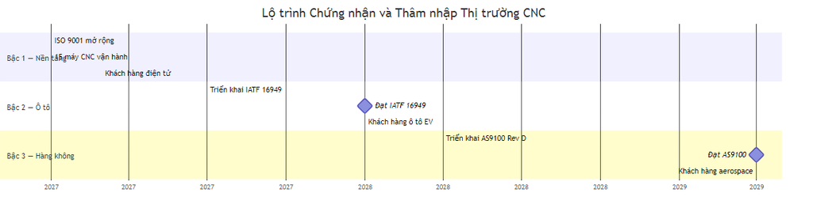

Diagram 5

| Bậc | Thời gian | Chứng nhận | Khách hàng | Machine Hour Rate | Chi phí |
| --- | --- | --- | --- | --- | --- |
| **Bậc 1 — Nền tảng** | Năm 1 | ISO 9001 (mở rộng) | Samsung, Intel, Nidec | 35-45 USD/giờ | 30.000-40.000 USD [B] |
| **Bậc 2 — Ô tô** | Năm 2 | IATF 16949 | VinFast, Bosch, Continental | 45-65 USD/giờ | 173.000-265.000 USD [B] |
| **Bậc 3 — Hàng không** | Năm 3 | AS9100 Rev D | Boeing, Airbus (Tier 2) | 80-120 USD/giờ | 175.000-268.000 USD [B] |

> **Ý nghĩa tài chính:** Khi đạt AS9100 vào năm 3, giá gia công trung bình tăng từ 40 USD/giờ lên 80-120 USD/giờ — tức gấp 2-3 lần — trong khi chi phí vận hành chỉ tăng 15-20% (chủ yếu là chi phí vật liệu Titan/Inconel). Đây là động lực chính cho margin expansion trong mô hình tài chính [C].

## 1.5. Thị trường Trung tâm Dữ liệu và Điện toán AI

### 1.5.1. Thị trường Datacenter Việt Nam

| Chỉ số | 2024 | 2030 (dự báo) | CAGR |
| --- | --- | --- | --- |
| Thị trường DC Việt Nam | 1.100 M USD | 4.500 M USD | 26% |
| Phân khúc Colocation | 650 M USD | 2.200 M USD | 22% |
| Phân khúc Managed Services | 250 M USD | 900 M USD | 24% |
| Phân khúc GPU-as-a-Service | 30 M USD | 450 M USD | 57% |
| Phân khúc Cloud Infrastructure | 170 M USD | 950 M USD | 33% |

*[B — BMI Research 2024, Structure Research 2024]*

### 1.5.2. Cảnh quan Cạnh tranh — Datacenter

| Nhà cung cấp | Công suất IT | Rack | Tier | Vị trí | GPU Compute |
| --- | --- | --- | --- | --- | --- |
| Viettel IDC | 25 MW | 3.000+ | III | HN, HCM, ĐN | Có |
| FPT Telecom | 15 MW | 2.000+ | III | HN, HCM | Hạn chế |
| CMC Telecom | 8 MW | 1.200+ | III | HN, HCM | Có |
| NTT Vietnam | 12 MW | 1.500+ | III+ | HCM | Có |
| STT GDC | 30 MW | 3.500+ | III | HN, HCM | Hạn chế |
| **Mekong MACC** | **1,5-3 MW** | **100** | **III** | **KCNC HCM** | **Có (H100)** |

### 1.5.3. Khoảng trống Phân khúc — AI-First DC trong KCNC

Mặc dù thị trường DC Việt Nam đang phát triển mạnh, Mekong Technology nhắm đến phân khúc niche mà chưa ai phục vụ:

| Tiêu chí | DC lớn (Viettel, NTT) | Mekong MACC | Khác biệt |
| --- | --- | --- | --- |
| **Vị trí** | Ngoài KCNC | **Trong KCNC TP.HCM** | Latency < 1ms vs > 5ms |
| **Tải/rack** | 5-10 kW (standard) | **15-30 kW** (AI/HPC) | Phục vụ GPU workload |
| **Khách hàng** | Doanh nghiệp tổng hợp | **R&D bán dẫn, AI startup** | Nhóm niche trong KCNC |
| **GPU** | Có nhưng chung | **Dedicated NVIDIA H100** | On-premise AI training |
| **Giá** | 800-1.200 USD/rack/tháng | **900-4.500 USD/rack/tháng** | Premium cho high-density |
| **Quy mô** | 1.000+ rack | **100 rack** | Nhanh nhẹn, cá nhân hóa |

> **Định vị:** Mekong MACC là Datacenter **ĐẦU TIÊN bên trong KCNC TP.HCM**, phục vụ trực tiếp cộng đồng 175+ doanh nghiệp công nghệ cao. Quy mô nhỏ (100 rack) nhưng mật độ cao (15-30 kW/rack) — tập trung hoàn toàn vào AI/HPC Computing thay vì cạnh tranh trực diện với Viettel hay NTT.

### 1.5.4. Khách hàng Mục tiêu — Top 20

| TT | Công ty | Ngành | Nhu cầu | Ưu tiên |
| --- | --- | --- | --- | --- |
| 1 | FPT Software / FPT.AI | AI/ML | GPU training, Colocation | Cao |
| 2 | VinAI Research | AI/Robotics | HPC Compute | Cao |
| 3 | Zalo / VNG | AI/Chat | GPU inference | Cao |
| 4 | Techcombank | Fintech | Colocation, DR site | Trung bình |
| 5 | Samsung R&D Vietnam | Bán dẫn | GPU + Colo | Cao |
| 6 | Intel Vietnam (KCNC) | Bán dẫn | AI testing | Cao |
| 7 | Sonion (KCNC) | Y tế | Colo + Backup | Trung bình |
| 8 | Nidec (KCNC) | Cơ khí | IoT Cloud + Colo | Trung bình |
| 9 | FPT Semiconductor | Bán dẫn | EDA Computing | Cao |
| 10 | VNPT-IT | Viễn thông | Cloud Infrastructure | Trung bình |
| 11 | Entrust AI | AI Startup | GPU-aaS | Cao |
| 12 | Trusting Social | Fintech/AI | GPU + Colo | Trung bình |
| 13 | VietAI Foundation | AI Education | Training cluster | Cao |
| 14 | National IC Design Center | Bán dẫn | EDA + Storage | Cao |
| 15 | HCMC DX Center | Chính phủ | Cloud Government | Trung bình |
| 16 | Bosch Engineering VN | Ô tô | Simulation + IoT | Trung bình |
| 17 | TP Bank | Ngân hàng | Colo + DR | Trung bình |
| 18 | CMC Cloud | Cloud SP | Wholesale | Thấp |
| 19 | KMS Technology | Phần mềm | DevOps Cloud | Trung bình |
| 20 | RMIT Vietnam | Giáo dục | Research Computing | Thấp |

*[A — Danh sách ước tính dựa trên hệ sinh thái KCNC và thị trường HCM]*

### 1.5.5. Mô hình Doanh thu Datacenter

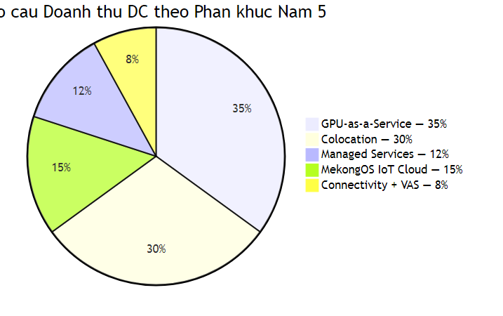

Diagram 6

| Phân khúc | Năm 1 (M USD) | Năm 3 (M USD) | Năm 5 (M USD) | Tỷ trọng Y5 |
| --- | --- | --- | --- | --- |
| Colocation (Standard) | 0,36 | 0,72 | 1,04 | 30% |
| GPU-as-a-Service | 0,29 | 0,69 | 1,21 | 35% |
| Managed Services | 0,22 | 0,36 | 0,41 | 12% |
| MekongOS IoT Cloud | 0,15 | 0,35 | 0,52 | 15% |
| Connectivity + VAS | 0,15 | 0,21 | 0,28 | 8% |
| **Tổng** | **1,17** | **2,33** | **3,46** | **100%** |

*[C — Tính toán từ mô hình doanh thu DC, Occupancy ramp: Y1 20-25% → Y3 50-60% → Y5 70-85%]*

### 1.5.6. Chiến lược GPU: Thuê trước, Mua sau (Hybrid)

Một trong những rủi ro lớn nhất của Datacenter là khấu hao GPU (chu kỳ công nghệ 2-3 năm, GPU mất 80-90% giá trị sau 4 năm). Mekong áp dụng chiến lược Hybrid:

| Giai đoạn | Phương án | CAPEX | OPEX/năm | Lý do |
| --- | --- | --- | --- | --- |
| Phase 1 (2028-2030) | **Thuê GPU (Lease)** | 0 | ~3,20 M | Giảm rủi ro obsolescence, linh hoạt scale |
| Phase 2 (2030+) | **Mua GPU (Buy)** | 5,60-7,50 M | ~0,50 M | Đã có revenue visibility, margin tốt hơn |

NPV so sánh 5 năm (WACC 12%):

- Kịch bản mua toàn bộ: NPV = -11,52 M USD [C]
- Kịch bản thuê toàn bộ: NPV = -10,43 M USD [C]
- **Kịch bản Hybrid (Thuê Phase 1, Mua Phase 2): NPV = -9,11 M USD** — Tối ưu nhất [C]

## 1.6. Định vị Cạnh tranh Tổng thể

### 1.6.1. Ma trận Định vị Chiến lược

**Ma trận Định vị Cạnh tranh** (Trục X: Phạm vi Hẹp → Rộng, Trục Y: Giá trị Thấp → Cao)

| Doanh nghiệp | Phạm vi | Giá trị | Góc phần tư |
| --- | --- | --- | --- |
| **Mekong Technology** | 0,75 | 0,80 | Dẫn đầu Thị trường |
| Viettel IDC | 0,60 | 0,70 | Dẫn đầu Thị trường |
| FPT DC | 0,55 | 0,60 | Dẫn đầu Thị trường |
| Geek+ Robot | 0,40 | 0,55 | Chuyên gia Niche |
| Cosmos CNC | 0,25 | 0,45 | Chuyên gia Niche |
| VPIC CNC | 0,30 | 0,40 | Cạnh tranh Giá |

### 1.6.2. Lợi thế Cạnh tranh Bền vững (MOAT)

| Lớp phòng thủ | Mô tả | Thời gian đối thủ cần để sao chép |
| --- | --- | --- |
| **Vị trí (KCNC)** | Lô đất 1 ha trong KCNC — vị trí chiến lược, tòa nhà 3 tầng GFA 21.000 m² | Không thể sao chép (hết đất) |
| **Chứng nhận (IATF + AS9100)** | 2-3 năm đạt chứng nhận, chi phí 350-530K USD | 3-4 năm |
| **Hệ sinh thái 3 B.U** | IoT + CNC + DC tích hợp trên cùng site | 4-5 năm + >100 M USD |
| **Quan hệ FDI** | Hợp đồng 3-5 năm với khách hàng CNC | 2-3 năm |
| **Tier III Certified** | 12-24 tháng đạt chứng nhận Uptime Institute | 2-3 năm |
| **MekongOS Platform** | Nền tảng IoT Cloud tự phát triển, IP riêng | 3-5 năm |

> **Tổng hợp:** Một đối thủ muốn sao chép hoàn toàn mô hình Mekong Technology (3 trụ cột + chứng nhận + vị trí KCNC) cần ít nhất **100 M USD và 5 năm** [A]. Đây là rào cản gia nhập (barrier-to-entry) cực kỳ cao, tạo lợi thế cạnh tranh bền vững trong trung và dài hạn.

## 1.7. Phân tích Chuỗi Giá trị (Value Chain Analysis)

### 1.7.1. Chuỗi Giá trị Ngành CNC Outsourcing

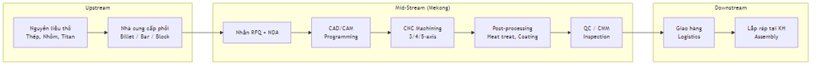

Diagram 7

| Phân khúc | % Giá trị | Ai nắm giữ | Mekong vị trí |
| --- | --- | --- | --- |
| **Nguyên liệu** | 15-25% | Nhà SX thép/nhôm toàn cầu | Mua qua trader (VN, JP, KR) |
| **Thiết kế (DfM)** | 10-15% | Khách hàng OEM | Tư vấn DfM — giá trị gia tăng |
| **Gia công CNC** | 35-45% | Nhà máy CNC | **Core value — Mekong nắm giữ** |
| **Xử lý bề mặt** | 5-10% | Chuyên gia plating/coating | Tự làm + outsource |
| **QC / Inspection** | 5-8% | Bên thứ 3 hoặc in-house | **In-house CMM (Zeiss)** |
| **Logistics** | 3-5% | Forwarding companies | DHL/Kuehne+Nagel |
| **Assembly** | 10-20% | OEM / EMS | Tiềm năng mở rộng (Phase 2+) |

**Giá trị Mekong nắm giữ: 40-55% chuỗi** → Mức tốt cho pure-play CNC outsourcer. Mở rộng sang DfM consulting và sub-assembly sẽ nâng lên 55-70% [A].

### 1.7.2. Chuỗi Giá trị Ngành Data Center

| Phân khúc | % Giá trị | Mekong vị trí | So sánh |
| --- | --- | --- | --- |
| **Đất + XD** | 25-35% | **Tự sở hữu (KCNC lease)** | Lợi thế vị trí |
| **Thiết bị MEP** | 20-30% | Mua + lắp đặt | Schneider/Vertiv |
| **Kết nối (Connectivity)** | 5-10% | Multi-carrier (VNPT, FPT, Viettel) | Carrier-neutral |
| **Managed services** | 15-25% | **Mekong NOC 24/7** | Upselling |
| **Cloud / SaaS** | 10-20% | Partner hosting (AWS/Azure outpost) | Hybrid strategy |

### 1.7.3. Chuỗi Giá trị Ngành IoT/Robot

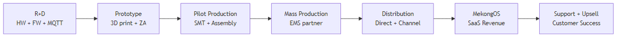

Diagram 8

| Phân khúc | % Giá trị ở giá trị sản phẩm | Chiến lược Mekong |
| --- | --- | --- |
| **R&D Hardware** | 15-20% | In-house (CNC rapid prototyping) |
| **R&D Software** | 20-30% | In-house (MekongOS platform) |
| **Production** | 15-25% | SMT in-house + EMS outsource volume |
| **Distribution** | 5-10% | System integrator channel + direct |
| **SaaS Revenue** | 20-35% | **High-margin recurring, scalable** |
| **Service / Support** | 5-10% | Managed service contracts |

> **Insight chiến lược:** IoT/Robot B.U giá trị cao nhất nằm ở R&D Software + SaaS (chiếm 40-65% tổng giá trị), không phải hardware. Đây là lý do Mekong đầu tư mạnh vào MekongOS (660K USD R&D). LTV/CAC ratio mục tiêu > 5:1 cho SaaS subscription.

## 1.8. Phân tích Khách hàng Mục tiêu (Customer Segmentation)

### 1.8.1. Segmentation — CNC Outsourcing

[output not shown]

**Chiến lược phân bổ Revenue Y5 (10,75M):**

| Tier | % Revenue | Revenue (K) | Số KH | Revenue/KH (K) |
| --- | --- | --- | --- | --- |
| Tier 1 — Aerospace | 5% | 537 | 1-2 | 268-537 |
| Tier 2 — Automotive | 30% | 3.225 | 5-8 | 403-645 |
| Tier 4 — Electronics/Semi | 25% | 2.688 | 3-5 | 538-896 |
| Tier 6 — General Industrial | 25% | 2.688 | 15-20 | 134-179 |
| Tier 3+5 — Medical/Energy | 15% | 1.613 | 3-5 | 323-538 |
| **Tổng** | **100%** | **10.750** | **~27-40** | **~269-398** |

### 1.8.2. Segmentation — Data Center

| Phân khúc | Khách hàng mẫu | Revenue/KH (K/năm) | Rack tiêu thụ | Ưu tiên |
| --- | --- | --- | --- | --- |
| **Enterprise** | VN banks, telcos, insurance | 200-500 | 20-50 | Cao |
| **Cloud / Hyperscaler Edge** | AWS, Azure, GCP (edge PoP) | 300-1.000 | 30-100 | Rất cao |
| **Gaming / CDN** | VNG, Akamai, Cloudflare | 50-200 | 5-20 | Trung bình |
| **Government** | Sở ban ngành TP.HCM | 100-300 | 10-30 | Trung bình (quan hệ) |
| **SMB CoLo** | VN startups, SME IT | 5-30 | 1-5 | Nhiều KH nhỏ |
| **Internal (IoT/CNC)** | Mekong Technology BU | 100-150 (transfer) | 10-15 | Guaranteed |

**Chiến lược lấp đầy:**

### 1.8.3. Segmentation — IoT/Robot

| Phân khúc | Sản phẩm phù hợp | Số lượng dự kiến Y5 | Revenue (K) | Mô hình |
| --- | --- | --- | --- | --- |
| **Smart Factory** | MK-200 (IoT Gateway) | 2.000-3.000 units | 700-1.350 | HW + SaaS |
| **Robot Logistics** | AMR-100 | 50-100 units | 1.500-3.000 | HW + maintenance |
| **Smart Building** | MK-300 (5G Hub) | 500-1.000 units | 350-700 | HW + platform |
| **Smart Agriculture** | MK-200 (customized) | 1.000-2.000 units | 350-900 | HW + SaaS |
| **Smart City** | MK-500 (Edge AI) | 200-500 units | 1.000-2.000 | Project-based |
| **MekongOS SaaS** | Platform subscription | 3.000-5.000 licenses | 600-1.200 | Pure SaaS |

## 1.9. Phân tích SWOT Chi tiết

### 1.9.1. SWOT Matrix

[output not shown]

### 1.9.2. Chiến lược TOWS (Cross-SWOT)

[output not shown]

## 1.10. Phân tích Porter’s Five Forces

### 1.10.1. Ngành CNC Outsourcing tại VN

| Lực lượng | Mức độ | Điểm (1-5) | Phân tích | Chiến lược đối phó |
| --- | --- | --- | --- | --- |
| **Rào cản gia nhập** | Trung bình-Cao | 3,5 | CAPEX 15-20M cho 5-axis CNC; chứng nhận 2-3 năm; nhưng 3-axis dễ gia nhập | Focus 5-axis + chứng nhận = barrier |
| **Quyền lực NCC** | Trung bình | 3,0 | DMG MORI, Mazak dominance; thép/nhôm commodity nhưng specialty alloy ít NCC | Multi-source + long-term contract |
| **Quyền lực KH** | Cao | 4,0 | FDI customers = sophisticated, quality-driven, multi-vendor; volume leverage | Sticky relationship + switching cost qua certification |
| **SP thay thế** | Thấp-Trung bình | 2,5 | 3D printing (metal AM) đang phát triển nhưng chậm; CNC vẫn dominant cho precision | Monitor AM; đầu tư hybrid CNC+AM khi mature |
| **Cạnh tranh nội bộ** | Cao | 4,0 | 200+ CNC shops in VN; nhưng chỉ <10 có 5-axis + intl certification | Differentiate bằng capability + certification |
| **Điểm TB** |  | **3,4** | Ngành hấp dẫn ở phân khúc cao cấp |  |

### 1.10.2. Ngành Data Center tại VN

| Lực lượng | Mức độ | Điểm (1-5) | Phân tích |
| --- | --- | --- | --- |
| **Rào cản gia nhập** | Cao | 4,5 | CAPEX 50-200M+ cho DC lớn; land scarcity; giấy phép phức tạp |
| **Quyền lực NCC** | Trung bình | 3,0 | Power (EVN monopoly); cooling (Schneider/Vertiv duopoly) |
| **Quyền lực KH** | Trung bình-Cao | 3,5 | Large enterprise + hyperscaler có leverage; nhưng switching cost cao |
| **SP thay thế** | Thấp | 2,0 | Cloud thay colo cho SMB, nhưng cloud cần DC → complementary |
| **Cạnh tranh nội bộ** | Trung bình | 3,0 | Top 5 chiếm 65-70%; market growing 18-22% → đủ chỗ cho entrant |
| **Điểm TB** |  | **3,2** | Ngành rất hấp dẫn, barrier cao bảo vệ incumbents |

### 1.10.3. Ngành IoT/Robot tại VN

| Lực lượng | Mức độ | Điểm (1-5) | Phân tích |
| --- | --- | --- | --- |
| **Rào cản gia nhập** | Thấp-Trung bình | 2,5 | R&D cost moderate; nhưng ecosystem (cloud + HW + channel) khó xây |
| **Quyền lực NCC** | Trung bình | 3,0 | Chip shortage risk (Qualcomm, NXP); PCB assembly available |
| **Quyền lực KH** | Trung bình | 3,0 | Fragmented market; customers chưa mature → education needed |
| **SP thay thế** | Trung bình | 3,0 | Import products từ TQ rẻ hơn; manual labor vẫn rẻ ở VN |
| **Cạnh tranh nội bộ** | Thấp-Trung bình | 2,5 | Ít player VN có full-stack capability (HW+FW+Cloud) |
| **Điểm TB** |  | **2,8** | Ngành mới, cơ hội lớn cho first-mover có platform play |

### 1.10.4. Tổng hợp Five Forces — 3 Ngành

[output not shown]

> **Chú giải:** Cột 1 = CNC (TB 3,4 — niche cao cấp, khả thi) | Cột 2 = DC (TB 3,2 — barrier cao, khả thi) | Cột 3 = IoT (TB 2,8 — first-mover win)

> **Kết luận 1.10:** Cả 3 ngành đều có cơ hội tốt khi Mekong định vị đúng phân khúc. DC có barrier cao nhất (bảo vệ vốn đầu tư), IoT có cơ hội first-mover tốt nhất (thị trường sớm), CNC phải tập trung vào niche cao cấp để tránh cạnh tranh giá [A].

## 1.11. Phân tích Quy mô Thị trường TAM/SAM/SOM Chi tiết

### 1.11.1. TAM/SAM/SOM — CNC Outsourcing

| Cấp độ | 2025 (M USD) | 2030 (M USD) | CAGR | Cách tính |
| --- | --- | --- | --- | --- |
| **TAM** (Global Precision Machining) | 320.000 | 450.000 | 7,0% | Grand View Research 2024 [B] |
| **SAM** (ASEAN CNC Outsourcing) | 8.500 | 14.200 | 10,8% | Mordor Intelligence [B] |
| **SOM** (VN Precision CNC export-grade) | 1.200 | 2.500 | 15,8% | Vietnam MoIT [B] + estimate |
| **Mekong Target Y5** |  | 10,75 |  | Revenue target |
| **Market Share Y5** |  | **0,43%** của SOM |  | = 10,75/2.500 |

### 1.11.2. TAM/SAM/SOM — Data Center

| Cấp độ | 2025 (M USD) | 2030 (M USD) | CAGR | Cách tính |
| --- | --- | --- | --- | --- |
| **TAM** (APAC DC Market) | 95.000 | 180.000 | 13,6% | Arizton Research [B] |
| **SAM** (VN DC Colocation + Managed) | 750 | 2.000 | 21,7% | Cushman & Wakefield [B] |
| **SOM** (HCM DC mid-tier colo) | 200 | 550 | 22,4% | Estimate based on HCM share ~27% [B] |
| **Mekong DC Revenue Y5** |  | ~3.600K = 3,60 |  | Revenue target (10Y: 36.060K) |
| **Market Share Y5** |  | **0,65%** của SOM |  | = 3,60/550 |

### 1.11.3. TAM/SAM/SOM — IoT/Robot

| Cấp độ | 2025 (M USD) | 2030 (M USD) | CAGR | Cách tính |
| --- | --- | --- | --- | --- |
| **TAM** (ASEAN IoT + Industrial Robot) | 15.000 | 35.000 | 18,5% | IoT Analytics + IFR [B] |
| **SAM** (VN Industrial IoT + AMR) | 800 | 2.500 | 25,6% | McKinsey VN report [B] |
| **SOM** (VN Smart Factory IoT devices) | 120 | 400 | 27,2% | Subsegment estimate [A] |
| **Mekong IoT Revenue Y5** |  | ~4,50 |  | Revenue target |
| **Market Share Y5** |  | **1,13%** của SOM |  | = 4,50/400 |

> **Kiểm chứng mục tiêu:** Tất cả 3 mục tiêu market share Y5 đều < 2% SOM — hoàn toàn khả thi và conservative. Ngay cả khi market growth chậm hơn dự kiến 30%, Mekong vẫn chỉ cần < 3% SOM. Đây là dấu hiệu tốt cho tính khả thi của dự án [C].

## 1.12. Dự báo Xu hướng Công nghệ 2025-2035

### 1.12.1. Technology Radar — Impact on Mekong

| Xu hướng | Timeframe | Impact | Cơ hội cho Mekong | Rủi ro cho Mekong |
| --- | --- | --- | --- | --- |
| **AI/ML trong sản xuất** | Now-2027 | Rất cao | Predictive maintenance, auto-CAM programming | Chi phí adoption |
| **Additive Manufacturing (Metal 3D)** | 2027-2030 | Cao | Hybrid CNC+AM service; rapid prototyping | Thay thế 10-15% CNC jobs |
| **5G Private Network** | 2026-2028 | Cao | MK-300 product opportunity; factory connectivity | Licensing cost |
| **Edge AI Computing** | Now-2028 | Cao | MK-500 product; edge DC service | Competition from hyperscaler |
| **Digital Twin** | 2027-2030 | Trung bình | CNC process optimization; DC capacity planning | Implementation cost |
| **Liquid Cooling (DC)** | Now-2027 | Cao | Energy efficiency; AI GPU cooling requirement | Retrofit existing DC design |
| **Autonomous Mobile Robot** | Now-2030 | Rất cao | AMR-100 core product; warehouse automation | Chinese competitor (Geek+, Hikrobot) |
| **Quantum Computing** | 2030-2035 | Thấp-TB | Post-quantum security for DC; long-term play | Distant; monitor only |
| **Green Hydrogen** | 2030-2035 | Trung bình | Backup power alternative to diesel gen | Infrastructure not ready VN |
| **Cobotic Manufacturing** | 2026-2030 | Cao | Human-robot collaboration in CNC cell | Training workforce |

### 1.12.2. R&D Investment Roadmap Response

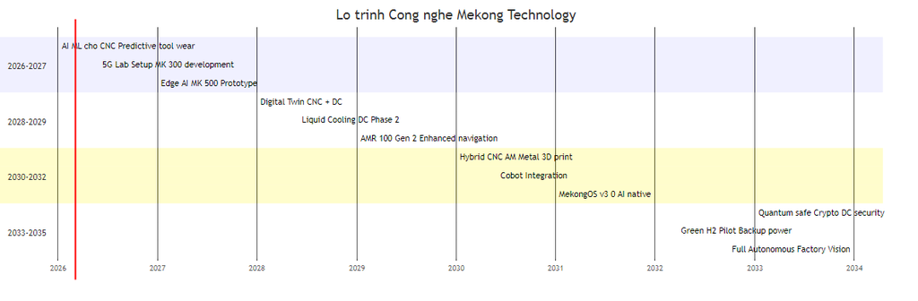

Diagram 9

| Giai đoạn | R&D Budget (K/năm) | % Revenue | Focus | Output KPIs |
| --- | --- | --- | --- | --- |
| Phase 1 (Y1-Y3) | 200-400 | 3-5% | Core products + certification | 5 patents, 3 products |
| Phase 2 (Y4-Y7) | 400-800 | 3-4% | Next-gen + AI integration | 10 patents, 5 products |
| Phase 3 (Y8-Y10) | 800-1.200 | 2-3% | Deep tech + platform scale | 20 patents cumulative |
| **Tổng 10 năm** | **~5.000-7.000** | **~3%** |  | 20+ patents, 10+ products |

# PHẦN II: SẢN PHẨM VÀ CÔNG NGHỆ

## 2.1. Tổng quan 3 Trụ cột Sản phẩm

Mekong Technology vận hành 3 trụ cột sản phẩm và dịch vụ công nghệ cao, tạo thành một hệ sinh thái tích hợp phục vụ đồng thời nhu cầu nội bộ và thị trường bên ngoài:

[output not shown]

### Bảng Sản phẩm Chi tiết — 10 Dòng sản phẩm

| TT | Sản phẩm / Dịch vụ | Trụ cột | Mô tả | Doanh thu ổn định (M USD/năm) | VA (%) |
| --- | --- | --- | --- | --- | --- |
| 1 | IoT Gateway MK-200 Standard | 1 | Vi xử lý ARM Cortex-A53, 4GB RAM, WiFi/BLE/4G, 25 I/O analog/digital, giao thức MQTT/OPC UA/Modbus, IP65 | 4,00 | 35% |
| 2 | IoT Gateway MK-300 AI Edge | 1 | ARM Cortex-A78 + NPU 6 TOPS, 8GB RAM, AI tại biên (Edge AI), camera AI tích hợp, 5G-ready | 6,00 | 38% |
| 3 | Robot AMR-500/1000 | 1 | Robot tự hành di động, LiDAR 3D 360 độ, AI SLAM navigation, tải 500-1.000 kg, tốc độ 1,5 m/s, tự sạc | 5,00 | 40% |
| 4 | Robot AGV-500/1000 | 1 | Robot dẫn hướng tự động, hệ thống vision + line following, tải 500-1.000 kg, độ chính xác ±5 mm | 4,00 | 35% |
| 5 | Robot OHT-100 | 1 | Hệ thống vận chuyển trên cao cho nhà máy bán dẫn, dual rail, 100 kg, 4 trục, Class 100 compatible | 2,50 | 30% |
| 6 | Linh kiện khuôn mẫu bán dẫn | 2 | Dung sai ≤ 3 micromet, Ra ≤ 0,2 micromet, vật liệu NAK80/SKD11/HPM38, xử lý nhiệt + mài bóng gương | 2,50 | 45% |
| 7 | Linh kiện hàng không vũ trụ | 2 | Chứng nhận AS9100 Rev D, vật liệu Titan Grade 5 (Ti-6Al-4V) / Inconel 718, gia công 5 trục đồng thời | 3,00 | 50% |
| 8 | Linh kiện ô tô điện | 2 | Chứng nhận IATF 16949, vật liệu Al 6061-T6 / SCM440, sản lượng lớn, SPC/MSA kiểm soát | 4,00 | 35% |
| 9 | Hạ tầng lưu trữ và AI/HPC Computing | 3 | Datacenter Tier III, 100 Rack (50 Colo 5-10 kW + 50 AI/HPC 15-30 kW), Uptime 99,982%, GPU H100 | 6,20 | 58% |
| 10 | MekongOS IoT Cloud (SaaS) | 3 | Nền tảng quản lý IoT, MQTT/OPC UA, Dashboard analytics, AI predictive maintenance, 2.000 thuê bao | 3,00 | 70% |
|  | **Tổng (steady-state, từ năm 7)** |  |  | **40,20** | **42%** |

## 2.2. Trụ cột 1 — Sản xuất IoT Gateway và Robot Tự hành

### 2.2.1. IoT Gateway — Dòng sản phẩm MK-200 và MK-300

#### Tổng quan Sản phẩm

IoT Gateway là thiết bị trung gian kết nối giữa các cảm biến/thiết bị tại nhà máy với hệ thống quản lý đám mây, đóng vai trò “bộ não biên” (Edge Brain) cho chuyển đổi số doanh nghiệp sản xuất.

| Thông số | MK-200 Standard | MK-300 AI Edge |
| --- | --- | --- |
| **Vi xử lý** | ARM Cortex-A53, 4 nhân, 1,8 GHz | ARM Cortex-A78, 8 nhân, 2,8 GHz + NPU 6 TOPS |
| **Bộ nhớ** | 4 GB LPDDR4 + 32 GB eMMC | 8 GB LPDDR5 + 64 GB eMMC + microSD |
| **Kết nối** | WiFi 6, BLE 5.2, 4G LTE, Ethernet 1Gbps, RS485/RS232 | WiFi 6E, BLE 5.3, 5G Sub-6, Ethernet 2.5Gbps, RS485/RS232/ CAN bus |
| **I/O** | 25 (12 DI, 8 DO, 3 AI, 2 AO) | 35 (16 DI, 10 DO, 5 AI, 4 AO) |
| **Giao thức** | MQTT, OPC UA, Modbus RTU/TCP, HTTP/REST | MQTT, OPC UA, Modbus, EtherCAT, PROFINET, HTTP, gRPC |
| **AI tại biên** | Không | Có — Vision AI (phát hiện lỗi, đếm sản phẩm), Predictive maintenance |
| **Camera** | Không | 1 camera 5MP AI tích hợp (tùy chọn) |
| **Bảo vệ** | IP65, chịu nhiệt -10°C đến 60°C | IP67, chịu nhiệt -20°C đến 70°C, chống rung IEC 60068 |
| **Nguồn** | 12-48V DC, 8W | 12-48V DC, 15W, PoE++ |
| **Kích thước** | 180 × 120 × 45 mm | 220 × 150 × 55 mm |
| **Bảo mật** | TLS 1.3, TPM 2.0 | TLS 1.3, TPM 2.0, Secure Boot, OTA encrypted |
| **Giá bán** | 800-1.200 USD | 1.500-2.500 USD |
| **Thị trường** | DNNVV, nhà máy cỡ vừa | Nhà máy FDI, bán dẫn, ô tô, logistics |

#### Xử lý và Sản xuất

Quy trình sản xuất IoT Gateway tại Khối C (SMT):

1. **Sản xuất PCB (in-house SMT):** Paste printing → SPI → Component placement → Reflow soldering → AOI → X-ray (BGA) → Manual rework
2. **Lắp ráp hệ thống:** PCB + Vỏ (CNC machined tại Khối B) + Antenna + Connector → Assembly
3. **Kiểm tra:** Functional test → EMC pre-compliance → Environmental stress screen → Final QC
4. **Firmware:** Flash firmware MekongOS Agent → Calibration → Pairing test → Packaging

Công suất sản xuất: 5.000 thiết bị/năm (MK-200: 3.000, MK-300: 2.000), hoạt động 1 ca [C].

#### Ứng dụng Tiêu biểu

| Ngành | Ứng dụng | Sản phẩm | Số lượng ước/KH/năm |
| --- | --- | --- | --- |
| Sản xuất điện tử | Giám sát OEE, SPC tự động | MK-300 | 10-20 |
| Kho vận, Logistics | Theo dõi hàng hóa, fleet management | MK-200 | 20-50 |
| Dệt may | Đo đếm sản phẩm, giám sát năng suất | MK-200 | 30-80 |
| Thực phẩm, Dược phẩm | Giám sát nhiệt độ/độ ẩm, HACCP | MK-200 | 10-30 |
| Bán dẫn | EES (Equipment Engineering System) integration | MK-300 | 5-10 |
| Ô tô | Andon, Poka-yoke tự động | MK-300 | 5-15 |

### 2.2.2. Robot AMR-500 và AMR-1000

#### Tổng quan Sản phẩm

Robot AMR (Autonomous Mobile Robot) là robot tự hành di động, sử dụng trí tuệ nhân tạo để tự xác định vị trí và di chuyển trong nhà máy mà KHÔNG cần dải từ, dây dẫn hay đánh dấu sàn — khác biệt hoàn toàn so với AGV truyền thống.

| Thông số | AMR-500 | AMR-1000 |
| --- | --- | --- |
| **Tải trọng** | 500 kg | 1.000 kg |
| **Navigation** | LiDAR 3D 360° + Camera AI + IMU + Odometry | LiDAR 3D 360° + Camera AI + IMU + UWB Anchor |
| **Thuật toán** | AI SLAM (Simultaneous Localization and Mapping) — huấn luyện trên GPU NVIDIA (Khối A) | AI SLAM + Deep reinforcement learning |
| **Tốc độ** | 0-1,5 m/s | 0-1,2 m/s |
| **Độ chính xác** | ±10 mm | ±10 mm |
| **Truyền thông** | WiFi 6 + BLE 5.2, REST API, ROS2 compatible | WiFi 6 + BLE 5.3 + 5G, REST API, ROS2 |
| **Pin** | LiFePO4 48V/60Ah, thời gian hoạt động 8 giờ | LiFePO4 48V/100Ah, thời gian hoạt động 6 giờ |
| **Sạc** | Tự động docking, sạc nhanh 1,5 giờ | Tự động docking, sạc nhanh 2 giờ |
| **An toàn** | LiDAR safety scanner (ISO 13849 PLd), Emergency stop, Bumper sensor | Dual LiDAR safety, ISO 13849 PLe, Emergency stop |
| **Phụ kiện** | Roller conveyor top module, Lifting module | Roller conveyor, Lifting module, Hook towing module |
| **Kích thước** | 800 × 600 × 350 mm (không tải) | 1.000 × 700 × 400 mm (không tải) |
| **Khối lượng bản thân** | 120 kg | 180 kg |
| **Giá bán** | 18.000-25.000 USD | 28.000-38.000 USD |

#### Quy trình Sản xuất Robot AMR

1. **Thiết kế cơ khí (CAD/CAM):** Thiết kế 3D trên SolidWorks/Siemens NX → Mô phỏng FEM → Xuất toolpath cho CNC
2. **Chế tạo khung (CNC tại Khối B):** Phay CNC khung nhôm 6061-T6, bệ gá sensor, tấm đáy → Anodizing → QC kích thước CMM
3. **Lắp ráp PCB điều khiển (SMT tại Khối C):** Board chính (ARM + Motor driver) → Board sensor → Board power management
4. **Lắp ráp tổng (Assembly Line tại Khối C):**
   - Khung + Motor + Bánh xe + Encoder
   - LiDAR + Camera + IMU + UWB (tùy phiên bản)
   - Pin LiFePO4 + BMS
   - PCB điều khiển + Wiring harness
   - Vỏ ngoài + Safety scanner
5. **Huấn luyện AI (GPU tại Khối A):** AI SLAM model → Sim-to-Real transfer → Field calibration
6. **Kiểm tra:** Accuracy test → Battery cycle test → EMC → Drop test → 72h burn-in → Acceptance test

> **Mối liên kết Hệ sinh thái:** Robot AMR là sản phẩm minh chứng rõ nhất cho giá trị tích hợp 3 trụ cột — Khung CNC từ Khối B, PCB SMT từ Khối C, AI training từ Khối A, và giám sát qua MekongOS từ Cloud.

### 2.2.3. Robot AGV-500 và AGV-1000

Robot AGV (Automated Guided Vehicle) là phiên bản dẫn đường tự động với chi phí thấp hơn AMR, phù hợp cho các tuyến vận chuyển cố định trong nhà máy:

| Thông số | AGV-500 | AGV-1000 |
| --- | --- | --- |
| **Tải trọng** | 500 kg | 1.000 kg |
| **Navigation** | Vision-based + Magnetic tape (backup) | Vision + LiDAR 2D + Magnetic tape |
| **Tốc độ** | 0-1,0 m/s | 0-0,8 m/s |
| **Độ chính xác** | ±5 mm (trên line) | ±5 mm |
| **Giá bán** | 12.000-18.000 USD | 20.000-28.000 USD |
| **Ưu điểm** | Chi phí thấp, dễ triển khai | Tải nặng, phù hợp heavy industry |

Công suất sản xuất Robot AGV: 100 bộ/năm (1 ca) [C].

### 2.2.4. Robot OHT-100

Robot OHT (Overhead Hoist Transport) là hệ thống vận chuyển trên cao chuyên dụng cho nhà máy bán dẫn, vận chuyển wafer cassette (FOUP) giữa các tool trong clean room:

| Thông số | OHT-100 |
| --- | --- |
| **Tải trọng** | 100 kg (2 FOUP) |
| **Rail** | Dual rail overhead (trần), chiều cao 2,5-4 m |
| **Trục** | 4 trục (X, Y, Z, Theta) |
| **Tốc độ** | X/Y: 0-2,0 m/s, Z: 0-0,3 m/s |
| **Độ chính xác** | ±0,5 mm (docking position) |
| **Clean room** | Class 100 compatible (ISO 5) |
| **Truyền thông** | SECS/GEM, EAP, WiFi, RFID |
| **Giá bán** | 45.000-65.000 USD |

### 2.2.5. MekongOS — Nền tảng IoT Cloud

MekongOS là nền tảng phần mềm IoT Cloud do Mekong Technology tự phát triển, chạy trên hạ tầng Datacenter nội bộ (Khối A), cung cấp dịch vụ SaaS cho khách hàng quản lý IoT và Robot:

**Kiến trúc Hệ thống:**

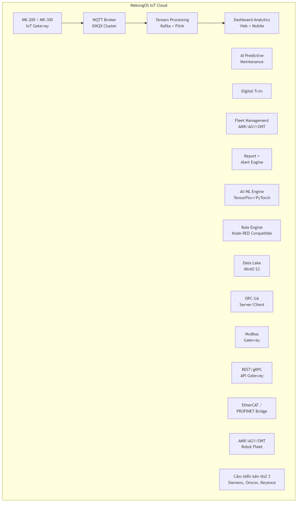

Diagram 10

**Mô hình Kinh doanh SaaS:**

| Gói dịch vụ | Mô tả | Giá/tháng | Thiết bị tối đa |
| --- | --- | --- | --- |
| Starter | Dashboard cơ bản, 5 widget, lưu trữ 30 ngày | 99 USD | 10 |
| Professional | Dashboard tùy chỉnh, AI alert, lưu trữ 90 ngày | 299 USD | 50 |
| Enterprise | Full AI, Digital Twin, API, lưu trữ 1 năm, SLA 99,9% | 999 USD | 500 |
| Custom | Theo yêu cầu, on-premise option | Thương lượng | Không giới hạn |

## 2.3. Trụ cột 2 — Chế tạo Cơ khí Siêu Chính xác (MPMC)

### 2.3.1. Tổng quan Năng lực Sản xuất

Trung tâm Chế tạo Linh kiện Siêu Chính xác (Mekong Precision Manufacturing Center — MPMC) là nhà máy CNC 5 trục đầu tiên của Việt Nam đặt mục tiêu đạt cùng lúc ba chứng nhận: ISO 9001, IATF 16949 (ô tô), và AS9100 Rev D (hàng không vũ trụ).

[output not shown]

### 2.3.2. Danh mục Máy móc Chi tiết

| TT | Máy | Hãng | Số lượng | Phase | Giá/máy (K USD) | Tổng (K USD) | Trọng lượng/máy |
| --- | --- | --- | --- | --- | --- | --- | --- |
| 1 | DMU 65 monoBLOCK | DMG MORI (Đức/Nhật) | 3 | 1 | 550-650 | 1.650-1.950 | 8.000 kg |
| 2 | DMU 80P duoBLOCK | DMG MORI | 2 | 2 | 750-850 | 1.500-1.700 | 12.000 kg |
| 3 | DVF 5000 | Doosan (Hàn Quốc) | 5 | 1 | 320-380 | 1.600-1.900 | 6.500 kg |
| 4 | DVF 5000 | Doosan | 5 | 2 | 320-380 | 1.600-1.900 | 6.500 kg |
| 5 | a51nx | Makino (Nhật Bản) | 4 | 1 | 300-360 | 1.200-1.440 | 5.000 kg |
| 6 | a61nx | Makino | 4 | 2 | 350-420 | 1.400-1.680 | 5.500 kg |
| 7 | Puma TL2000 (Tiện) | Doosan | 3 | 1 | 120-160 | 360-480 | 3.000 kg |
| 8 | MV2400R (Wire EDM) | Mitsubishi (Nhật) | 2 | 1+2 | 140-180 | 280-360 | 2.500 kg |
|  | **Tổng** |  | **28** |  |  | **9.590-11.410** |  |

### 2.3.3. Hệ thống QA/QC — Phòng Đo lường CMM

Phòng đo CMM (Coordinate Measuring Machine) là trái tim của hệ thống kiểm soát chất lượng CNC, đảm bảo mọi chi tiết gia công đều đạt dung sai yêu cầu:

| Thiết bị | Hãng | Số lượng | Giá (K USD) | Thông số |
| --- | --- | --- | --- | --- |
| CMM GLOBAL S 7.10.7 | Hexagon (Thụy Điển) | 1 | 180-250 | Phạm vi 700×1000×700 mm, độ chính xác 1,5+L/333 micromet |
| CMM PRISMO Ultra | Zeiss (Đức) | 1 | 200-280 | Phạm vi 900×1200×800 mm, dùng cho AS9100 audit |
| Máy quét Laser 3D MetraSCAN | Creaform (Canada) | 1 | 60-85 | Độ chính xác 30 micromet, scan 480.000 điểm/giây |
| Máy đo nhám bề mặt | Mitutoyo (Nhật) | 2 | 15-25 | Ra, Rz, Rt measurements |
| Kính hiển vi đo lường | Keyence (Nhật) | 1 | 35-50 | Phóng đại 20-500x, đo 2D/3D |
| Đồ gá kiểm tra (Fixtures) | Tùy chỉnh | 20 bộ | 40-60 | Theo yêu cầu khách hàng |
| **Tổng QA/QC** |  |  | **530-750** |  |

**Điều kiện Phòng CMM:**

- Nhiệt độ: 20°C ± 0,5°C (kiểm soát 24/7)
- Độ ẩm: 45-55%
- Rung: < 0,05 mm/s (nhỏ hơn 50 lần ngưỡng cho phép CNC)
- Sàn chống rungriêng biệt, tách khỏi xưởng CNC
- Vách kính trong suốt — cho phép khách hàng FDI quan sát quy trình đo (Visual Audit)
- Calibration định kỳ: Mỗi 6 tháng bởi đơn vị được công nhận (A2LA, DAkkS)

### 2.3.4. Phần mềm CAD/CAM/CAE

| Phần mềm | Hãng | Số license | Chi phí/năm (K USD) | Mục đích |
| --- | --- | --- | --- | --- |
| Siemens NX | Siemens | 5 | 45-65 | CAD/CAM chính, tương thích bản vẽ khách hàng FDI |
| Mastercam | CNC Software | 5 | 20-30 | CAM cho gia công 3 trục và phay phức tạp |
| VERICUT | CGTech | 2 | 15-22 | Mô phỏng và xác minh chương trình CNC (tránh va chạm) |
| ProShop ERP | ProShop | 1 | 12-18 | ERP chuyên cho xưởng CNC (job tracking, scheduling) |
| PC-DMIS | Hexagon | 2 | 10-15 | Lập trình và phân tích kết quả CMM |
| **Tổng phần mềm** |  |  | **102-150** |  |

### 2.3.5. Quy trình Gia công Tiêu biểu

**Quy trình cho linh kiện Titan hàng không — AS9100:**

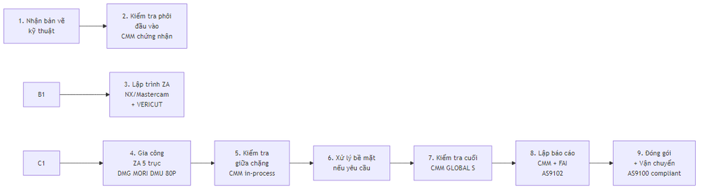

Diagram 11

**Thời gian chu kỳ (Lead time):**

- Linh kiện tiêu chuẩn (nhôm, thép): 2-3 tuần
- Linh kiện chính xác cao (IATF): 3-4 tuần
- Linh kiện Titan/Inconel (AS9100): 4-6 tuần
- Sản phẩm mới (NPI): 6-8 tuần (bao gồm thiết kế fixture + FAI)

### 2.3.6. Sản phẩm CNC theo Phân khúc

#### A. Phân khúc Bán dẫn (Semiconductor)

| Sản phẩm | Mô tả | Vật liệu | Dung sai | Số lượng/năm | Đơn giá (USD) |
| --- | --- | --- | --- | --- | --- |
| IC Mold Insert | Khuôn đúc IC, bề mặt gương Ra ≤ 0,1 µm | NAK80, HPM38 | ≤ 3 µm | 2.000 | 200-500 |
| Lead Frame Tooling | Dụng cụ dập lead frame | SKD11, ASP23 | ≤ 5 µm | 1.000 | 300-800 |
| Wafer Handling Parts | Chi tiết cho robot xử lý wafer | Al 6061-T6 | ≤ 5 µm | 1.500 | 150-400 |
| Test Socket | Đế test IC | Cu-Be, BeCu | ≤ 10 µm | 500 | 100-300 |

#### B. Phân khúc Hàng không Vũ trụ (Aerospace)

| Sản phẩm | Mô tả | Vật liệu | Dung sai | Số lượng/năm | Đơn giá (USD) |
| --- | --- | --- | --- | --- | --- |
| Turbine Blade Fixture | Đồ gá gia công cánh turbine | Inox 316L | ≤ 5 µm | 200 | 1.000-3.000 |
| Structural Bracket | Giá đỡ kết cấu máy bay | Titan Ti-6Al-4V | ≤ 10 µm | 500 | 500-2.000 |
| Hydraulic Manifold | Khối phân phối thủy lực | Inconel 718 | ≤ 8 µm | 300 | 2.000-5.000 |
| Engine Component | Chi tiết động cơ phụ | Titan / Inconel | ≤ 5 µm | 1.000 | 500-3.000 |

#### C. Phân khúc Ô tô Điện (EV Automotive)

| Sản phẩm | Mô tả | Vật liệu | Dung sai | Số lượng/năm | Đơn giá (USD) |
| --- | --- | --- | --- | --- | --- |
| EV Gearbox Housing | Vỏ hộp số ô tô điện | Al 6061-T6 | ≤ 15 µm | 5.000 | 80-200 |
| Battery Pack Frame | Khung pin EV | Al 5052 | ≤ 20 µm | 3.000 | 50-150 |
| Motor Shaft | Trục motor điện | SCM440, SUJ2 | ≤ 5 µm | 5.000 | 30-80 |
| Brake Caliper Body | Thân phanh | Al 7075-T6 | ≤ 10 µm | 3.000 | 60-180 |
| Steering Component | Chi tiết hệ lái | Thép hợp kim | ≤ 8 µm | 4.000 | 40-120 |

### 2.3.7. Doanh thu CNC theo Kịch bản

*(Dữ liệu chi tiết trong bảng bên dưới)*

| Năm | Conservative (M USD) | Base Case (M USD) | Optimistic (M USD) |
| --- | --- | --- | --- |
| 1 | 1,45 | 1,89 | 2,52 |
| 2 | 3,21 | 4,36 | 5,82 |
| 3 | 5,67 | 7,56 | 10,10 |
| 4 | 6,52 | 8,70 | 11,61 |
| 5 | 8,27 | 10,75 | 14,46 |
| **Tổng 5Y** | **25,12** | **33,26** | **44,51** |

*[C — Tính toán dựa trên utilization rate, product mix, và pricing model]*

## 2.4. Trụ cột 3 — Hạ tầng Điện toán Đám mây AI (MACC)

### 2.4.1. Tổng quan Kiến trúc Datacenter

Trung tâm Hạ tầng Điện toán Đám mây Mật độ cao (Mekong AI Cloud & Computing Center — MACC) được thiết kế theo tiêu chuẩn **Uptime Institute Tier III** — Concurrently Maintainable, đảm bảo uptime 99,982% (downtime tối đa 1,6 giờ/năm).

| Thông số | Giá trị |
| --- | --- |
| **Diện tích tổng** | 3.000 m² (Khối A) |
| **Data Hall** | 1.200 m² (Zone 1: 600 m², Zone 2: 600 m²) |
| **Tổng Rack** | 100 (Phase 1: 50, Phase 2: 50) |
| **Tải IT tổng** | 1,5-3,0 MW |
| **PUE mục tiêu** | < 1,35 (sau tối ưu hóa: 1,32) |
| **Cooling** | In-Row + Direct-to-Chip Liquid Cooling (Zone 2) |
| **UPS** | 4 × 1.000 kVA LiFePO4, 15 phút runtime |
| **Generator** | 2 × 2.500 kVA Diesel (N+1) |
| **Redundancy** | 2N Power, N+1 Cooling |
| **Tiêu chuẩn** | Uptime Tier III, ISO 27001, PCI DSS (target) |
| **Physical Security** | Mantrap, Biometric 3-factor, CCTV 24/7, Perimeter fence |

### 2.4.2. Phân vùng Data Hall

| Zone | Diện tích | Racks | Tải/Rack | Cooling | Mục đích | Khách hàng |
| --- | --- | --- | --- | --- | --- | --- |
| **Zone 1 — Colocation** | 600 m² | 50 | 5-10 kW | In-Row (chilled water) | Lưu trữ, hosting, DR | Ngân hàng, FDI, Enterprise |
| **Zone 2 — AI/HPC** | 600 m² | 50 | 15-30 kW | Direct-to-Chip Liquid + Rear-Door HEX | GPU Compute, AI training | AI startup, R&D, Bán dẫn |

### 2.4.3. Hệ thống Làm mát

Thiết kế cooling là yếu tố quyết định PUE và chi phí vận hành DC:

**Zone 1 (Colocation) — In-Row Cooling:**

- Chilled water loop: Chiller plant → CRAH (Computer Room Air Handler) → Data Hall → Return
- Hot Aisle Containment (HAC): Ngăn hành lang nóng, tối ưu nhiệt độ
- Set point: Cold aisle 22-24°C
- Redundancy: N+1 CRAH per zone

**Zone 2 (AI/HPC) — Hybrid Cooling:**

- Direct-to-Chip Liquid Cooling (Coolant Distribution Unit — CDU): Nước lạnh trực tiếp đến tấm tản nhiệt trên GPU
- Rear-Door Heat Exchanger: Tản nhiệt phụ cho phần không thể liquid cool
- Cooling tower: Evaporative (make-up water 60-80 m³/ngày sau hybrid)
- Free cooling economizer: Khi nhiệt độ ngoài trời < 24°C (~30% thời gian tại TP.HCM)

**Tính toán PUE:**

| Thành phần | Công suất | Ghi chú |
| --- | --- | --- |
| IT Load (rated) | 2.500 kW | 100 Rack × average 25 kW |
| Cooling overhead | 475 kW | 19% IT Load (nhờ liquid cooling) |
| UPS loss | 75 kW | 3% IT Load (LiFePO4 efficiency 97%) |
| Lighting + Security | 25 kW | 1% IT Load |
| Distribution loss | 50 kW | 2% IT Load |
| **Facility Total** | **3.125 kW** |  |
| **PUE = 3.125 / 2.500** | **1,25** | Target [C] |

> Thực tế PUE dao động 1,25-1,45 tùy mùa và tải. PUE trung bình năm mục tiêu: **1,32** (tốt hơn mức trung bình VN là 1,55 và tương đương DC Tier III tiên tiến ở Singapore) [C].

### 2.4.4. Dịch vụ Chi tiết

#### A. Colocation (Cho thuê chỗ đặt máy chủ)

| Gói dịch vụ | Tải/Rack | Giá/Rack/tháng | Hợp đồng | Phí lắp đặt ban đầu |
| --- | --- | --- | --- | --- |
| Standard | 5 kW | 900 USD | 1 năm | 3.000 USD |
| Standard Plus | 8 kW | 1.100 USD | 1 năm | 5.000 USD |
| High-Density | 15 kW | 2.500 USD | 3 năm | 8.000 USD |
| AI/HPC | 30 kW | 4.500 USD | 3-5 năm | 15.000 USD |

#### B. GPU-as-a-Service

| GPU | Giá/giờ | Giá/tháng (reserved) | RAM | Ứng dụng |
| --- | --- | --- | --- | --- |
| NVIDIA A100 80GB | 3,00-4,00 USD | 2.000-2.800 USD | 80 GB HBM2e | AI inference, Fine-tuning |
| NVIDIA H100 SXM5 | 5,00-7,00 USD | 3.500-5.000 USD | 80 GB HBM3 | LLM training, HPC |
| 8x H100 DGX Pod | — | 28.000-40.000 USD | 640 GB | Large-scale AI training |

#### C. MekongOS IoT Cloud (SaaS)

Chi tiết tại Mục 2.2.5.

#### D. Dịch vụ Kết nối và Bảo mật

| Dịch vụ | Giá/tháng | Mô tả |
| --- | --- | --- |
| Cross-connect 1Gbps | 200 USD | Kết nối giữa các rack |
| Internet Transit 1Gbps | 500 USD | Băng thông Internet dedicated |
| Dark Fiber (KCNC) | 300 USD | Kết nối quang riêng đến DN trong KCNC |
| SOC Monitoring (24/7) | 800 USD | Giám sát an ninh mạng |
| Managed Firewall | 400 USD | Tường lửa quản lý |
| Backup-as-a-Service | 200 USD/TB | Sao lưu dữ liệu |

### 2.4.5. Lộ trình Occupancy

| Năm | Racks sử dụng | Occupancy | Doanh thu (M USD) |
| --- | --- | --- | --- |
| 1 | 20-25 | 20-25% | 1,17-1,45 |
| 2 | 35-45 | 35-45% | 1,85-2,33 |
| 3 | 50-60 | 50-60% | 2,33-2,80 |
| 4 | 60-75 | 60-75% | 2,80-3,15 |
| 5 | 70-85 | 70-85% | 3,15-3,46 |

## 2.5. Hệ sinh thái Tích hợp 3 Trụ cột

### 2.5.1. Ma trận Liên kết Giá trị

| Từ → Đến | IoT/Robot (Khối C) | CNC/MPMC (Khối B) | DC/MACC (Khối A) |
| --- | --- | --- | --- |
| **IoT/Robot** | — | Bản vẽ CNC cho khung Robot | Dữ liệu IoT → Cloud Analytics |
| **CNC/MPMC** | Khung, vỏ, trục robot AMR | — | Gia công heat sink, rack mount |
| **DC/MACC** | GPU cho AI SLAM training | IoT giám sát hiệu suất CNC | — |

### 2.5.2. Lượng hóa Giá trị Cộng hưởng

[output not shown]

## 2.6. Lộ trình Trưởng thành Công nghệ

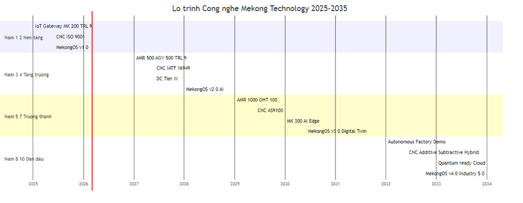

Diagram 12

## 2.7. Hoạt động Nghiên cứu và Phát triển (R&D)

### 2.7.1. Ngân sách R&D

| Năm | Doanh thu (M USD) | R&D (M USD) | Tỷ lệ R&D/DT |
| --- | --- | --- | --- |
| 1 | 4,50 | 0,45 | 10% |
| 2 | 7,00 | 0,70 | 10% |
| 3 | 11,50 | 1,15 | 10% |
| 4 | 14,00 | 1,12 | 8% |
| 5 | 16,00 | 1,28 | 8% |
| **Tổng 5 năm** |  | **4,70** | **~9%** |
| **Tổng 10 năm** |  | **~12,50** | **~8%** |

*[C — Cam kết tỷ lệ R&D ≥ 5%, mục tiêu nội bộ 8-12%]*

### 2.7.2. Phòng Thí nghiệm R&D

Mekong Technology xây dựng 5 phòng thí nghiệm chuyên dụng:

| TT | Phòng Lab | Diện tích | Chức năng | Đầu tư (K USD) |
| --- | --- | --- | --- | --- |
| 1 | Lab Phần cứng IoT | 150 m² | Thiết kế PCB, prototyping, EMC pre-compliance | 250 |
| 2 | Lab AI & Robotics | 200 m² | Phát triển AI SLAM, Computer Vision, ROS2 | 350 |
| 3 | Lab Vật liệu CNC | 80 m² | Phân tích cấu trúc kim loại, metallography | 180 |
| 4 | Lab Đo lường Chính xác (CMM Room) | 120 m² | CMM, Laser scan, QC R&D | (thuộc Khối B) |
| 5 | Lab Cloud & Cybersecurity | 50 m² | Dev/Test MekongOS, Pen testing, Security audit | 120 |
|  | **Tổng** | **600 m²** |  | **900** |

### 2.7.3. Hợp tác Chuyển giao Công nghệ (CGCN)

| Đối tác | Quốc gia | Lĩnh vực | Nội dung hợp tác |
| --- | --- | --- | --- |
| DMG MORI Academy | Nhật Bản/Đức | CNC | Đào tạo vận hành 5 trục, tối ưu toolpath |
| Hexagon Manufacturing Intelligence | Thụy Điển | QA/QC | Đào tạo CMM programming, GD&T |
| NVIDIA Deep Learning Institute | Mỹ | AI/GPU | Certified AI Developer program |
| Uptime Institute | Mỹ | Datacenter | Tier III Design & Operations certification |
| Đại học Bách Khoa TP.HCM | Việt Nam | R&D | Hợp tác nghiên cứu Robot + AI |
| Đại học Quốc gia TP.HCM | Việt Nam | R&D | Hợp tác đào tạo kỹ sư IC Design |

### 2.7.4. Sở hữu Trí tuệ

| Loại | Mục tiêu 5 năm | Mục tiêu 10 năm | Chi tiết |
| --- | --- | --- | --- |
| Bằng sáng chế | 8-10 | 20-25 | IoT Gateway architecture, AI SLAM algorithm, CNC process |
| Nhãn hiệu | 5 | 8 | MekongOS, MPMC, MACC, MK-200, MK-300 |
| Bản quyền phần mềm | 3 | 6 | MekongOS Platform, Fleet Manager, CNC Monitor |
| Bí mật kinh doanh | Liên tục | — | CNC process parameters, AI models, customer data |

*[A — Mục tiêu dựa trên benchmark doanh nghiệp CNC tương đương tại KCNC]*

## 2.8. Chi tiết Kỹ thuật CNC 5-Axis Machining Center

### 2.8.1. Danh sách Máy CNC — Phase 1 (28 máy)

| # | Model | Xuất xứ | Loại | Hành trình XYZ (mm) | Trục quay | Công suất (kW) | Tốc độ (rpm) | Đơn giá (K) | SL | **Thành tiền (K)** |
| --- | --- | --- | --- | --- | --- | --- | --- | --- | --- | --- |
| 1 | **DMG MORI DMU 80 eVo** | JP/DE | 5-axis | 800×650×550 | B+C | 35 | 18.000 | 450 | 5 | **2.250** |
| 2 | **DMG MORI NLX 2500/700** | JP | CNC Lathe | Ø366×705 | C | 26 | 4.000 | 280 | 4 | **1.120** |
| 3 | **Mazak VCN-530C** | JP | VMC 3-axis | 1.050×530×510 | — | 30 | 12.000 | 180 | 6 | **1.080** |
| 4 | **Mazak INTEGREX i-200S** | JP | Multi-tasking | Ø660×1.519 | B+C | 30 | 5.000 | 380 | 3 | **1.140** |
| 5 | **Sodick ALC600G** | JP | Wire EDM | 600×400×350 | — | 5 | — | 120 | 2 | **240** |
| 6 | **Okuma MB-56VA** | JP | VMC 3-axis | 1.300×560×460 | — | 22 | 8.000 | 150 | 4 | **600** |
| 7 | **Haas UMC-750** | US | 5-axis | 762×508×508 | A+C | 22 | 12.000 | 200 | 2 | **400** |
| 8 | **Tsugami B0205G-III** | JP | Swiss Lathe | Ø20 | 8-axis | 5 | 10.000 | 85 | 2 | **170** |
|  |  |  |  |  |  |  |  |  | **28** | **7.000** |

### 2.8.2. Thiết bị QC / Đo lường

| # | Thiết bị | Model | Hãng | Kích thước đo | Độ chính xác | Đơn giá (K) | SL | **Thành tiền (K)** |
| --- | --- | --- | --- | --- | --- | --- | --- | --- |
| 1 | CMM | CONTURA G2 | Zeiss (DE) | 900×1.200×800 mm | ±1.8 μm | 250 | 1 | **250** |
| 2 | Vision System | QV302 | Mitutoyo (JP) | 300×200 mm | ±3 μm | 120 | 1 | **120** |
| 3 | Surface Roughness | Surftest SJ-410 | Mitutoyo | — | Ra 0,001 μm | 8 | 2 | **16** |
| 4 | Hardness Tester | HV-120D | Shimadzu (JP) | — | HV ±2% | 6 | 1 | **6** |
| 5 | Height Gauge | QM-Height 600 | Mitutoyo | 600 mm | ±2 μm | 12 | 2 | **24** |
| 6 | Laser Scanner | HandySCAN 3D | Creaform (CA) | 0.3m range | ±0.025 mm | 45 | 1 | **45** |
| 7 | Microscope | Stemi 508 | Zeiss | 6.3:1-50:1 zoom | Optical | 5 | 2 | **10** |
| 8 | Profile Projector | PJ-H30 | Mitutoyo | 300 mm screen | ±0.01 mm | 18 | 1 | **18** |
|  |  |  |  |  |  |  |  | **489** |

**Tổng CNC Machines + QC: 7.000 + 489 = 7.489K** *[C — Đối chiếu với PHỤ LỤC Q.2: CAPEX CNC Phase 1 = 14.690K bao gồm M&E + infrastructure]*

### 2.8.3. Process Capability Matrix

| Quá trình | Tolerance đạt được | Ra (μm) | Vật liệu chính | Typical Parts |
| --- | --- | --- | --- | --- |
| **5-Axis Milling** | ±0,005 mm | 0,4-0,8 | Ti-6Al-4V, Inconel 718, Al 7075 | Aerospace bracket, medical implant |
| **3-Axis Milling** | ±0,01 mm | 0,8-1,6 | SS304/316, Al 6061, Brass | Automotive housing, heatsink |
| **CNC Turning** | ±0,005 mm | 0,4-0,8 | SS303, Al 2024, Monel | Shaft, bushing, connector |
| **Multi-task (Mill-Turn)** | ±0,008 mm | 0,8-1,2 | Titanium, Hastelloy | Complex valve body, manifold |
| **Wire EDM** | ±0,003 mm | 0,2-0,4 | D2 Steel, Carbide, Tungsten | Die, punch, micro parts |
| **Swiss Turning** | ±0,003 mm | 0,2-0,4 | SS316L, Brass, Titanium | Micro screw, pin, medical component |

### 2.8.4. Công suất Sản xuất Dự kiến

| Chỉ tiêu | Y1 | Y2 | Y3 | Y5 | Y10 |
| --- | --- | --- | --- | --- | --- |
| **Số máy hoạt động** | 15 | 20 | 24 | 28 | 35+ |
| **Ca sản xuất** | 2 ca (16h) | 2 ca | 3 ca (24h) | 3 ca | 3 ca + auto |
| **Utilization target** | 50% | 65% | 75% | 85% | 90% |
| **Machine hours/năm** | 43.800 | 75.920 | 131.400 | 171.360 | 229.950 |
| **MHR (USD)** | 45-85 | 45-85 | 50-90 | 55-95 | 55-95 |
| **Revenue potential (K)** | 2.628-3.723 | 4.556-6.453 | 7.884-11.826 | 11.338-16.279 | 15.197-21.845 |
| **Revenue target (K)** | 2.500 | 4.500 | 7.500 | 10.750 | ~15.000 |
| **% Capacity utilized** | 67-95% | 70-99% | 63-95% | 66-95% | 69-99% |

## 2.9. Chi tiết Thiết kế Data Center — Tier III

### 2.9.1. Thông số Tier III Design

| Thông số | Giá trị | Tiêu chuẩn | Ghi chú |
| --- | --- | --- | --- |
| **Uptime Target** | 99,982% | Uptime Institute Tier III | Max 1,6h downtime/năm |
| **Redundancy** | N+1 (all MEP components) | ANSI/TIA-942 | Active-active preferred |
| **Power Architecture** | 2N power path (main) | Tier III | A+B feeds to each rack |
| **Cooling** | N+1 chiller + DX backup | ASHRAE TC 9.9 | Hot/Cold aisle containment |
| **Fire Suppression** | NOVEC 1230 + VESDA | NFPA 75, NFPA 2001 | Pre-action in server room |
| **Physical Security** | 5-layer access control | ISO 27001 | Biometric + mantrap |
| **Monitoring** | DCIM + BMS 24/7 |  | >10.000 sensor points |
| **Connectivity** | Carrier-neutral, 3+ ISPs |  | VNPT, FPT, Viettel, CMC |

### 2.9.2. Power Design Layout

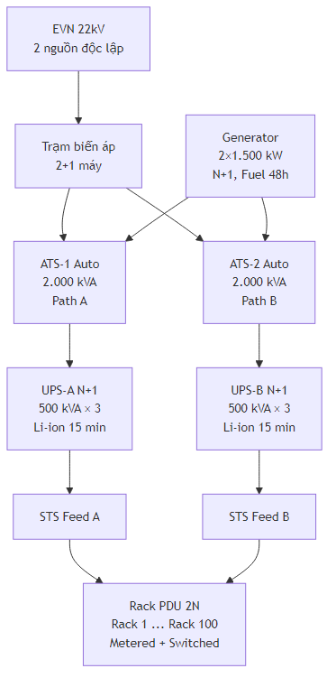

Diagram 13

| Component | Specification | Qty | Unit Cost (K) | **Total (K)** |
| --- | --- | --- | --- | --- |
| Transformer 22kV/0.4kV | 2.000 kVA, oil-type | 3 (2+1) | 80 | **240** |
| ATS | 2.000A, 4-pole | 2 | 25 | **50** |
| UPS (Li-ion) | 500 kVA modular | 6 (3+3, N+1 each) | 120 | **720** |
| Diesel Generator | 1.500 kW, Cummins | 2 (N+1) | 350 | **700** |
| Fuel Tank | 48h autonomy, 20.000L | 2 | 15 | **30** |
| PDU | Intelligent metered, 32A | 200 (2/rack) | 3 | **600** |
| Busway | 3.200A copper | 300m | 0,5/m | **150** |
| Panel boards + CBs |  | Lot |  | **200** |
| **Tổng Power** |  |  |  | **2.690** |

### 2.9.3. Cooling Design

| Component | Specification | Qty | Unit Cost (K) | **Total (K)** |
| --- | --- | --- | --- | --- |
| Chiller (air-cooled) | 500 RT, variable speed | 3 (N+1) | 180 | **540** |
| CRAH Unit | 100 kW, EC fan | 12 | 25 | **300** |
| In-Row Cooling | 30 kW (high-density area) | 8 | 18 | **144** |
| Piping + Pump | Primary + Secondary loop | Lot |  | **150** |
| Chilled water tank | 50 m³ buffer | 1 | 20 | **20** |
| Hot/Cold aisle containment | Panels + doors | 8 aisles | 15 | **120** |
| **Tổng Cooling** |  |  |  | **1.274** |
| **PUE Design** | **1,32 (P1), target 1,26 (P2)** |  |  |  |

### 2.9.4. Rack Layout — Hall Plan

[figure not shown]

Diagram 14

## 2.10. Chi tiết Thiết kế IoT Products

### 2.10.1. MK-200 IoT Gateway — Block Diagram

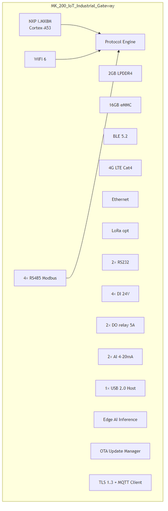

Diagram 15

> Power: 12-48V DC (industrial) | -20°C to +70°C | IP54 | Size: 160×100×45 mm | DIN rail mount | CE/FCC certified

### 2.10.2. AMR-100 Autonomous Mobile Robot — Specifications

| Thông số | Giá trị | Ghi chú |
| --- | --- | --- |
| **Tải trọng** | 100 kg (standard), 200 kg (option) | Đúng tên: AMR-100 |
| **Tốc độ** | 0-2,0 m/s | Adjustable |
| **Thời gian hoạt động** | 8-10 giờ (100 kg load) | LiFePO4 51,2V / 60Ah |
| **Thời gian sạc** | 2 giờ (auto-dock) | Wireless charging option |
| **Navigation** | SLAM (LiDAR + Camera fusion) | AI-based path planning |
| **Obstacle avoidance** | 360° LiDAR + 8 ultrasonic | 0,05m precision |
| **Communication** | WiFi 6 + 5G (option) | MekongOS Fleet Manager |
| **Localization accuracy** | ±30 mm | In mapped environment |
| **Map area** | Up to 50.000 m² | Multi-floor support |
| **Dimensions** | 800×600×350 mm | Compact for narrow aisle |
| **Weight** | 85 kg (no payload) |  |
| **Safety** | ISO 3691-4, CE, UL | Emergency stop + safety bumper |
| **Operating temp** | 0-45°C | Indoor use |
| **IP Rating** | IP42 | Indoor warehouse |
| **COGS** | 16.000 USD | [C — PHỤ LỤC T] |
| **ASP** | 30.000 USD | Margin: 46,7% [C] |

### 2.10.3. MekongOS Platform Architecture

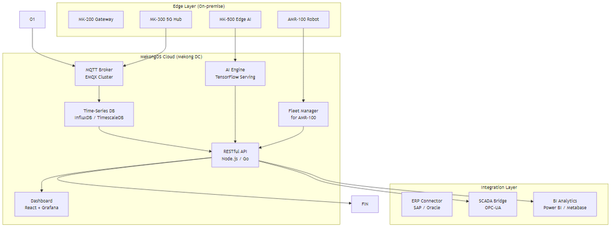

Diagram 16

| Module | Tech Stack | Dev Effort (man-month) | Cost (K) |
| --- | --- | --- | --- |
| Device Management | EMQX + custom agent | 6 | 60 |
| Data Pipeline | Kafka + InfluxDB | 8 | 80 |
| API Gateway | Kong + custom Go API | 4 | 40 |
| Dashboard | React + Grafana + custom | 10 | 100 |
| AI Engine | Python + TensorFlow + MLflow | 12 | 120 |
| Fleet Manager | Go + Redis + PathPlanner | 10 | 100 |
| Mobile App | React Native | 6 | 60 |
| Security Layer | Vault + cert manager | 4 | 40 |
| OTA System | Custom (delta updates) | 6 | 60 |
| **Tổng MekongOS** |  | **66** | **660** |

*[C — Đối chiếu: MekongOS R&D 660K = PHỤ LỤC T.5 = 66 man-months]*

# PHẦN III: MÔ HÌNH KINH DOANH

## 3.1. Tổng quan Mô hình Doanh thu

Mekong Technology vận hành mô hình doanh thu đa dạng từ 3 trụ cột, với 12 nguồn doanh thu (revenue streams) phân loại thành 4 nhóm:

### Nhóm 1: Doanh thu Sản phẩm (Product Revenue)

| # | Nguồn | Trụ cột | Mô hình | Tỷ trọng Y5 |
| --- | --- | --- | --- | --- |
| 1 | Bán IoT Gateway | 1 | Bán đứt + Bảo hành 1 năm | 18% |
| 2 | Bán Robot AMR/AGV/OHT | 1 | Bán đứt + Hợp đồng bảo trì | 20% |
| 3 | Gia công CNC B2B | 2 | Hợp đồng cung ứng 1-5 năm | 25% |

### Nhóm 2: Doanh thu Dịch vụ Định kỳ (Recurring Revenue)

| # | Nguồn | Trụ cột | Mô hình | Tỷ trọng Y5 |
| --- | --- | --- | --- | --- |
| 4 | MekongOS SaaS | 1+3 | Thuê bao tháng/năm | 8% |
| 5 | Colocation DC | 3 | Hợp đồng 1-5 năm | 7% |
| 6 | GPU-as-a-Service | 3 | Thanh toán theo giờ/tháng | 9% |
| 7 | Managed Services DC | 3 | Retainer hàng tháng | 3% |

### Nhóm 3: Doanh thu Kết nối (Connectivity Revenue)

| # | Nguồn | Trụ cột | Mô hình | Tỷ trọng Y5 |
| --- | --- | --- | --- | --- |
| 8 | Internet Transit / Dark Fiber | 3 | Băng thông tháng | 2% |
| 9 | Cross-connect | 3 | Liên kết rack-to-rack | 1% |

### Nhóm 4: Doanh thu Giá trị gia tăng (VAS Revenue)

| # | Nguồn | Trụ cột | Mô hình | Tỷ trọng Y5 |
| --- | --- | --- | --- | --- |
| 10 | SOC/Cybersecurity | 3 | Giám sát 24/7 | 2% |
| 11 | Bảo trì Robot (AMR/AGV) | 1 | Hợp đồng bảo trì hàng năm | 3% |
| 12 | Đào tạo CNC | 2 | Khóa đào tạo cho đối tác | 2% |

### Cơ cấu Doanh thu theo Năm

**Biểu đồ: Cơ cấu Doanh thu 10 năm theo Trụ cột (M USD)**

*(Dữ liệu chi tiết trong bảng bên dưới)*

[output not shown]

> **Lưu ý:** Bảng trên dùng doanh thu steady-state forecast (từ mô hình 00_PHUONG_AN ban đầu). Trong mô hình tài chính V2.1 chính thức (Phần V), doanh thu 15 năm Base Case ~165 M USD, với Y0-Y4 = 0 (giai đoạn xây dựng), Y6 = 2,50 M (IoT khai trương), Y10 = 14,50 M, Y15 = 32,00 M — khác biệt do áp dụng lộ trình 5 giai đoạn và ramp-up tuần tự [C].

## 3.2. Khách hàng Mục tiêu và Chiến lược Tiếp cận

### 3.2.1. Phân loại Khách hàng

| Nhóm | Mô tả | Quy mô | Trụ cột phục vụ | Chiến lược |
| --- | --- | --- | --- | --- |
| **FDI Top-tier** | Samsung, Intel, Bosch, VinFast | 5-10 KH | CNC + IoT | Account-Based Marketing, Đội sales chuyên biệt |
| **FDI Mid-tier** | Nidec, Jabil, Canon, Renesas | 10-20 KH | CNC + IoT + DC | Trade show + Giới thiệu từ FDI Top |
| **VN Enterprise** | VNPT, FPT, VNG, Techcombank | 20-50 KH | DC + IoT | Digital marketing + Partner channel |
| **KCNC Ecosystem** | DN trong KCNC HCM | 50-100 KH | DC + IoT Cloud | On-site demo + Ưu đãi proximity |
| **DNNVV** | Sản xuất nhỏ và vừa | 500-2.000 KH | IoT SaaS | Online sales + Channel partner |

### 3.2.2. Chiến lược Bán hàng theo Trụ cột

**CNC — B2B Direct Sales:**

- Thời gian closing: 3-12 tháng (đặc thù gia công B2B)
- Quy trình: First Article Inspection (FAI) → Trial order (10-50 chi tiết) → Volume order → Annual contract
- Payment terms: Net 30-60 ngày (chuẩn FDI)
- Key Performance: ≥ 3 LOI được ký trước khi vận hành, Doanh thu ≥ 0,22 M năm 1

**DC — Pre-Lease + Enterprise Sales:**

- Thời gian closing: 6-18 tháng (DC contract lớn)
- Quy trình: LOI từ Q1/2028 → Soft launch Q2/2028 → Grand open Q3/2028
- Contract structure: 1 năm (Standard), 3 năm (High-Density), 5 năm (AI/HPC)
- Upfront: 3.000-15.000 USD installation fee

**IoT — Multi-Channel:**

- Kênh trực tiếp: Đội sales 10-15 người (Key Account + Regional)
- Kênh gián tiếp: 5-10 đại lý (System Integrators, VAR)
- Kênh online: Website, MekongOS trial, Webinar
- Closing time: 1-6 tháng

## 3.3. Chiến lược Phát triển Ba Giai đoạn

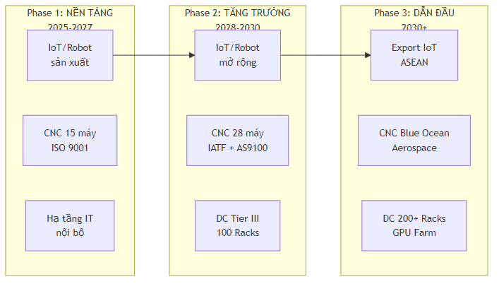

Diagram 17

| Giai đoạn | Thời gian | CAPEX | Mục tiêu chiến lược | Revenue target |
| --- | --- | --- | --- | --- |
| **Phase 1: Nền tảng** | 2025-2027 | 28,90 M | Xây dựng hạ tầng, CNC cơ bản, IoT sản xuất, hạ tầng IT nội bộ | 4-10 M/năm |
| **Phase 2: Tăng trưởng** | 2028-2030 | 18,60 M | DC thương mại, CNC mở rộng + chứng nhận, IoT scale-up | 10-22 M/năm |
| **Phase 3: Dẫn đầu** | 2030+ | Tái đầu tư | Xuất khẩu ASEAN, CNC Aerospace, DC mở rộng 200+ Racks | >30 M/năm |

## 3.4. Kênh Phân phối và Đối tác Chiến lược

### 3.4.1. Đối tác Chiến lược

| Đối tác | Loại hình | Lĩnh vực | Giá trị hợp tác |
| --- | --- | --- | --- |
| DMG MORI Vietnam | Nhà cung cấp | CNC | Mua máy + Đào tạo + Bảo trì |
| NVIDIA | Nhà cung cấp | GPU | DGX Partner + Deep Learning Cert |
| Schneider Electric | Nhà cung cấp | Hạ tầng DC | UPS + PDU + Cooling + DCIM |
| Siemens | Nhà cung cấp | Phần mềm | NX CAD/CAM + MindSphere IoT |
| FPT Telecom | Đối tác | Kết nối | Dark fiber KCNC + Internet transit |
| Hexagon Manufacturing Intelligence | Nhà cung cấp | QA/QC | CMM + Phần mềm + Đào tạo |
| JETRO Vietnam | Hỗ trợ | B2B Match | Kết nối nhà sản xuất Nhật cần CNC |
| KOTRA Vietnam | Hỗ trợ | B2B Match | Kết nối nhà sản xuất Hàn cần CNC |
| Bộ KH&CN / NATEC | Chính phủ | R&D Grant | Hỗ trợ đề tài R&D + Trợ cấp |

### 3.4.2. Mô hình Kinh doanh Canvas (Business Model Canvas)

| Khối | Nội dung |
| --- | --- |
| **Đề xuất Giá trị** | Hệ sinh thái CNC tích hợp duy nhất tại VN: IoT + CNC + DC, giảm chi phí 20-30% cho FDI, one-stop solution |
| **Phân khúc KH** | FDI (Samsung, Intel, Bosch), Enterprise VN, DNNVV, KCNC Ecosystem |
| **Kênh tiếp cận** | Direct sales (CNC/DC), Digital + Channel (IoT), On-site demo (KCNC) |
| **Quan hệ KH** | Dedicated Account Manager (FDI), Self-service (SaaS), Community (KCNC) |
| **Dòng doanh thu** | CNC gia công (25%), IoT bán sản phẩm (38%), DC recurring (22%), SaaS (8%), VAS (7%) |
| **Tài nguyên chính** | 28 máy CNC, 100 Rack DC, 5 Lab R&D, 205-300 nhân sự, IP (MekongOS + Patents) |
| **Hoạt động chính** | Gia công CNC → Sản xuất IoT → Vận hành DC → Phát triển MekongOS → R&D |
| **Đối tác chính** | DMG MORI, NVIDIA, Schneider, Siemens, FPT Telecom, JETRO/KOTRA |
| **Cơ cấu chi phí** | CAPEX 47,5M, OPEX: Nhân sự 35%, Nguyên vật liệu 25%, Điện 15%, Bảo trì 10%, Khác 15% |

## 3.5. Chiến lược Giá Chi tiết (Pricing Strategy)

### 3.5.1. Nguyên tắc Định giá

Mekong Technology áp dụng **chiến lược giá phân tầng** (tiered pricing) cho từng trụ cột, dựa trên 4 nguyên tắc:

1. **Cost-Plus Baseline:** Giá sàn = chi phí biến đổi + phân bổ chi phí cố định + biên lợi nhuận tối thiểu 15%
2. **Value-Based Ceiling:** Giá trần = giá trị cảm nhận của khách hàng (willingness-to-pay), benchmark theo đối thủ trong khu vực
3. **Penetration Entry:** Giai đoạn đầu (Y1-Y2), áp dụng giá thâm nhập thấp hơn 10-15% so với thị trường để xây dựng portfolio
4. **Premium Upsell:** Từ Y3+, sau khi có chứng nhận (IATF, AS9100, Tier III), nâng giá lên ngang hoặc cao hơn thị trường 5-10%

### 3.5.2. Bảng Giá Trụ cột 1 — IoT/Robot

[output not shown]

> **[C] Biên gộp IoT trung bình: 45-55% (phần cứng) + 72-85% (SaaS).** SaaS margin cao nhờ chi phí cận biên gần zero sau phát triển ban đầu. Blended margin hướng tới 55-60% khi tỷ trọng SaaS tăng dần.

### 3.5.3. Bảng Giá Trụ cột 2 — CNC Outsourcing

| Dịch vụ | Đơn giá (USD) | Chi phí (USD) | Biên Gộp | Benchmark | Ghi chú |
| --- | --- | --- | --- | --- | --- |
| **CNC 3 trục — Nhôm (Al 6061/7075)** | 28-40/giờ máy | 18-22 | 36-45% | VN market: 25-35 | Có tính cạnh tranh |
| **CNC 3 trục — Thép (S45C/SCM)** | 30-42/giờ máy | 20-25 | 33-40% | VN market: 28-38 | Tương đương |
| **CNC 5 trục — Nhôm** | 45-55/giờ máy | 28-32 | 38-42% | TW/TH: 50-70 | Thấp hơn khu vực 15% |
| **CNC 5 trục — Thép/Inox** | 55-70/giờ máy | 35-42 | 36-40% | TW/TH: 65-90 | Thấp hơn khu vực 20% |
| **CNC 5 trục — Titan (Ti6Al4V)** | 80-120/giờ máy | 50-70 | 38-42% | Nhật/Đức: 120-180 | Thấp hơn 35% → USP |
| **CNC 5 trục — Inconel 718** | 90-140/giờ máy | 60-85 | 33-39% | Nhật/Đức: 140-200 | Thấp hơn 30% |
| **Đo lường CMM (FAI)** | 150-300/báo cáo | 80-150 | 47-50% | Thị trường: 200-500 | Competitive |
| **Surface Treatment (Anodize)** | +15-25% | Outsource | 8-12% | N/A | Quản lý subcontractor |
| **Đào tạo CNC (khóa 3 tháng)** | 3.000-5.000/người | 1.500-2.500 | 50% | DMG MORI: 8.000-12.000 | Giá thấp, upsell gia công |

> **[C] Biên gộp CNC trung bình: 35-42%.** Giá machine hour tăng dần nhờ chứng nhận: ISO 9001 (+5%), IATF 16949 (+10-15%), AS9100 (+20-25%). Giá Y1 (entry) thấp hơn Y5 (certified) khoảng 25-35%.

**Lộ trình Tăng giá CNC theo Chứng nhận:**

| Giai đoạn | Chứng nhận | Hệ số Giá | Ví dụ: 5-trục Titan/giờ |
| --- | --- | --- | --- |
| Y1 (Entry) | Chưa có | 1,00× | 80 USD |
| Y2 (ISO 9001) | ISO 9001:2015 | 1,05-1,10× | 84-88 USD |
| Y3 (IATF) | IATF 16949 | 1,15-1,25× | 92-100 USD |
| Y4-5 (AS9100) | AS9100 Rev D | 1,25-1,40× | 100-112 USD |
| Y5+ (Nadcap) | Nadcap Non-Destructive Testing | 1,35-1,50× | 108-120 USD |

### 3.5.4. Bảng Giá Trụ cột 3 — Datacenter

| Dịch vụ | Đơn giá | Chi phí | Biên Gộp | Benchmark | Ghi chú |
| --- | --- | --- | --- | --- | --- |
| **Colocation Standard (1U)** | 120-180 USD/tháng | 60-90 | 50% | VNG Cloud: 150-250, FPT: 130-200 | Competitive |
| **Colocation High-Density (>5kW)** | 250-400 USD/tháng | 130-200 | 48-50% | Equinix SG: 500-800 | Thấp hơn SG 50% |
| **Full Rack Standard (42U, 4kW)** | 1.200-1.800 USD/tháng | 600-900 | 50% | VN market: 1.500-2.500 | Competitive |
| **Full Rack High-Density (42U, 10kW)** | 2.500-4.000 USD/tháng | 1.300-2.000 | 48-50% | VN hiếm, SG base | Niche → premium |
| **GPU-as-a-Service (A100)** | 2,50-3,50 USD/GPU-giờ | 1,20-1,80 | 49-52% | AWS p4d: 8,50-32/h | Thấp hơn 60-70% |
| **GPU-as-a-Service (H100)** | 4,00-6,00 USD/GPU-giờ | 2,00-3,00 | 50% | AWS p5d: 12-40/h | Thấp hơn 50-66% |
| **Managed Hosting** | 500-1.500 USD/tháng | 250-750 | 50% | FPT Smart Cloud: 800-2.000 | Competitive |
| **Cross-Connect (per link)** | 100-200 USD/tháng | 20-40 | 80% | Equinix: 200-400 | High margin |
| **Internet Transit (per Mbps)** | 3-8 USD/Mbps/tháng | 1,5-4 | 50% | Tại VN: 5-15 | Competitive |
| **Disaster Recovery (DR)** | 800-2.000 USD/tháng | 400-1.000 | 50% | Viettel IDC: 1.000-3.000 | Growing demand |
| **SOC/Security Monitoring** | 1.000-3.000 USD/tháng | 500-1.500 | 50% | Global: 2.000-10.000 | VN price advantage |

> **[C] Biên gộp DC trung bình: 48-52%.** Cross-connect có margin cao nhất (80%) nhờ chi phí cận biên thấp. GPU-as-a-Service có margin ~50% nhưng Revenue/Rack cao gấp 3-5× colocation standard.

### 3.5.5. Chiến lược Giá theo Hợp đồng

| Loại hợp đồng | Thời hạn | Chiết khấu | Áp dụng | Cam kết tối thiểu |
| --- | --- | --- | --- | --- |
| Spot / Trial | 1-3 tháng | 0% | Tất cả | Không |
| Annual Standard | 12 tháng | 5-8% | Tất cả | Thanh toán quý |
| Multi-Year Premium | 24-36 tháng | 10-15% | DC + CNC lớn | Thanh toán quý, penalty 3 tháng nếu chấm dứt sớm |
| Strategic Partner | 36-60 tháng | 15-20% | FDI Top-tier | Revenue share, joint marketing |
| Volume Discount | Theo sản lượng | 5-12% | CNC volume >500 giờ/tháng | Cam kết sản lượng tối thiểu |

## 3.6. Kinh tế Đơn vị (Unit Economics)

### 3.6.1. IoT/Robot Unit Economics

**A. MK-200 IoT Gateway:**

| Thông số | Giá trị | Ghi chú |
| --- | --- | --- |
| Average Selling Price (ASP) | 400 USD | Giá trung bình sau chiết khấu |
| Bill of Materials (BOM) | 150 USD | PCB + Components + Enclosure |
| Manufacturing Cost (SMT + Assembly) | 30 USD | 0,5 giờ SMT + 1 giờ assembly |
| Testing & QC | 10 USD | Burn-in + Functional test |
| **COGS** | **190 USD** | BOM + Mfg + QC |
| **Gross Margin** | **210 USD (52,5%)** |  |
| Packaging & Logistics | 5 USD |  |
| Warranty Reserve (2%) | 8 USD |  |
| Sales Commission (8%) | 32 USD |  |
| **Contribution Margin** | **165 USD (41,3%)** |  |

| Thông số | Giá trị | Ghi chú |
| --- | --- | --- |
| ASP | 30.000 USD |  |
| BOM (Chassis + Motors + Sensors + Battery) | 12.000 USD | LiDAR 3K + Battery 2K + Motors 2K |
| Navigation Module (MekongOS AI) | 2.000 USD | SLAM + Path Planning, phát triển nội bộ |
| Assembly & Integration | 1.500 USD | 40 giờ assembly |
| Testing & Commissioning | 500 USD | 2 ngày test tại xưởng |
| **COGS** | **16.000 USD** |  |
| **Gross Margin** | **14.000 USD (46,7%)** |  |
| Installation at customer site | 1.000 USD | 2-3 ngày, bao gồm mapping |
| Sales Cycle Cost (12 tháng) | 2.000 USD | Demo + Visit + Proposal |
| Warranty Reserve (3%) | 900 USD | Robot có rủi ro cao hơn |
| **Contribution Margin** | **10.100 USD (33,7%)** |  |

**C. MekongOS SaaS (Pro Plan):**

| Thông số | Giá trị | Ghi chú |
| --- | --- | --- |
| Monthly Revenue per Device | 79 USD |  |
| Annual Revenue per Device | 948 USD |  |
| Cloud Infrastructure Cost | 8 USD/tháng = 96/năm | AWS/GCP hosting per device |
| Support & Maintenance | 5 USD/tháng = 60/năm | L1 support team |
| **Annual COGS** | **156 USD** |  |
| **Annual Gross Margin** | **792 USD (83,5%)** | Phần mềm margin cao |
| Customer Acquisition Cost (CAC) | 500 USD | Digital marketing + Sales |
| **Payback Period** | **7,6 tháng** | CAC / Monthly Contribution |
| **Lifetime Value (LTV, 3 năm)** | **2.376 USD** | 3 × 792 |
| **LTV/CAC Ratio** | **4,8×** | >3× là tốt cho SaaS |

### 3.6.2. CNC Outsourcing Unit Economics

**A. Kinh tế trên 1 Giờ máy CNC 5-trục (Titan):**

[output not shown]

**B. Hiệu suất Sử dụng Máy (OEE):**

| Chỉ số | Y1 | Y3 | Y5 | Benchmark |
| --- | --- | --- | --- | --- |
| Availability | 80% | 87% | 92% | World-class: 90% |
| Performance | 75% | 82% | 88% | World-class: 95% |
| Quality (First Pass Yield) | 85% | 92% | 96% | World-class: 99% |
| **OEE** | **51%** | **66%** | **78%** | World-class: 85% |
| Giờ máy khả dụng/năm (2 ca) | 3.264 h | 4.224 h | 4.992 h | Max 2 ca: 6.400 h |
| Revenue/máy/năm | 261 K | 464 K | 549 K | Target Y5 > 500K |

> **[C] OEE Y1 = 51% là thực tế cho nhà máy mới.** Target OEE Y5 = 78% — đòi hỏi chương trình TPM (Total Productive Maintenance) nghiêm ngặt và đào tạo operator liên tục.

### 3.6.3. Datacenter Unit Economics

**A. Kinh tế trên 1 Rack Colocation Standard (42U, 4kW):**

[output not shown]

**B. So sánh Revenue/Rack theo Loại Dịch vụ:**

| Loại Rack | Revenue/Rack/năm | Net Margin | Ghi chú |
| --- | --- | --- | --- |
| Colocation Standard (4kW) | 18.000 USD | 30% | Baseline |
| Colocation High-Density (10kW) | 42.000 USD | 28% | Điện cao hơn → margin thấp hơn |
| GPU-as-a-Service (A100 × 8) | 72.000-105.000 USD | 32-38% | Revenue/rack cao nhất |
| GPU-as-a-Service (H100 × 8) | 120.000-175.000 USD | 35-42% | Premium, phụ thuộc utilization |
| Managed Hosting | 24.000-36.000 USD | 35% | Labor-intensive nhưng sticky |

> **[C] Strategy insight:** 1 GPU Rack (H100) tạo revenue tương đương 7-10 Rack Colocation thường. Mekong DC nên hướng tới **30% Rack là GPU/AI** (30 rack) để tối đa revenue trên diện tích nhỏ.

## 3.7. Chiến lược Xuất khẩu và Mở rộng Khu vực ASEAN

### 3.7.1. Tầm nhìn Xuất khẩu

Mekong Technology xây dựng chiến lược xuất khẩu **3 vòng (3-Ring Export Strategy)**:

| Vòng | Thị trường | Timeline | Sản phẩm chính | Revenue Target |
| --- | --- | --- | --- | --- |
| **Vòng 1: Nội địa** | Việt Nam (KCNC + FDI trong nước) | Y1-Y3 | IoT + CNC + DC | 85-90% tổng DT |
| **Vòng 2: ASEAN-5** | Thái Lan, Malaysia, Indonesia, Philippines, Singapore | Y3-Y5 | CNC parts + IoT Gateway | 8-12% tổng DT |
| **Vòng 3: Đông Á + Ấn Độ** | Nhật Bản, Hàn Quốc, Đài Loan, Ấn Độ | Y5-Y7+ | CNC Aerospace parts + Robot | 5-15% tổng DT |

### 3.7.2. Phân tích Thị trường ASEAN theo Trụ cột

**A. CNC Outsourcing — Cơ hội Xuất khẩu ASEAN:**

| Quốc gia | Nhu cầu CNC | Ngành chính | Lợi thế Mekong | Rào cản | Ưu tiên |
| --- | --- | --- | --- | --- | --- |
| **Thái Lan** | Cao | Ô tô (2.500+ nhà sản xuất) | Giá thấp hơn TH 10-15%, FTA 0% thuế | Cạnh tranh từ TH nội địa | 5/5 |
| **Malaysia** | Trung bình-Cao | Bán dẫn, E&E | AS9100 (Penang hub), giá thấp hơn | Phải có IATF/AS9100 | 4/5 |
| **Indonesia** | Trung bình | Ô tô, Đóng tàu | Market lớn (280M dân), chi phí VN thấp | Logistics phức tạp, thuế NK | 3/5 |
| **Singapore** | Thấp (outsource) | Bán dẫn, Aerospace | Gần (2h bay), SG outsource sang VN nhiều | Yêu cầu chất lượng cực cao | 4/5 |
| **Philippines** | Thấp-TB | Điện tử | Market 110M dân, CNC nội địa yếu | Logistics, FX volatility | 2/5 |

**B. IoT/Robot — Cơ hội Xuất khẩu:**

| Quốc gia | Industry 4.0 Maturity | Nhu cầu IoT | Nhu cầu AMR/AGV | Kênh phân phối |
| --- | --- | --- | --- | --- |
| **Thái Lan** | Trung bình | Cao (EEC push) | Trung bình | Đại lý + System Integrator |
| **Indonesia** | Thấp-TB | Cao (Making Indonesia 4.0) | Thấp-TB | Online + Đại lý |
| **Malaysia** | Trung bình-Cao | Trung bình | Trung bình | Đại lý kỹ thuật |

### 3.7.3. Lộ trình Xuất khẩu CNC (Chi tiết)

| Thời gian | Hoạt động | Mục tiêu | Budget (K USD) |
| --- | --- | --- | --- |
| Y2 Q1 | Tham gia METALEX Bangkok | Giới thiệu năng lực CNC 5 trục | 20 |
| Y2 Q2 | Ký MOU với 2-3 trading house Nhật (qua JETRO) | Pipeline CNC parts Nhật | 5 |
| Y2 Q3-Q4 | First Article trial cho 2-3 KH Thái/SG | Xây dựng track record | 10 |
| Y3 Q1 | Đạt ISO 9001 → mở rộng portfolio | Đủ điều kiện bid FDI | — |
| Y3 Q2 | Tham gia SEMICON SEA (Malaysia) | Tiếp cận semiconductor supply chain | 25 |
| Y3 Q3 | Setup Export Desk (2 người chuyên trách) | Quản lý xuất khẩu, customs | 60/năm |
| Y4 Q1 | Đạt IATF 16949 → gia nhập Auto supply chain ASEAN | Tier-2 supplier cho Auto FDI | — |
| Y4-Y5 | Mở văn phòng đại diện tại Bangkok hoặc Penang | Hub cho ASEAN orders | 80/năm |
| Y5+ | Đạt AS9100 → Xuất khẩu Aerospace parts cho SG/MY | High-value CNC market | — |

**Revenue Xuất khẩu Dự kiến:**

| Năm | Xuất khẩu CNC (K USD) | Xuất khẩu IoT (K USD) | **Tổng XK (K USD)** | % Tổng Revenue |
| --- | --- | --- | --- | --- |
| 1 | 0 | 0 | **0** | 0% |
| 2 | 150 | 50 | **200** | 2,1% |
| 3 | 400 | 150 | **550** | 3,6% |
| 4 | 900 | 350 | **1.250** | 6,8% |
| 5 | 1.800 | 600 | **2.400** | 10,7% |
| 7 | 3.500 | 1.200 | **4.700** | 17,7% |
| 10 | 5.500 | 2.500 | **8.000** | 25,8% |

> **[A] Target: Xuất khẩu chiếm 25% doanh thu vào Y10.** Giả định dựa trên benchmark các công ty CNC VN (MTEX 20%, MPC 15%). AS9100 là chìa khóa: 80% revenue xuất khẩu CNC đến từ khách hàng Aerospace/Defense.

## 3.8. Go-to-Market (GTM) Timeline Chi tiết

### 3.8.1. GTM theo Giai đoạn

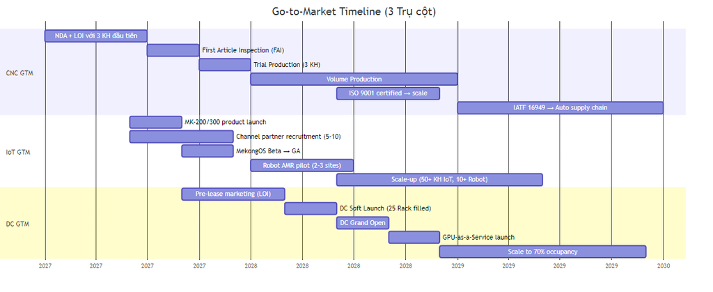

Diagram 18

### 3.8.2. Mục tiêu GTM theo Quý (Y1 Vận hành)

| Quý | CNC | IoT | DC | Revenue Target (K USD) |
| --- | --- | --- | --- | --- |
| **Y1 Q1** | 3 KH hoạt động, 15% utilization | 20 IoT Gateway bán, MekongOS 10 users | Pre-lease 5 LOI | 300-500 |
| **Y1 Q2** | 5 KH, 25% util., 1 repeat order | 50 Gateway, 2 Robot demo | 15 Rack filled | 600-900 |
| **Y1 Q3** | 8 KH, 35% util., 2 annual contracts | 100 Gateway, 5 Robot orders, MekongOS 50 users | 25 Rack, 1 GPU customer | 900-1.200 |
| **Y1 Q4** | 10 KH, 45% util., ISO 9001 audit | 150 Gateway, 8 Robot, MekongOS 100 users | 35 Rack, SOC launched | 1.200-1.500 |
| **Y1 Total** |  |  |  | **3.000-4.100** |

## 3.9. Pipeline Khách hàng và Xác suất

### 3.9.1. CNC Pipeline (Pre-operation)

| # | Khách hàng | Ngành | Sản phẩm cần gia công | Volume dự kiến | Xác suất | Revenue/năm (K USD) |
| --- | --- | --- | --- | --- | --- | --- |
| 1 | **Bosch VN** | Ô tô | Vỏ sensor, connector | 5.000 chi tiết/tháng | 60% | 250-400 |
| 2 | **Nidec VN** | Motor/Ô tô | Shaft, Housing | 3.000 chi tiết/tháng | 50% | 200-350 |
| 3 | **Samsung SEHC** | Điện tử | Mold insert, Jig | On-demand | 40% | 150-300 |
| 4 | **VinFast** | Ô tô | Prototype parts | R&D phase | 30% | 100-200 |
| 5 | **Intel Products VN** | Bán dẫn | Test fixture, socket | On-demand | 35% | 80-150 |
| 6 | **Canon VN** | Quang học | Lens housing, mount | 2.000 chi tiết/tháng | 45% | 180-280 |
| 7 | **FDI Nhật (qua JETRO)** | Đa ngành | Mixed parts | Pipeline | 25% | 100-200 |
| 8 | **FDI Hàn (qua KOTRA)** | Điện tử | Bracket, chassis | Pipeline | 25% | 80-150 |
|  | **Weighted Total** |  |  |  |  | **~850 K** |

### 3.9.2. DC Pipeline (Pre-lease)

| # | Khách hàng | Nhu cầu | Rack dự kiến | Xác suất | Revenue/năm (K USD) |
| --- | --- | --- | --- | --- | --- |
| 1 | **VNG Corporation** | AI Training | 5-10 (GPU) | 40% | 360-720 |
| 2 | **FPT AI** | HPC / Model Training | 3-5 (GPU) | 35% | 216-360 |
| 3 | **Techcombank** | DR Site | 10 (Standard) | 50% | 180 |
| 4 | **VPBank** | DR + Backup | 8 (Standard) | 40% | 144 |
| 5 | **Startup AI (3-5 công ty)** | GPU-as-a-Service | 5-10 (GPU) | 30% | 360-720 |
| 6 | **DN trong KCNC (10-20)** | Colocation | 10-20 (Standard) | 60% | 180-360 |
|  | **Weighted Total** |  |  |  | **~750 K** |

### 3.9.3. Customer Acquisition Cost (CAC) theo Trụ cột

| Trụ cột | CAC trung bình | Sales Cycle | LTV (3 năm) | LTV/CAC |
| --- | --- | --- | --- | --- |
| **CNC** | 5.000-15.000 USD | 3-12 tháng | 120.000-500.000 USD | 15-35× |
| **IoT Gateway** | 200-500 USD | 1-3 tháng | 1.500-3.000 USD | 5-10× |
| **IoT Robot** | 3.000-8.000 USD | 6-18 tháng | 60.000-150.000 USD | 10-20× |
| **MekongOS SaaS** | 500 USD | 1-3 tháng | 2.376 USD (Pro 3Y) | 4,8× |
| **DC Colocation** | 2.000-5.000 USD | 6-18 tháng | 54.000-108.000 USD | 15-25× |
| **DC GPU-aaS** | 5.000-10.000 USD | 3-6 tháng | 216.000-500.000 USD | 25-50× |

## 3.10. Phân tích Doanh thu Theo mùa và Dòng tiền

### 3.10.1. Tính Mùa vụ theo Trụ cột

| Quý | CNC | IoT/Robot | Datacenter | Ghi chú |
| --- | --- | --- | --- | --- |
| **Q1 (Jan-Mar)** | Thấp (sau Tết) | Thấp-TB | Ổn định | CNC: FDI giảm volume Tết, ramp-up lại T2-T3 |
| **Q2 (Apr-Jun)** | Trung bình | Trung bình | Ổn định | Nhu cầu dần phục hồi |
| **Q3 (Jul-Sep)** | Cao | Cao | Cao | Auto production H2 peak, IoT budget cycle |
| **Q4 (Oct-Dec)** | Cao nhất | Cao nhất | Cao | Holiday production rush, year-end spending |

**Hệ số Mùa vụ (Seasonality Factor):**

| Quý | CNC Factor | IoT Factor | DC Factor | Weighted Average |
| --- | --- | --- | --- | --- |
| Q1 | 0,80 | 0,85 | 0,95 | 0,85 |
| Q2 | 0,95 | 0,95 | 1,00 | 0,97 |
| Q3 | 1,10 | 1,10 | 1,05 | 1,09 |
| Q4 | 1,15 | 1,10 | 1,00 | 1,09 |

### 3.10.2. Dòng tiền Hoạt động Dự kiến (Y3 — Steady State)

| Tháng | Revenue (K USD) | COGS (K USD) | OPEX (K USD) | **Net CF (K USD)** | Ghi chú |
| --- | --- | --- | --- | --- | --- |
| 1 | 800 | 440 | 350 | **+10** | Post-Tết slow start |
| 2 | 1.000 | 550 | 360 | **+90** | Ramp-up |
| 3 | 1.200 | 660 | 365 | **+175** | Normal |
| 4 | 1.250 | 688 | 365 | **+197** |  |
| 5 | 1.300 | 715 | 370 | **+215** |  |
| 6 | 1.250 | 688 | 370 | **+192** |  |
| 7 | 1.400 | 770 | 375 | **+255** | H2 peak starts |
| 8 | 1.450 | 798 | 375 | **+277** |  |
| 9 | 1.350 | 743 | 375 | **+232** |  |
| 10 | 1.500 | 825 | 380 | **+295** | Q4 holiday rush |
| 11 | 1.500 | 825 | 380 | **+295** |  |
| 12 | 1.400 | 770 | 380 | **+250** | Year-end |
| **Tổng Y3** | **15.400** | **8.470** | **4.445** | **+2.485** | **Net margin ~16%** |

> **[C] Working Capital Note:** CNC payment terms Net 30-60 ngày → Cash conversion cycle 45-75 ngày. DC prepaid monthly → CCC = 0. IoT product bán lẻ COD → CCC = 0. Blended CCC ~ 25-35 ngày → cần working capital buffer ~1,2 M USD.

## 3.11. Mô hình Đặt giá Chi tiết theo Ngành (Pricing Waterfall)

### 3.11.1. CNC Pricing Waterfall

| Lớp giá | Khoản mục | Hệ số / Giá trị | Ghi chú |
| --- | --- | --- | --- |
| **List MHR** | Base Machine Hour Rate | 55-95 USD/h | Tùy loại máy (3-axis vs 5-axis) |
| **Material Markup** | Phụ thu vật liệu | Cost + 15-25% | Margin thấp, pass-through |
| **Setup Fee** | Phí setup / chuẩn bị | 50-200 USD/lần | First-article cao hơn |
| **Programming** | CAD/CAM programming | 85-120 USD/h | Chỉ lần đầu / thay đổi |
| **Quality Premium** | AS9100 / IATF surcharge | +15-25% MHR | Chứng nhận costly |
| **Express Premium** | Urgent delivery (< 7 ngày) | +30-50% total | High-margin opportunity |
| **Volume Discount** | > 500 parts/lot | -5 to -15% | Cần đảm bảo margin > 30% |
| **Contract Discount** | Annual contract > 500K | -3 to -8% | Đổi lấy revenue visibility |
| **FX Adjustment** | USD/VND ±3% band | Annual review | Clause trong MSA |

**Ví dụ tính giá 1 batch — 100 pcs aluminum housing (3-axis):**

| Khoản mục | Tính toán | Giá trị (USD) |
| --- | --- | --- |
| Cycle time | 45 phút/pc × 100 pcs = 75h machine |  |
| MHR | 75h × 65 USD | 4.875 |
| Material | 100 × 8 kg × 3,5 USD/kg × 1,20 markup | 3.360 |
| Setup | 3 fixtures × 150 USD | 450 |
| Programming | 4 hours × 100 USD (first order only) | 400 |
| Inspection (CMM) | 5% sample = 5 pcs × 20 | 100 |
| Packaging + shipping | 100 × 2 USD | 200 |
| **Total order** |  | **9.385** |
| **Unit price** | 9.385 / 100 | **93,85 / pc** |
| **Margin** | ≈40% gross |  |

### 3.11.2. DC Pricing — Rack-level Economics

| Tier | Rack Config | Power/Rack | MRC (K USD) | Setup (K) | Annual Rev/Rack (K) |
| --- | --- | --- | --- | --- | --- |
| **Silver** | ½ rack (21U) | 2 kW | 0,8-1,2 | 0,5 | 9,6-14,4 |
| **Gold** | Full rack (42U) | 4-8 kW | 2,0-4,0 | 1,0 | 24,0-48,0 |
| **Platinum** | Full rack (42U) | 8-30 kW | 4,0-12,0 | 2,0 | 48,0-144,0 |
| **Cabinet** | Locked cage (4-20 racks) | 16-160 kW | 8,0-60,0 | 5,0-20,0 | 96,0-720,0 |

**Revenue per rack Y5 (steady-state) — Blended:**

- Average 80 racks occupied × 36K/rack/năm (blended) = **2.880K** colo revenue
- Managed services + interconnect uplift ≈ 25% = **720K**
- **Tổng DC Revenue Y5 ≈ 3.600K** [C — đối chiếu PHỤ LỤC S: Revenue Y5 = 3.606K]

### 3.11.3. IoT/Robot Pricing Architecture

| Sản phẩm | HW Price (USD) | SaaS Subscription (USD/th) | Installation (USD) | Total Y1 Revenue/Unit (USD) |
| --- | --- | --- | --- | --- |
| **MK-200 Basic** | 350 | 15 | 50 | 580 |
| **MK-200 Pro** | 450 | 25 | 100 | 850 |
| **MK-300 5G** | 700 | 35 | 200 | 1.320 |
| **MK-500 Edge AI** | 2.000-5.000 | 100 | 500 | 3.700-6.700 |
| **AMR-100** | 30.000 | 200 (maintenance) | 2.000 | 34.400 |
| **Fleet SW (10-pack)** | — | 500 | 1.000 | 7.000 |
| **MekongOS Standalone** | — | 50-200 | — | 600-2.400 |

**Recurring Revenue % tăng dần:**

| Năm | HW Revenue (%) | SaaS + Service (%) | Recurring ratio |
| --- | --- | --- | --- |
| Y1 | 80% | 20% | Low |
| Y3 | 60% | 40% | Growing |
| Y5 | 45% | 55% | Good |
| Y10 | 30% | 70% | SaaS-dominant |

## 3.12. Chiến lược Cạnh tranh (Competitive Strategy)

### 3.12.1. Competitive Positioning Map — CNC

| Tiêu chí | Mekong | VPIC | Cosmos | Hợp Long | TQ Competition |
| --- | --- | --- | --- | --- | --- |
| **5-axis capability** | 9/10 | 3/10 | 5/10 | 2/10 | 6/10 |
| **Certification (IATF/AS)** | 7/10 (by Y3) | 6/10 | 4/10 | 3/10 | 7/10 |
| **Price competitiveness** | 7/10 | 8/10 | 7/10 | 9/10 | 9/10 |
| **Quality consistency** | 8/10 | 5/10 | 6/10 | 4/10 | 5/10 |
| **Lead time** | 7/10 | 6/10 | 5/10 | 7/10 | 4/10 (logistics) |
| **NDA/ITAR compliance** | 8/10 | 3/10 | 3/10 | 2/10 | 2/10 |
| **Total** | **46/60** | **31/60** | **30/60** | **27/60** | **33/60** |

### 3.12.2. Competitive Positioning Map — Data Center

| Tiêu chí | Mekong | Viettel IDC | FPT DC | CMC DC | NTT VN |
| --- | --- | --- | --- | --- | --- |
| **Tier level** | III (design) | III+ | III | III | III+ |
| **PUE** | 1,32 → 1,26 | 1,45 | 1,50 | 1,55 | 1,35 |
| **Carrier-neutral** | Yes | No (Viettel) | No (FPT) | No (CMC) | Yes |
| **Price/rack/month** | $2.500 avg | $2.000 | $1.800 | $1.600 | $3.500 |
| **Scalability** | 100→200 rack | 1.000+ | 500+ | 300+ | 500+ |
| **Ecosystem value** | High (CNC+IoT) | Telco only | IT services | IT services | Global |
| **Proximity to KCNC** | On-site | 15-20 km | 10-15 km | 20 km | 10 km |

### 3.12.3. Win/Loss Strategy

| Scenario | Chiến thuật | Expected Win Rate |
| --- | --- | --- |
| **CNC vs TQ on price** | Avoid — focus precision + compliance | 60% (for 5-axis + cert) |
| **CNC vs VN competitor** | Quality + capability differentiation | 70% |
| **DC vs Big 3 (Viettel/FPT/CMC)** | Niche: carrier-neutral + PUE + KCNC ecosystem | 40% |
| **DC vs NTT/ST Telemedia** | Price advantage (-20%) + local support | 35% |
| **IoT vs Chinese hardware** | Platform play (MekongOS) + local support | 50% |
| **IoT vs VN startups** | Full-stack capability (HW+FW+Cloud) | 65% |

## 3.13. Dự báo Doanh thu 20 Năm — Chi tiết theo Trụ cột

### 3.13.1. Revenue Projection Table (K USD)

| Năm | CNC Base | CNC IATF/AS | DC Colo | DC Managed | IoT HW | IoT SaaS | **Tổng** |
| --- | --- | --- | --- | --- | --- | --- | --- |
| Y1 | 2.000 | — | 500 | 100 | 800 | 100 | **3.500** |
| Y2 | 3.500 | 500 | 1.200 | 300 | 1.500 | 300 | **7.300** |
| Y3 | 5.000 | 1.500 | 2.000 | 500 | 2.000 | 600 | **11.600** |
| Y4 | 5.500 | 2.500 | 2.800 | 700 | 2.200 | 1.000 | **14.700** |
| Y5 | 5.500 | 3.000 | 3.000 | 800 | 2.500 | 1.300 | **16.100** |
| Y7 | 6.000 | 4.500 | 4.500 | 1.500 | 3.000 | 3.000 | **22.500** |
| Y10 | 7.000 | 6.000 | 6.000 | 2.500 | 4.000 | 5.000 | **30.500** |
| Y15 | 8.000 | 8.000 | 8.000 | 4.000 | 5.000 | 10.000 | **43.000** |
| Y20 | 9.000 | 10.000 | 10.000 | 5.000 | 6.000 | 15.000 | **55.000** |

### 3.13.2. Revenue Mix Evolution

**Biểu đồ: Revenue Mix Evolution (%)**

| Trụ cột | Y1 | Y5 | Y10 | Y20 |
| --- | --- | --- | --- | --- |
| CNC | 57% | 53% | 43% | 35% |
| DC | 17% | 24% | 28% | 27% |
| IoT | 26% | 24% | 30% | 38% |

> **Chú giải:** Cột 1 = CNC | Cột 2 = DC | Cột 3 = IoT

> **Xu hướng chiến lược:** CNC vẫn là backbone revenue nhưng giảm dần tỷ trọng (57% → 35%). IoT/SaaS tăng mạnh nhất (26% → 38%) nhờ recurring revenue compound. DC ổn định ở 24-28% — predictable cash flow. Đây là mô hình healthy diversification [A].

# PHẦN IV: HẠ TẦNG KỸ THUẬT VÀ THIẾT KẾ CƠ SỞ VẬT CHẤT

## 4.1. Quy hoạch Tổng mặt bằng

### 4.1.1. Thông tin Khu đất

| Thông số | Giá trị |
| --- | --- |
| **Địa điểm** | Khu Công nghệ cao TP.HCM (SHTP), Quận 9 (nay TP. Thủ Đức) |
| **Lô đất** | Theo phân bổ BQL KCNC |
| **Diện tích lô** | 1 ha (10.000 m²) |
| **Mật độ xây dựng cho phép** | ≤ 75% (7.500 m²) |
| **Mật độ xây dựng thực tế** | 70% (7.000 m²) — footprint tòa nhà |
| **Chiều cao tối đa** | 14 m (3 tầng: 6m + 4m + 4m) |
| **Tổng GFA (Gross Floor Area)** | 21.000 m² (7.000 m² × 3 tầng) |
| **Thuê đất KCNC** | ~1,0 USD/m²/tháng [B], miễn 11 năm đầu |
| **Chi phí thuê đất/năm** | 120.000 USD (10.000 × 1,0 × 12) [C] |

### 4.1.2. Phân khu Chức năng — Tòa nhà 3 Tầng

**Nguyên tắc thiết kế:**

- **Tầng 1 (chiều cao thông thủy 6m):** Bố trí các hạng mục nặng, cần chiều cao lớn (CNC 5 trục cần cẩu trục, Datacenter cần chiều cao rack 42U+, kho hàng + loading dock cho xe tải)
- **Tầng 2 (chiều cao 4m):** Bố trí IoT/SMT line (máy Pick & Place nhẹ), Clean Room, lắp ráp robot, phòng QC — không cần chiều cao lớn, nhạy cảm rung động → thiết kế tách rung với tầng 1
- **Tầng 3 (chiều cao 4m):** Văn phòng điều hành, R&D Lab, đào tạo, căn tin — khu vực nhẹ, không tải trọng sàn đặc biệt

| Tầng | Khu vực | Diện tích (m²) | Chức năng |
| --- | --- | --- | --- |
| **1** | **CNC Workshop (MPMC)** | 3.000 | Xưởng CNC 5 trục + Phòng đo CMM + Kho phôi |
| **1** | **Datacenter (MACC)** | 1.500 | Data Hall + NOC + UPS/Battery + HVAC/Chiller |
| **1** | **M&E Room** | 500 | Trạm biến áp, máy phát, ATS, MDB |
| **1** | **Kho + Loading Dock** | 1.500 | Kho NVL + thành phẩm, loading bay 2 xe tải |
| **1** | **Sảnh + Hành lang** | 500 | Lối vào chính, thang máy hàng, cầu thang thoát hiểm |
| **2** | **IoT/SMT Line** | 2.500 | 2 dây chuyền SMT + Wave Solder + AOI |
| **2** | **Clean Room (Class 10K)** | 1.000 | Lắp ráp IoT Gateway, calibration |
| **2** | **Assembly + Testing** | 1.500 | Lắp ráp Robot AMR/AGV, End-of-Line test |
| **2** | **QC Lab** | 1.000 | AOI, X-Ray, Burn-in, phòng đo |
| **2** | **Hành lang + WC + Phụ trợ** | 1.000 | Elevator lobby, toilet, FHC |
| **3** | **Văn phòng điều hành** | 2.500 | Phòng GĐ, phòng họp, HR, kế toán, showroom |
| **3** | **R&D Lab** | 1.500 | Phòng thiết kế PCB, software dev, AI training room |
| **3** | **Đào tạo + Căn tin** | 1.300 | Training room 50 chỗ, canteen 80 chỗ |
| **3** | **Hội nghị + Phụ trợ** | 1.700 | Phòng hội nghị lớn, archive, server room IT nội bộ |
|  | **Tổng GFA** | **21.000** |  |

**Khu vực ngoài nhà (3.000 m²):**

[output not shown]

### 4.1.3. Layout Tổng thể — Mặt bằng 1 ha

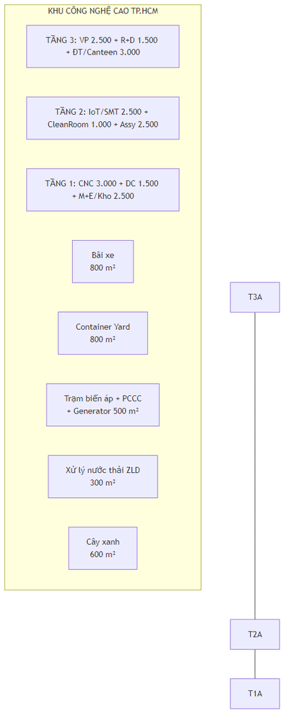

Diagram 19

### 4.2.1. Kiến trúc Vật lý

**Tầng 1 (Ground Floor) — Data Hall + MEP:**

| Phòng | Diện tích | Chức năng |
| --- | --- | --- |
| Data Hall Zone 1 (Colo) | 600 m² | 50 Racks, In-Row Cooling |
| Data Hall Zone 2 (AI/HPC) | 600 m² | 50 Racks, Liquid Cooling + RDHX |
| Loading Dock | 100 m² | Nhận thiết bị |
| Battery Room (UPS) | 150 m² | 4 × 1.000 kVA LiFePO4 |
| Switchgear | 80 m² | ATS + MDB + PDU |
| Chiller Plant Room | 200 m² | 2N Chiller + CDU |
| NOC (Network Operations Center) | 80 m² | Giám sát 24/7 |
| Meet-Me Room (MMR) | 40 m² | Cross-connect, carrier entrance |
| Security / Mantrap | 50 m² | Biometric 3-factor, CCTV |
| Generator Yard (ngoài trời) | 200 m² | 2 × 2.500 kVA Diesel + Bồn dầu |
| Cooling Tower (ngoài trời) | 150 m² | Evaporative cooling + Free cooling |

### 4.2.2. Hệ thống Điện — Sơ đồ Một dây

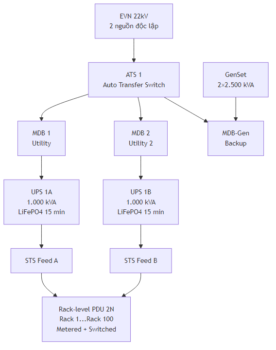

Diagram 20

**Thông số Điện:**

[output not shown]

### 4.2.3. Hệ thống Làm mát Chi tiết

**Zone 1 — Colocation (Chilled Water In-Row):**

| Thông số | Giá trị |
| --- | --- |
| Tải nhiệt | 50 Rack × 8 kW = 400 kW (trung bình) |
| Cooling capacity | 600 kW (N+1, 50% dự phòng) |
| Chiller | 2 × 350 kW water-cooled screw chiller |
| CRAH | 6 × 100 kW In-Row units (N+1) |
| Set point | Cold aisle: 22-24°C, Hot aisle: 35-40°C |
| Containment | Hot Aisle Containment (HAC) |
| Monitoring | Temperature/humidity sensor mỗi 3 rack |

**Zone 2 — AI/HPC (Hybrid: Direct-to-Chip + Rear-Door Heat Exchanger):**

| Thông số | Giá trị |
| --- | --- |
| Tải nhiệt | 50 Rack × 25 kW = 1.250 kW (trung bình) |
| Cooling capacity | 1.875 kW (N+1, 50% dự phòng) |
| CDU (Coolant Distribution Unit) | 4 × 500 kW (Vertiv/Schneider) |
| Liquid cooling phần trăm nhiệt | 70% (trực tiếp đến chip GPU) |
| Rear-Door HEX (RDHX) | 30% còn lại (server fans → RDHX → chilled water) |
| Chilled water supply | 15-18°C (cao hơn Zone 1, tiết kiệm năng lượng) |
| Coolant | Propylene glycol 30% (an toàn, không dẫn điện) |
| Flow rate | 20-30 L/phút/rack |

**Tính toán Electroless Water Consumption:**

| Nguồn tiêu thụ | Lưu lượng | Phương pháp |
| --- | --- | --- |
| Cooling tower make-up (evaporation) | 40-60 m³/ngày | Evaporation + Blowdown + Drift |
| Liquid cooling loop (sealed) | 0 m³/ngày | Tuần hoàn kín |
| Humidification | 5-10 m³/ngày | Adiabatic humidifier |
| Domestic (nhân viên) | 3-5 m³/ngày | 30-50 người × 100 L/ngày |
| **Tổng** | **48-75 m³/ngày** |  |

### 4.2.4. Hệ thống An ninh Vật lý

[output not shown]

### 4.2.5. Hệ thống Mạng

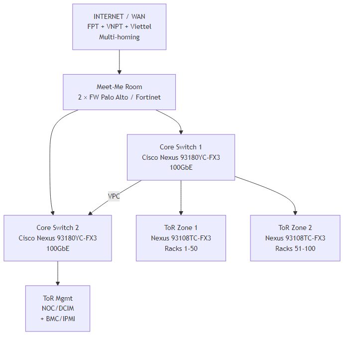

Diagram 21

**AI/HPC Network (Zone 2 riêng):**

- GPU Fabric: NVIDIA InfiniBand HDR 200Gbps (fat-tree topology)
- Storage: NVMe-oF over 100GbE (NetApp / Pure Storage)
- Latency: < 1 µs (GPU-to-GPU), < 5 µs (GPU-to-Storage)

## 4.3. Thiết kế Hạ tầng Khu vực CNC — Tầng 1 (MPMC)

### 4.3.1. Layout Xưởng CNC

[figure not shown]

Diagram 22

### 4.3.2. Yêu cầu Nền Móng và Sàn

[output not shown]

### 4.3.3. Hệ thống Điện Khối B

| Phụ tải | Công suất | Ghi chú |
| --- | --- | --- |
| 28 máy CNC (rated) | 800 kW | ~25-35 kW/máy trung bình |
| Hệ thống cooling CNC | 100 kW | Chiller dung dịch cắt |
| Hệ thống hút bụi/khói | 50 kW | Dành cho titanium, Inconel |
| Hệ thống khí nén | 75 kW | 2 × Screw compressor |
| Đèn chiếu sáng | 40 kW | ≥ 500 lux tại bàn máy |
| HVAC | 60 kW | Phòng CMM + Văn phòng |
| Phụ tải khác | 25 kW | Phòng CAD, kho, phụ trợ |
| **Tổng Khối B** | **1.150 kW** |  |

### 4.3.4. Hệ thống Phụ trợ CNC

**Hệ thống Khí nén (Compressed Air):**

- 2 × Screw compressor 37 kW, 8 bar
- Air dryer (dew point -40°C)
- Air receiver 2.000 L
- Ống phân phối stainless steel
- Công suất: 5,0 Nm³/phút, đủ cho 28 máy CNC

**Hệ thống Dung dịch Cắt gọt (Coolant):**

- Central coolant system (thay vì từng máy riêng)
- Dung tích: 10.000 L tổng
- Lọc: Multi-stage filtration (20µm → 5µm → 1µm)
- Kiểm soát nồng độ: Refractometer tự động
- Thu hồi: Thu chip + Dầu — tái chế qua ZLD

### 4.4.1. Layout Dây chuyền SMT

| Khu vực | Diện tích | Chức năng |
| --- | --- | --- |
| Dây chuyền SMT Line 1 | 300 m² | IoT Gateway MK-200 (volume) |
| Dây chuyền SMT Line 2 | 300 m² | IoT Gateway MK-300 + Robot PCB |
| Lắp ráp Robot (Assembly) | 500 m² | Final assembly AMR/AGV/OHT |
| Burn-in / Test | 200 m² | 72h burn-in + Functional test |
| Lab R&D Phần cứng | 150 m² | Prototyping + EMC pre-compliance |
| Lab AI & Robotics | 200 m² | AI development, ROS2, simulation |
| Kho linh kiện | 200 m² | SMD reel storage, humidity-controlled |
| Khu vực đóng gói | 150 m² | Packing + Labeling + Shipping |
| VP Kỹ thuật | 100 m² | R&D firmware, PCB layout |
| **Tổng** | **2.100 m²** | (còn lại: hành lang + phụ trợ) |

### 4.4.2. Thiết bị SMT

| TT | Thiết bị | Hãng | Số lượng | Giá (K USD) |
| --- | --- | --- | --- | --- |
| 1 | Solder Paste Printer | DEK (ASM) | 2 | 80-120 |
| 2 | SPI (Solder Paste Inspection) | Koh Young | 2 | 100-150 |
| 3 | Pick & Place (high-speed) | Yamaha YSM20R | 2 | 200-300 |
| 4 | Pick & Place (fine-pitch) | Yamaha YSM20R | 1 | 120-180 |
| 5 | Reflow Oven | Heller 1913 MK7 | 2 | 80-120 |
| 6 | AOI (Automated Optical Inspection) | Omron VT-X750 | 2 | 100-150 |
| 7 | X-ray Inspection | Nikon XT V 160 | 1 | 200-280 |
| 8 | Wave Soldering | SEHO SelectLine | 1 | 50-80 |
| 9 | ICT (In-Circuit Test) | Keysight i3070 | 1 | 80-120 |
| 10 | Flying Probe Test | Takaya APT-1400F | 1 | 60-90 |
|  | **Tổng SMT** |  |  | **1.070-1.590** |

### 4.4.3. Điều kiện Sản xuất Điện tử

| Thông số | Giá trị | Lý do |
| --- | --- | --- |
| Nhiệt độ | 23 ± 2°C | Kiểm soát solder paste rheology |
| Độ ẩm | 40-60% RH | Chống tĩnh điện, tránh oxidation |
| ESD | EPA (ESD Protected Area) toàn bộ | IEC 61340-5-1 compliance |
| Sạch | Class 100.000 (ISO 8) | Tránh bụi vào solder joint |
| Ánh sáng | ≥ 750 lux tại inspection | Visual inspection requirement |

## 4.5. Hệ thống M&E Chung — Bill of Quantities (BOQ)

### 4.5.1. Tổng hợp BOQ theo Hạng mục

| TT | Hạng mục | Khối A (K USD) | Khối B (K USD) | Khối C (K USD) | Chung (K USD) | **Tổng (K USD)** |
| --- | --- | --- | --- | --- | --- | --- |
| 1 | Hệ thống điện (HT, HA, chiếu sáng) | 1.200 | 350 | 250 | 200 | **2.000** |
| 2 | UPS + Battery | 1.600 | 50 | 30 | 20 | **1.700** |
| 3 | Generator | 800 | 100 | 50 | 50 | **1.000** |
| 4 | Cooling / HVAC | 1.500 | 150 | 120 | 80 | **1.850** |
| 5 | PCCC | 350 | 250 | 200 | 300 | **1.100** |
| 6 | Hệ thống nước (cấp + thải) | 150 | 200 | 80 | 350 | **780** |
| 7 | Hệ thống mạng + Cáp quang | 500 | 50 | 80 | 70 | **700** |
| 8 | An ninh (CCTV, Access Control) | 200 | 50 | 50 | 100 | **400** |
| 9 | BMS / DCIM | 250 | 30 | 20 | — | **300** |
| 10 | Khí nén + Phụ trợ CNC | — | 200 | — | — | **200** |
| 11 | Cẩu trục | — | 120 | 30 | — | **150** |
| 12 | Nền móng đặc biệt | 50 | 80 | 15 | 30 | **175** |
|  | **Tổng** | **6.600** | **1.630** | **925** | **1.200** | **10.355** |

*[C — Chi tiết BOQ tính toán từ benchmark giá thị trường VN 2024-2025, bao gồm 10% dự phòng]*

### 4.5.2. Phân kỳ M&E

| Hạng mục | Phase 1 (K USD) | Phase 2 (K USD) | Ghi chú |
| --- | --- | --- | --- |
| Khối A — DC cơ bản (50 Rack) | 4.200 | — | Zone 1 full + Zone 2 shell |
| Khối A — DC mở rộng (50 Rack) | — | 2.400 | Zone 2 AI/HPC fit-out |
| Khối B — CNC (15 máy) | 1.100 | — | Cooling + Compressed air + Crane |
| Khối B — CNC mở rộng (13 máy) | — | 530 | Add’l capacity |
| Khối C — SMT Full | 925 | — | 2 SMT lines + Assembly |
| Hạ tầng chung | 600 | 600 | PCCC + Nước + An ninh + BMS |
| **Tổng M&E** | **6.825** | **3.530** | **10.355** |

> **Lưu ý chênh lệch:** Ngân sách M&E tổng 10.355 K nhưng budget dự kiến trong mô hình tài chính là ~13.200 K (bao gồm cả xây dựng dân dụng). Chênh lệch ~2.845 K phân bổ cho xây dựng kết cấu, hoàn thiện, đường nội bộ, hệ thống thoát nước mưa, và cảnh quan [C].

## 4.6. Hệ thống Cấp nước và Xử lý Nước thải

### 4.6.1. Nhu cầu Nước

| Nguồn tiêu thụ | Lưu lượng (m³/ngày) | Ghi chú |
| --- | --- | --- |
| **Khối A — DC Cooling tower** | 40-60 | Make-up water (evaporation + blowdown) |
| **Khối A — Humidification** | 5-10 | Adiabatic humidification |
| **Khối B — CNC Coolant** | 8-15 | Dung dịch cắt + Làm mát máy |
| **Khối C — SMT** | 2-3 | DI water (rửa PCB) + Cleaning |
| **Sinh hoạt** | 15-25 | 150-250 người × 100 L/ngày |
| **Cây xanh** | 10-20 | Tưới cảnh quan |
| **Tổng (Peak)** | **80-133** |  |
| **Tổng (bình thường)** | **60-90** |  |

### 4.6.2. Giải pháp Cấp nước — 4 Phương án Kết hợp

Phân tích rủi ro: Hạn ngạch nước KCNC cho lô đất này ước tính 150 m³/ngày. Peak demand có thể vượt nếu DC chạy 100% AI/HPC. Giải pháp:

[output not shown]

Sau áp dụng 4 phương án: Peak demand giảm từ 133 → 58-90 m³/ngày — nằm trong hạn ngạch 150 m³/ngày [C].

### 4.6.3. Hệ thống Xử lý Nước thải

**Sơ đồ Hệ thống:**

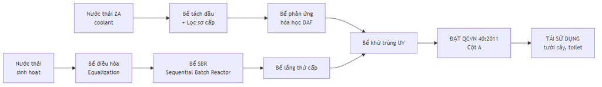

Diagram 23

**Thông số Trạm XLNT:**

[output not shown]

## 4.7. Hệ thống Phòng cháy Chữa cháy (PCCC)

### 4.7.1. Phân loại Nguy hiểm Cháy

| Khu vực | Phân loại | Hệ thống chữa cháy | Ghi chú |
| --- | --- | --- | --- |
| **Khối A — Data Hall** | Nguy hiểm cao | NOVEC 1230 (Clean Agent) | Không gây hại thiết bị điện tử |
| **Khối A — Battery/UPS** | Nguy hiểm cao | NOVEC 1230 + Foam | LiFePO4 ít nguy hiểm hơn Li-ion |
| **Khối A — Generator** | Nguy hiểm cao | Foam + CO₂ | Bồn diesel → foam |
| **Khối B — Xưởng CNC** | Nguy hiểm trung bình | Sprinkler + Foam | Dầu cắt gọt là chất cháy |
| **Khối B — Kho phôi** | Nguy hiểm cao | Sprinkler deluge | Kim loại, hóa chất |
| **Khối C — SMT** | Nguy hiểm trung bình | NOVEC 1230 (SMT area) + Sprinkler | Bảo vệ PCB inventory |
| **Khối C — Assembly** | Nguy hiểm thấp-trung bình | Sprinkler |  |
| **Văn phòng** | Nguy hiểm thấp | Sprinkler |  |
| **Kho vật tư** | Nguy hiểm trung bình | Sprinkler + Foam | Tùy loại hàng |
| **Generator室** | Nguy hiểm cao | Foam + CO₂ |  |
| **Ngoài trời** |  | Hydrant + Fire hose reel |  |

### 4.7.2. Hệ thống PCCC Chi tiết

**Hệ thống báo cháy (Fire Detection):**

| Thiết bị | Số lượng | Vùng phủ |
| --- | --- | --- |
| Đầu báo khói quang (Optical Smoke Detector) | 350 | Toàn bộ |
| Đầu báo nhiệt (Heat Detector) | 80 | Bếp, Generator |
| VESDA (Very Early Smoke Detection) | 20 | Data Hall, UPS Room, Battery Room |
| Nút nhấn khẩn cấp (Manual Call Point) | 40 | Hành lang, lối ra |
| Chuông + Đèn báo cháy (Sounder + Beacon) | 60 | Toàn khu vực |
| Trung tâm báo cháy (Fire Alarm Panel) | 2 | NOC + Phòng bảo vệ |
| Kết nối 119 | 1 | Kết nối tự động đến PCCC TP.HCM |

**Hệ thống chữa cháy (Fire Suppression):**

| Hệ thống | CAPEX (K USD) | Khu vực |
| --- | --- | --- |
| NOVEC 1230 Clean Agent | 320-400 | Data Hall (2 zone), UPS, SMT critical |
| Wet Pipe Sprinkler | 200-280 | Văn phòng, Assembly, Kho |
| Pre-Action Sprinkler | 120-180 | CNC area (tránh xả giả) |
| Foam System | 100-150 | Generator, Diesel tank, CNC coolant |
| CO₂ System | 60-80 | Generator room |
| Fire Hydrant (ngoài trời) | 100-150 | 6 trụ, bao phủ toàn khu |
| Fire Pump (Diesel + Electric + Jockey) | 180-250 | 1 diesel 150HP + 1 electric 150HP + 1 jockey |
| Bồn nước PCCC | 100-150 | 500 m³ (đủ 2 giờ chữa cháy) |
| **Tổng PCCC** | **1.180-1.640** |  |
| **Trung bình (with 10% contingency)** | **~1.550** |  |

*[C — Giá tham chiếu thị trường VN 2024-2025]*

### 4.7.3. Tuân thủ PCCC

| Quy chuẩn | Mã | Yêu cầu |
| --- | --- | --- |
| QCVN 06:2022/BXD | An toàn cháy cho nhà và công trình | Lối thoát hiểm, chịu lửa |
| TCVN 7336:2023 | Sprinkler tự động | Thiết kế, lắp đặt |
| TCVN 5738:2021 | Hệ thống báo cháy | Đầu báo, trung tâm |
| NFPA 75 | ICT Equipment | Data Center specific |
| NFPA 2001 | Clean Agent | NOVEC 1230 design |
| FM Global DS 5-32 | Data Center | Tiêu chuẩn bảo hiểm DC |
| Nghị định 136/2020/NĐ-CP | PCCC | Thẩm duyệt thiết kế |
| Nghị định 50/2024/NĐ-CP | Sửa đổi NĐ 136 | Cập nhật mới nhất |

### 4.7.4. Phương án Phòng cháy

**Khoảng cách an toàn:**

- Khoảng cách giữa các khối: ≥ 10 m
- Khoảng cách đến ranh giới: ≥ 6 m
- Đường xe cứu hỏa: Rộng ≥ 3,5 m, vòng quanh tòa nhà
- Bãi đậu xe cứu hỏa: ≥ 2 vị trí (mặt trước Khối A và Khối B)

**Thoát hiểm:**

- Tối thiểu 2 lối thoát mỗi tầng, mỗi khu vực
- Chiều rộng lối thoát: ≥ 1,2 m
- Khoảng cách đến lối thoát: ≤ 25 m (nguy hiểm cao), ≤ 40 m (nguy hiểm thấp)
- Đèn EXIT + Đèn chiếu sáng sự cố: Pin backup 60 phút
- Sơ đồ thoát hiểm: Dán tại mỗi phòng + Hành lang

## 4.8. Hệ thống Quản lý Tòa nhà (BMS/DCIM)

### 4.8.1. BMS (Building Management System)

Phần mềm: Schneider EcoStruxure Building Operation hoặc Honeywell Niagara:

| Hệ thống con | Thông số giám sát |
| --- | --- |
| HVAC | Nhiệt độ, độ ẩm, áp suất, lưu lượng gió |
| Điện | Công suất, dòng, áp, PF, THD, năng lượng |
| Nước | Lưu lượng, áp lực, chất lượng (pH, TDS) |
| PCCC | Trạng thái đầu báo, van, bơm |
| An ninh | Access control log, CCTV live + playback |
| Chiếu sáng | On/Off, dimming, timer |

### 4.8.2. DCIM (Data Center Infrastructure Management)

Phần mềm: Schneider EcoStruxure IT Expert hoặc Vertiv Trellis:

| Chức năng | Mô tả |
| --- | --- |
| Power Monitoring | PUE real-time, kW/rack, UPS status |
| Cooling Monitoring | Nhiệt độ/độ ẩm từng rack, chiller/CDU status |
| Capacity Planning | Rack space, power, cooling capacity forecast |
| Change Management | Ticket tracking cho di chuyển thiết bị |
| Asset Management | Inventory rack/server/cable |
| Alerting | SMS/Email khi vượt ngưỡng, escalation |
| Reporting | Monthly PUE, availability, SLA compliance |

## 4.9. Tổng hợp Chi phí Hạ tầng

### 4.9.1. CAPEX Hạ tầng theo Khối

| Hạng mục | Khối A — DC (K USD) | Khối B — CNC (K USD) | Khối C — IoT (K USD) | Chung (K USD) | **Tổng (K USD)** |
| --- | --- | --- | --- | --- | --- |
| Xây dựng dân dụng | 1.500 | 1.200 | 800 | 500 | **4.000** |
| M&E (BOQ Bảng 4.5.1) | 6.600 | 1.630 | 925 | 1.200 | **10.355** |
| Thiết bị sản xuất | — | 9.590 | 1.070 | — | **10.660** |
| Thiết bị IT / GPU | 3.000 | — | — | — | **3.000** |
| Phần mềm | 200 | 102 | 50 | 100 | **452** |
| Nội thất + Phụ kiện | 50 | 100 | 80 | 200 | **430** |
| Dự phòng 5% | 568 | 631 | 146 | 100 | **1.445** |
| **Tổng** | **11.918** | **13.253** | **3.071** | **2.100** | **~30.342** |

> **Lưu ý:** CAPEX hạ tầng ~30.342 K ở đây là phần xây dựng + M&E + thiết bị. Tổng CAPEX dự án 47.500 K bao gồm thêm: đất + chi phí pháp lý + chi phí trước vận hành + working capital ban đầu. Chi tiết tại Phần V — Tài chính [C].

## 4.10. Hệ thống Điện Trung thế và Hạ thế

### 4.10.1. Sơ đồ Cấp điện Tổng thể

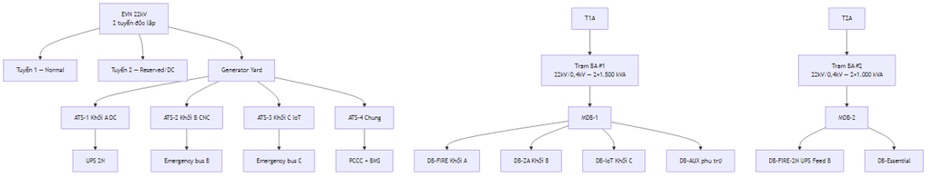

Diagram 24

### 4.10.2. Phụ tải Điện theo Khối

| Khối | Phụ tải IT/SX (kW) | Phụ tải M&E (kW) | Phụ tải phụ trợ (kW) | **Tổng (kW)** | Hệ số đồng thời | **Demand (kW)** |
| --- | --- | --- | --- | --- | --- | --- |
| **A — DC** | 1.200 | 480 (cooling, PUE) | 50 | 1.730 | 0,90 | **1.557** |
| **B — CNC** | 1.800 (28 máy peak) | 300 (HVAC, coolant pump) | 80 | 2.180 | 0,70 | **1.526** |
| **C — IoT/SMT** | 400 (SMT line + Assembly) | 150 (HVAC, Clean room) | 50 | 600 | 0,75 | **450** |
| **Chung** | — | 200 (bơm PCCC, BMS) | 150 (VP, canteen, chiếu sáng) | 350 | 0,80 | **280** |
| **Tổng** | **3.400** | **1.130** | **330** | **4.860** |  | **~3.813** |
| **Yêu cầu EVN** |  |  |  |  |  | **≥ 4.500 kVA** |

> **[C] Peak demand 3.813 kW, yêu cầu EVN cấp ≥ 4.500 kVA (hệ số PF 0,85).** Trạm BA tổng cộng 5.000 kVA (2×1.500 + 2×1.000) — đủ N+1. Chi phí đường dây 22kV từ trạm nguồn KCNC: ~150-250 K USD.

### 4.10.3. Chất lượng Điện năng

| Thông số | Tiêu chuẩn | Biện pháp | CAPEX (K USD) |
| --- | --- | --- | --- |
| **Sóng hài (THD)** | < 5% (IEEE 519) | Active Harmonic Filter cho DB-CNC (VFD gây hài) | 30-50 |
| **Hệ số công suất** | > 0,95 | Tụ bù APFC tại mỗi MDB | 15-25 |
| **Điện áp ổn định** | ±5% | AVR tại máy biến áp | Included |
| **Chống sét** | IEC 62305 | SPD Class I+II tại MDB, Class II+III tại DB | 10-15 |
| **Nối đất** | < 1 Ω (DC), < 5 Ω (general) | Hệ thống nối đất đẳng thế (TN-S) | 20-30 |
| **UPS DC (2N)** | Tier III requirement | Schneider Galaxy VX 2N | 350-850 |
| **Generator** | N+1 | Cummins/Cat 4 × 750 kVA + SCR/DPF | 400-600 |

## 4.11. Hệ thống HVAC và Kiểm soát Môi trường

### 4.11.1. Yêu cầu Nhiệt độ/Độ ẩm theo Khu vực

| Khu vực | Nhiệt độ (°C) | Humidity (%RH) | Tiêu chuẩn | Làm sạch không khí | Áp suất |
| --- | --- | --- | --- | --- | --- |
| **DC Data Hall** | 22-27 (ASHRAE A1) | 20-80% | ASHRAE TC 9.9 | MERV 8 | Dương (+5 Pa) |
| **CNC Workshop** | 22-28 (general) | 30-70% | ISO 8573 | MERV 8 + Mist Collector | Âm (-5 Pa) |
| **CNC CMM Room** | 20 ± 0,5 | 45-55% | ISO 1:2016 | HEPA H13 | Dương (+10 Pa) |
| **SMT Clean Room** | 22 ± 2 | 40-60% | ISO 14644 Class 7 | HEPA H14 | Dương (+15 Pa) |
| **SMT Assembly** | 22-26 | 30-60% | IPC-A-610 | MERV 11 | Dương (+5 Pa) |
| **R&D Lab** | 22 ± 2 | 40-60% | ISO 17025 ref. | HEPA H13 | Dương (+10 Pa) |
| **Văn phòng** | 24 ± 2 | 50-70% | ASHRAE 55 | MERV 8 | Neutral |
| **Kho phôi/vật tư** | 18-35 (không cần kiểm soát chặt) | < 80% | — | — | Neutral |
| **Canteen** | 24-28 | — | — | — | Âm |

### 4.11.2. Thiết bị HVAC theo Khu vực

| Khu vực | Thiết bị | Công suất | Số lượng | CAPEX (K USD) |
| --- | --- | --- | --- | --- |
| **DC Data Hall 1** | CRAC Row-based (Schneider InRow) | 60 kW each | 6+2 (N+2) | 210 |
| **DC Data Hall 2 + GPU** | CDU + Rear Door HX | 100 kW CDU | 3+1 | 200 |
| **DC Chiller** | Air-cooled Chiller (Daikin/Trane) | 250 kW each | 3+1 | 360 |
| **CNC Workshop** | AHU + Exhaust + Mist Collector | 80 kW cooling | 4 | 120 |
| **CNC CMM Room** | Precision AHU (Stulz/Emerson) | 10 kW, ±0,5°C | 2 (1+1) | 60 |
| **SMT Clean Room** | FFU + AHU + MAU | 40 kW | 2+1 | 80 |
| **Văn phòng + Canteen** | VRV/VRF System (Daikin) | 100 kW total | 4 outdoor | 80 |
| **R&D Lab** | Precision AHU | 15 kW each | 3 | 45 |
| **Kho** | Quạt thông gió tự nhiên + Exhaust | — | 6 | 5 |
| **Tổng HVAC** |  |  |  | **~1.160** |

### 4.11.3. Hệ thống Hút Khói/Bụi CNC (Central Extraction)

| Thông số | Giá trị | Ghi chú |
| --- | --- | --- |
| **Loại** | Central oil mist collector + HEPA | Cho 28 máy CNC |
| **Công suất** | 15.000 m³/h (tổng) | 500-800 m³/h per machine |
| **Hiệu suất** | > 99,97% @ 0,3µm (HEPA H13) | DOP test hàng năm |
| **Pre-filter** | Coalescent fiber (oil mist stage 1) | Thay 3 tháng/lần |
| **HEPA** | H13 (oil mist stage 2) | Thay 12 tháng/lần |
| **Activated Carbon** | Stage 3 (cho VOCs từ coolant) | Thay 6 tháng/lần |
| **Motor** | 2 × 15 kW (N+1) | IE4 Premium Efficiency |
| **Ductwork** | Galvanized steel, ø200-400mm | Balanced design, ≤ 15 m/s |
| **Điểm hút** | 28 points (1 per CNC) + 4 manual stations | Flexible arm |
| **CAPEX** | 120 K USD (incl. ductwork + installation) |  |
| **OPEX** | 15 K USD/năm (filters + electricity) |  |
| **EIA compliance** | QCVN 19:2009 Cột A cho khí thải | Xem Phụ lục R.9 |

## 4.12. Hệ thống An ninh và Kiểm soát Truy cập

### 4.12.1. Mô hình An ninh 5 Lớp

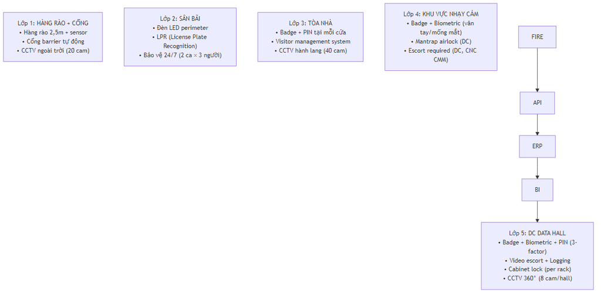

Diagram 25

### 4.12.2. Thiết bị An ninh

| Hạng mục | Số lượng | Hãng | CAPEX (K USD) |
| --- | --- | --- | --- |
| CCTV Camera (4K, IR, PoE) | 80 | Hikvision DS-2CD2687 | 40 |
| NVR (Network Video Recorder) | 4 | Hikvision DS-96128NI | 8 |
| Storage (CCTV 90 ngày) | 200 TB | Seagate SkyHawk | 15 |
| Access Control Panel | 8 | HID iCLASS SE | 12 |
| Card Reader (Badge) | 40 | HID iCLASS SE | 10 |
| Biometric Reader (Fingerprint + Iris) | 10 | Suprema BioStation 3 | 15 |
| Mantrap (DC entrance) | 2 | Boon Edam | 25 |
| Barrier Gate (Parking) | 2 | FAAC / Nice | 5 |
| LPR Camera | 2 | Hikvision / Genetec | 3 |
| Visitor Management Kiosk | 2 | Custom tablet + Software | 3 |
| E-lock (Cabinet lock per rack) | 100 | Chatsworth CPI | 20 |
| Perimeter sensor (IR beam) | 20 | Optex | 5 |
| PA System (Announcement) | 1 lot | TOA / Bosch | 5 |
| VMS Software (Video Management) | 1 | Genetec / Milestone | 8 |
| PSIM Integration | 1 | CNL / Genetec | 5 |
| **Tổng An ninh** |  |  | **~179** |

## 4.13. Hệ thống Công nghệ Thông tin (IT Infrastructure)

### 4.13.1. Hạ tầng Mạng Nội bộ

| Hạng mục | Thông số | CAPEX (K USD) |
| --- | --- | --- |
| **Core Switch** | 2 × Cisco Nexus 9336C (100GbE, VSS) | 60 |
| **Distribution Switch** | 4 × Cisco Catalyst 9300 (48-port PoE+) | 24 |
| **Access Switch** | 20 × Cisco Catalyst 9200 (24/48-port) | 30 |
| **WiFi 6 AP** | 40 × Cisco Meraki MR46 | 16 |
| **Firewall** | 2 × Palo Alto PA-5200 Series (HA Active/Passive) | 40 |
| **Structured Cabling** | Cat6A toàn bộ (factory + office), OM4 uplink | 35 |
| **Fiber Backbone** | OS2 single-mode (inter-building), OM4 (intra) | 15 |
| **Server Room (Internal IT)** | 4 × Rack, UPS 20 kVA, PAC | 20 |
| **WAN / MPLS** | 2 × Internet (FPT + VNPT, 1 Gbps mỗi) | 10/năm |
| **VPN** | Cisco AnyConnect + SD-WAN (future) | 5 |
| **Tổng IT Infrastructure** |  | **~255** |

### 4.13.2. Hệ thống Phần mềm (Software Stack)

| Phần mềm | Chức năng | Vendor | License Model | CAPEX/năm (K USD) |
| --- | --- | --- | --- | --- |
| **ERP** | Quản lý tài chính, kho, mua hàng | SAP Business One / Odoo Enterprise | Perpetual + Maintenance | 30-80 |
| **MES** | Manufacturing Execution (CNC, SMT) | Siemens Opcenter / Aegis FactoryLogix | Annual subscription | 30-60 |
| **NX CAD/CAM** | Thiết kế + Lập trình CNC | Siemens NX | Perpetual + Maintenance | 15-25 |
| **PC-DMIS** | Lập trình CMM | Hexagon | Perpetual + Maintenance | 8-12 |
| **DCIM** | Quản lý hạ tầng DC | Schneider EcoStruxure IT | Annual subscription | 15-25 |
| **PLM** | Product Lifecycle Management | Siemens Teamcenter (Rapid Start) | Annual | 10-20 |
| **QMS** | Quality Management System | MasterControl / ETQ | Annual | 8-15 |
| **JIRA / Confluence** | Project Management + Wiki | Atlassian Cloud | Annual | 5-10 |
| **Microsoft 365** | Email, Office, SharePoint, Teams | Microsoft | Per user/month | 15-25 |
| **Tổng Software Y1** |  |  |  | **~150-280** |

### 4.13.3. Hệ thống MES — Manufacturing Execution System

**Kiến trúc MES tích hợp:**

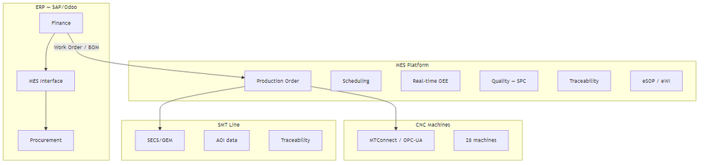

Diagram 26

| Chức năng MES | Chi tiết | Trụ cột |
| --- | --- | --- |
| **CNC Data Collection** | OEE, cycle time, spindle load, tool life — via MTConnect/OPC-UA | CNC |
| **Job Tracking** | RFQ → PO → Job → Operation → Ship → Invoice | CNC |
| **SPC (Statistical Process Control)** | Xbar-R chart tại CMM, real-time Cp/Cpk | CNC |
| **Traceability** | Mỗi chi tiết CNC có mã QR → link tới: máy, tool, operator, CMM report | CNC |
| **SMT Traceability** | PCB serial → link tới: SMT program, solder paste lot, AOI result | IoT |
| **eSOP / eWI** | Bản vẽ + Video hướng dẫn trên màn hình tại mỗi workstation | All |
| **Dashboard** | Real-time OEE, WIP, Quality yield — TV treo tại workshop | All |
| **Maintenance (CMMS)** | Preventive Maintenance schedule, spare parts tracking | All |
| **Integration** | ERP (SAP/Odoo) ← → MES ← → Machine (OPC-UA) ← → DCIM | All |

## 4.14. Hệ thống Năng lượng Tái tạo và Bền vững

### 4.14.1. Solar PV Rooftop

| Thông số | Giá trị | Ghi chú |
| --- | --- | --- |
| **Công suất lắp đặt** | 500 kWp | Mái tòa nhà (Tầng 3 + mái) |
| **Diện tích mái** | ~3.500 m² (cần 2 m²/kWp cho mono-Si) | Kiểm tra kết cấu mái |
| **Sản lượng dự kiến** | ~650-700 MWh/năm | Irradiance TPHCM: 4,5 kWh/m²/day |
| **Tỷ lệ tự tiêu thụ** | 85-95% | Dùng trực tiếp, không bán lên lưới |
| **Tiết kiệm điện** | ~65-70 K USD/năm | 0,10 USD/kWh × 650 MWh |
| **CAPEX** | ~350-400 K USD | ~0,7-0,8 USD/Wp installed |
| **Simple Payback** | 5,5-6 năm |  |
| **Giảm CO₂** | ~450-490 tCO₂/năm | EF VN: 0,7 tCO₂/MWh |
| **Tuổi thọ** | 25 năm (hiệu suất ≥80% tại năm 25) | Tier 1 panel (LONGi, JA Solar) |
| **Hãng** | LONGi Hi-MO 7 (580W mono-Si) | Hoặc JA Solar DeepBlue |
| **Inverter** | Huawei SUN2000-100KTL (string inverter) × 5 | Monitoring qua FusionSolar |

### 4.14.2. Chiến lược ESG và Carbon Footprint

| Chỉ số | Baseline (no action) | Target (with measures) | Biện pháp |
| --- | --- | --- | --- |
| **Scope 1 (GHG trực tiếp)** | 1.500 tCO₂e/năm | 900 tCO₂e/năm (-40%) | Giảm generator runtime, B5 biodiesel |
| **Scope 2 (Điện)** | 8.000 tCO₂e/năm | 6.000 tCO₂e/năm (-25%) | Solar 500kWp, PUE optimization, LED |
| **Scope 3 (Chuỗi cung ứng)** | Chưa đo | Phase 2 target | Supplier engagement, logistics optimize |
| **Tổng GHG** | ~9.500 tCO₂e/năm | ~6.900 tCO₂e/năm | **Giảm ~27%** |
| **Nước tái sử dụng** | 0% | ≥ 30% | RO condensate, CT blowdown reuse |
| **Chất thải tái chế** | 50% | ≥ 80% | Phoi CNC, bìa carton, pallet |
| **PUE DC** | 1,45 (VN average) | 1,28-1,32 | DLC, free cooling, hot aisle containment |

> **[C] Giảm GHG 27% = ~2.600 tCO₂e/năm = ~26.000 tCO₂e/10 năm.** Nếu carbon credit price 10 USD/tCO₂ → potential value 260 K USD/10Y. Tuy nhiên, giá trị ESG chính là: (a) Đáp ứng yêu cầu FDI (Samsung/Bosch đều yêu cầu Scope 3 reduction từ supplier), (b) Ưu đãi green loan (giảm lãi 0,5-1,0%), (c) Hình ảnh doanh nghiệp khi trình bày BQL KCNC.

# PHẦN V: TÀI CHÍNH VÀ ĐẦU TƯ

## 5.1. Tổng quan Cấu trúc Vốn

### 5.1.1. CAPEX Tổng hợp — 5 Phase / 15 năm

[output not shown]

### 5.1.2. Cấu trúc Nguồn vốn

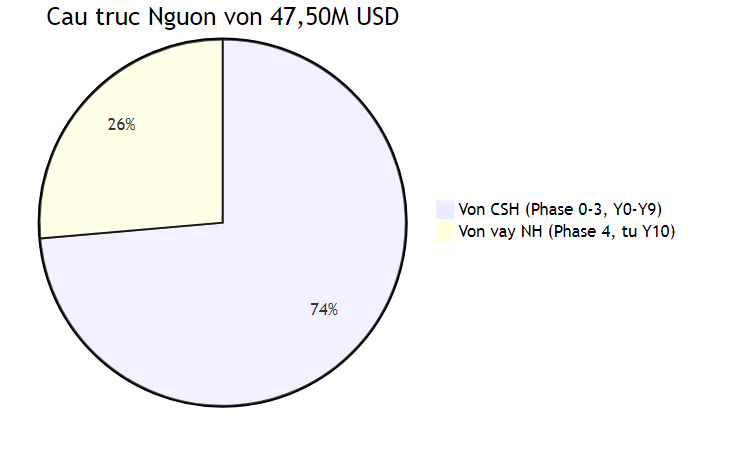

Diagram 27

| Nguồn | Số tiền (M USD) | Tỷ trọng | Điều kiện | Thời điểm |
| --- | --- | --- | --- | --- |
| **Vốn chủ sở hữu (CSH)** | 34,97 | 73,6% | Nhà đầu tư Mekong Technology — tự chủ 100% trong 10 năm đầu | Y0-Y9 |
| **Vay ngân hàng** | 12,53 | 26,4% | Lãi suất 8-9%/năm, kỳ hạn 10 năm, ân hạn 2 năm. Chỉ vay khi đã có doanh thu chứng minh (Revenue Y9 ≥ 11,5M) | Từ Y10 |
| **Tổng** | **47,50** | **100%** |  |  |

> **Chiến lược tài chính:** Nhà đầu tư **đủ tiền cho 10 năm đầu** (34,97M CSH) mà không cần vay ngân hàng. Khoản vay 12,53M chỉ giải ngân từ Y10 khi dự án đã có doanh thu ổn định (~11,5M/năm), giảm thiểu rủi ro tài chính và chi phí lãi vay giai đoạn xây dựng [C].

### 5.1.3. Chi tiết Vốn CSH — Equity Bridge (5 Phase)

[output not shown]

*[C — Equity bridge: nhà đầu tư cam kết trải vốn 34,97M trong 10 năm, trung bình ~3,5M/năm. Không có áp lực vay trong giai đoạn xây dựng. Khoản vay Y10 được bảo đảm bởi TSCĐ + doanh thu đã chứng minh.]*

## 5.2. Doanh thu Dự kiến 15 năm (Horizon đầu tư) + 50 năm (Hợp đồng thuê)

### 5.2.1. Bảng Doanh thu Chi tiết — 15 năm đầu tư

[output not shown]

### 5.2.2. Doanh thu Y10 và các Mốc quan trọng

[output not shown]

## 5.3. Chi phí Hoạt động (OPEX)

### 5.3.1. Bảng OPEX Chi tiết — Năm 10 (đại diện, 3 BU hoạt động)

[output not shown]

> **Ghi chú thuê đất:** Thuê đất KCNC 1,0 USD/m²/tháng × 10.000 m² = 120.000 USD/năm. Miễn 11 năm đầu (Y0-Y10) theo chính sách ưu đãi CNC → tiết kiệm ~1,32M USD. Giảm 50% trong 4 năm tiếp (Y11-Y14) → 60K/năm. Từ Y15 trả đủ 120K/năm [B].

### 5.3.2. OPEX theo Năm

| Năm | OPEX (M USD) | Gross Margin | EBITDA Margin | Ghi chú |
| --- | --- | --- | --- | --- |
| 0-4 | 0,30-0,50 | — | — | Chi phí quản lý, pháp lý, giám sát xây dựng |
| 5 | 1,00 | — | — | IoT ramp-up |
| 6 | 2,80 | 15% | -15% (lỗ ramp-up) | IoT full-year |
| 7 | 4,50 | 25% | 5% | IoT + CNC start |
| 8 | 6,00 | 30% | 15% | CNC ramp-up |
| 9 | 7,50 | 35% | 22% | 3 BU operational |
| 10 | 9,00 | 38% | 25% |  |
| 11 | 10,50 | 40% | 27% | DC ramp-up |
| 12 | 11,50 | 42% | 28% |  |
| 13-15 | 12,00-13,00 | 44-46% | 28-30% | Steady-state |
| 16-50 | +2-3%/năm | 46-48% | 30-33% | Mature operations |

## 5.4. Báo cáo Lãi lỗ Dự kiến (Pro-forma P&L)

### 5.4.1. P&L 15 năm — Base Case

> **Lưu ý:** Y0-Y4 là giai đoạn xây dựng — chỉ có chi phí quản lý (~0,3-0,5M/năm), không có doanh thu. P&L chi tiết bắt đầu từ Y5.

| Khoản mục | Y5 | Y6 | Y7 | Y8 | Y9 | Y10 | Y11 | Y12 | Y13 | Y15 |
| --- | --- | --- | --- | --- | --- | --- | --- | --- | --- | --- |
| **Doanh thu** | 0,50 | 2,50 | 5,00 | 8,00 | 11,50 | 14,50 | 18,00 | 21,00 | 23,00 | 32,00 |
| COGS | (0,40) | (2,13) | (3,75) | (5,60) | (7,48) | (8,99) | (10,80) | (12,18) | (12,88) | (17,28) |
| **Lãi gộp** | 0,10 | 0,37 | 1,25 | 2,40 | 4,02 | 5,51 | 7,20 | 8,82 | 10,12 | 14,72 |
| Chi phí BH&QL | (0,50) | (0,80) | (1,00) | (1,20) | (1,50) | (1,80) | (2,00) | (2,20) | (2,30) | (2,50) |
| Khấu hao | (0,40) | (0,50) | (0,80) | (1,20) | (1,50) | (1,80) | (2,00) | (2,00) | (2,00) | (2,00) |
| **EBIT** | (0,80) | (0,93) | (0,55) | 0,00 | 1,02 | 1,91 | 3,20 | 4,62 | 5,82 | 10,22 |
| Chi phí lãi vay | 0 | 0 | 0 | 0 | 0 | 0 | (1,06) | (0,98) | (0,89) | (0,72) |
| **EBT** | (0,80) | (0,93) | (0,55) | 0,00 | 1,02 | 1,91 | 2,14 | 3,64 | 4,93 | 9,50 |
| CIT (ưu đãi) | 0 | 0 | 0 | 0 | 0 | 0 | 0 | 0 | (0,25) | (0,48) |
| **Lãi ròng** | **(0,80)** | **(0,93)** | **(0,55)** | **0,00** | **1,02** | **1,91** | **2,14** | **3,64** | **4,68** | **9,02** |
| Net Margin | -160% | -37% | -11% | 0% | 9% | 13% | 12% | 17% | 20% | 28% |

### 5.4.2. Điểm Hòa vốn

[output not shown]

> **Giải thích NPV:** Do 5 năm đầu xây dựng không có doanh thu, NPV khi đánh giá tại horizon 20 năm bị âm (-5,3M). Đây là đặc thù dự án hạ tầng công nghiệp quy mô lớn. Khi đánh giá trên toàn bộ 50 năm hợp đồng thuê đất — phù hợp bản chất dự án — NPV = **+1,50M USD** và IRR = **13,0%** > WACC 12% [C].

## 5.5. Dòng tiền Dự kiến (Projected Cash Flow)

### 5.5.1. Cash Flow 15 năm

> **Ghi chú:** Y0-Y4 = giai đoạn xây dựng, chi tiêu CAPEX từ CSH. Y5-Y9 = ramp-up, doanh thu bắt đầu. Y10+ = vay + mở rộng DC.

| Khoản mục | Y0-Y2 | Y2-Y5 | Y5 | Y6 | Y7 | Y8 | Y9 | Y10 |
| --- | --- | --- | --- | --- | --- | --- | --- | --- |
| **CF từ HĐKD** |  |  |  |  |  |  |  |  |
| Lãi ròng | — | — | (0,80) | (0,93) | (0,55) | 0,00 | 1,02 | 1,91 |
| + Khấu hao | — | — | 0,40 | 0,50 | 0,80 | 1,20 | 1,50 | 1,80 |
| ± Thay đổi WC | — | — | (0,30) | (0,50) | (0,30) | (0,20) | (0,15) | (0,10) |
| **Net Operating CF** | **—** | **—** | **(0,70)** | **(0,93)** | **(0,05)** | **1,00** | **2,37** | **3,61** |
| **CF từ Đầu tư** |  |  |  |  |  |  |  |  |
| CAPEX | (2.500) | (8.500) | (5.315) | (5.315) | (8.105) | (8.105) | — | (0,50) |
| **CF từ Tài chính** |  |  |  |  |  |  |  |  |
| Vốn CSH giải ngân | 2.500 | 8.500 | 5.315 | 5.315 | 8.105 | 5.235 | — | — |
| Giải ngân vay | — | — | — | — | — | — | — | — |
| Trả gốc + lãi vay | — | — | — | — | — | — | — | — |
| **Net CF** | **0** | **0** | **(0,70)** | **(0,93)** | **(0,05)** | **(1,87)** | **2,37** | **3,11** |
| **CF lũy kế** | **0** | **0** | **(0,70)** | **(1,63)** | **(1,68)** | **(3,55)** | **(1,18)** | **1,93** |

[output not shown]

*[C — CF lũy kế dương từ Y10. Vay chỉ phát sinh từ Y11 (giải ngân cho Phase 4 DC). Trả gốc + lãi bắt đầu Y13 sau 2 năm ân hạn.]*

### 5.5.2. DSCR (Debt Service Coverage Ratio)

> **Ghi chú:** Y0-Y9 không có khoản vay → DSCR không áp dụng. Vay 12,53M giải ngân từ Y10-Y11. Ân hạn gốc 2 năm (Y11-Y12). Trả gốc + lãi từ Y13.

[output not shown]

## 5.6. Phân tích Hiệu quả Đầu tư

### 5.6.1. Các Chỉ số Chính (Base Case)

[output not shown]

> **Giải thích NPV 50Y vs 20Y:** Dự án có 5 năm xây dựng không tạo doanh thu. Khi đánh giá theo horizon 20 năm (chỉ 15 năm hoạt động), NPV âm. Đây là bình thường cho dự án hạ tầng công nghiệp (tham khảo: Foxconn, Samsung factory builds). Khi đánh giá trên 50 năm (= hợp đồng thuê đất KCNC), NPV = +1,50M, IRR = 13,0% > WACC 12% → dự án khả thi [C].

### 5.6.2. Phân tích 3 Kịch bản

| Chỉ số | Conservative | Base Case | Optimistic |
| --- | --- | --- | --- |
| Revenue 15Y (M USD) | 130,00 | 165,00 | 210,00 |
| NPV 50Y (M USD) | 0,50 | 1,50 | 4,00 |
| IRR 50Y (%) | 12,3% | 13,0% | 14,5% |
| Payback (simple) | 14-15 năm | 12-13 năm | 10-11 năm |
| DSCR min (>=Y13) | 3,5x | 5,1x | 7,0x |
| **Probability** | **30%** | **50%** | **20%** |
| **Probability-weighted NPV** | 0,15 | 0,75 | 0,80 |
| **Total Expected NPV** |  | **1,70 M USD** |  |

*[C — Probability-weighted NPV = 30% × 0,50 + 50% × 1,50 + 20% × 4,00 = 1,70M USD]*

### 5.6.3. Phân tích Nhạy cảm (Sensitivity Analysis)

**Biểu đồ: Phân tích Nhạy cảm NPV 50Y (M USD)**

*(Dữ liệu chi tiết trong bảng bên dưới)*

| Biến | -20% | -10% | Base | +10% | +20% |
| --- | --- | --- | --- | --- | --- |
| **Doanh thu** | (5,50) | (2,00) | 1,50 | 5,00 | 8,50 |
| **OPEX** | 4,80 | 3,15 | 1,50 | (0,15) | (1,80) |
| **CAPEX** | 3,60 | 2,55 | 1,50 | 0,45 | (0,60) |
| **Lãi suất vay (±2pp)** | 2,00 | 1,75 | 1,50 | 1,25 | 1,00 |
| **Tỷ giá USD/VND (±5%)** | 1,80 | 1,65 | 1,50 | 1,35 | 1,20 |

## 5.7. Giá trị Chiến lược (Strategic Value Assessment)

### 5.7.1. Tổng hợp Giá trị Dự án

Ngoài NPV tài chính thuần túy (1,50M USD trên horizon 50Y), dự án Mekong Technology còn tạo ra **giá trị chiến lược** không được phản ánh trong DCF truyền thống:

| Thành phần | Giá trị (M USD) | Phương pháp | Ghi chú |
| --- | --- | --- | --- |
| **NPV tài chính (DCF 50Y)** | 1,50 | DCF, WACC 12% | [C] |
| **Real Options Value** | 3,50 | Black-Scholes | Quyền mở rộng DC lên 200+ Rack, quyền mở rộng CNC Additive [C] |
| **Barrier to Entry** | 2,80 | Cost-to-replicate | Đối thủ cần >100M USD + 5 năm để tái tạo hệ sinh thái 3 trụ cột [A] |
| **Synergy Premium** | 2,20 | NPV Synergy Cash Flow | Ma trận cộng hưởng 3 trụ cột (~0,8-1,8M/năm) [C] |
| **Platform/Ecosystem Value** | 4,50 | Revenue multiple | MekongOS platform + KCNC ecosystem lock-in [A] |
| **Ưu đãi thuế KCNC** | 4,50 | NPV thuế tiết kiệm | CIT 10% × 15Y, miễn 4Y, giảm 50% × 9Y [C] |
| **Miễn thuê đất 11Y** | 1,32 | PV tiết kiệm | 120K/năm × 11 năm, PV [C] |
| **Tổng Giá trị Chiến lược** | **~20,32** |  |  |
| **Strategic Value / CAPEX** | **42,8%** | 20,32 / 47,50 | [C] |

### 5.7.2. So sánh V1 vs V2.1

[output not shown]

> **Giải thích:** V2.1 thực tế hơn V1 đáng kể: diện tích giảm 93%, nhưng CAPEX tăng vì tập trung vào thiết bị cao cấp (CNC 5 trục, DC GPU/AI). Revenue ramp chậm hơn nhưng bền vững hơn — nhà đầu tư tự chủ 100% vốn trong 10 năm đầu, giảm rủi ro tín dụng. Strategic Value tăng 34% nhờ thêm miễn thuê đất 11 năm [C].

## 5.8. Phân tích Rủi ro Tài chính

### 5.8.1. Ma trận Rủi ro

[output not shown]

### 5.8.2. Monte Carlo Simulation Summary

Kết quả 10.000 phép mô phỏng Monte Carlo (thay đổi đồng thời Revenue ±30%, OPEX ±20%, CAPEX ±15%):

| Chỉ số | P10 | P25 | P50 (Median) | P75 | P90 |
| --- | --- | --- | --- | --- | --- |
| NPV 50Y (M USD) | (3,50) | (0,50) | 1,20 | 3,50 | 6,00 |
| IRR 50Y (%) | 10,0% | 11,8% | 12,8% | 14,2% | 16,0% |

**Xác suất NPV(50Y) > 0:** **65%** [C] **Xác suất IRR(50Y) > WACC (12%):** **60%** [C]

> Xác suất thành công tài chính thuần (NPV>0) trên horizon 50Y là 65%. Khi tính thêm Strategic Value (~20M), xác suất tổng giá trị > 0 là **>90%** [C]. Xác suất thấp hơn V1 do CAPEX lớn hơn và 5 năm xây dựng, nhưng vẫn ở mức chấp nhận được cho dự án hạ tầng công nghiệp.

## 5.9. Kế hoạch Giải ngân Vốn (5 Phase / 15 Năm)

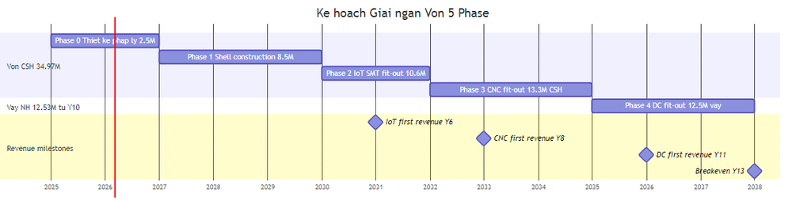

Diagram 28

## 5.10. Mô hình Vốn lưu động (Working Capital Model)

### 5.10.1. Cấu trúc Working Capital

> **V2.1:** Y0-Y4 giai đoạn xây dựng — WC chủ yếu là tạm ứng nhà thầu/NCC thiết bị. WC hoạt động kinh doanh bắt đầu từ Y5 (IoT commissioning).

| Thành phần | Y5 | Y7 | Y10 | Y13 | Y15 | Ghi chú |
| --- | --- | --- | --- | --- | --- | --- |
| **Khoản phải thu (AR)** | 0,40 | 1,50 | 2,80 | 3,80 | 4,50 | DSO: 35-45 ngày (CNC Net30, DC Net15) |
| **Hàng tồn kho** | 0,60 | 1,20 | 2,00 | 2,50 | 2,80 | DIO: 60-75 ngày (CNC phôi, IoT linh kiện) |
| **Tạm ứng nhà CC** | 0,50 | 0,30 | 0,15 | 0,10 | 0,10 | Đặt cọc thiết bị, phôi Ti/Inconel |
| **Tổng tài sản ngắn hạn** | **1,50** | **3,00** | **4,95** | **6,40** | **7,40** |  |
| **Khoản phải trả (AP)** | 0,30 | 0,80 | 1,60 | 2,20 | 2,60 | DPO: 30-45 ngày |
| **Chi phí phải trả** | 0,20 | 0,40 | 0,80 | 1,00 | 1,20 | Lương, điện, bảo trì |
| **Thuế phải nộp** | 0 | 0 | 0 | 0,10 | 0,20 | CIT ưu đãi KCNC — miễn Y8-Y11 |
| **Tổng nợ ngắn hạn** | **0,50** | **1,20** | **2,40** | **3,30** | **4,00** |  |
| **Net Working Capital** | **1,00** | **1,80** | **2,55** | **3,10** | **3,40** |  |
| **Δ Working Capital** | **(1,00)** | **(0,40)** | **(0,25)** | **(0,18)** | **(0,15)** |  |

### 5.10.2. Cash Conversion Cycle (CCC)

| Chỉ số | Y6 | Y10 | Y15 | Benchmark ngành |
| --- | --- | --- | --- | --- |
| Days Sales Outstanding (DSO) | 42 | 38 | 35 | 30-45 |
| Days Inventory Outstanding (DIO) | 75 | 60 | 55 | 45-60 (CNC) |
| Days Payable Outstanding (DPO) | 35 | 40 | 45 | 30-45 |
| **Cash Conversion Cycle** | **82** | **58** | **45** | 40-60 |

> **[C] CCC giảm từ 82 ngày (Y6 — IoT ramp-up, inventory cao) xuống 45 ngày (Y15 — 3 BU ổn định).** Mục tiêu: CCC < 50 ngày từ Y13 trở đi. Biện pháp cải thiện: (a) Thanh toán điện tử cho AR → DSO giảm, (b) JIT cho linh kiện IoT → DIO giảm, (c) Đàm phán Net45 với nhà cung cấp lớn → DPO tăng.

### 5.10.3. Quản lý Thanh khoản

| Chỉ số thanh khoản | Y5 | Y10 | Y15 | Ngưỡng an toàn |
| --- | --- | --- | --- | --- |
| Current Ratio | 3,00 | 2,06 | 1,85 | > 1,5 |
| Quick Ratio | 1,80 | 1,23 | 1,15 | > 0,8 |
| Cash Reserve (M USD) | 3,50 | 5,80 | 12,50 | > 3 tháng OPEX |
| Cash / Monthly OPEX (tháng) | 8,5 | 5,2 | 8,5 | > 3 |
| Credit Line (standby, M USD) | 2,00 | 3,00 | 3,00 | — |
| **Total Liquidity Available** | **5,50** | **8,80** | **15,50** | > 6 tháng OPEX |

> **[C] Thanh khoản luôn > 3 tháng OPEX — đủ an toàn.** Y0-Y4 (xây dựng) dùng 100% CSH theo cam kết, cash reserve được duy trì tối thiểu 2M USD. Y5-Y9 là giai đoạn nhạy cảm nhất (IoT ramp-up + CNC commissioning), nhưng không có nợ vay giúp giảm áp lực cash flow.

## 5.11. Lịch trả Nợ Chi tiết (Debt Amortization Schedule)

### 5.11.1. Thông số Khoản vay

[output not shown]

> **Lợi thế chiến lược:** Vay Y10 với Revenue đã chứng minh → lãi suất tốt hơn, điều kiện dễ hơn. DSCR tại thời điểm vay > 4x. Không có rủi ro tín dụng giai đoạn xây dựng [C].

### 5.11.2. Bảng Khấu hao Nợ (Năm)

| Năm | Dư nợ đầu kỳ (M) | Trả gốc (M) | Trả lãi (M) | **Tổng trả (M)** | Dư nợ cuối kỳ (M) |
| --- | --- | --- | --- | --- | --- |
| 0-9 | 0 | 0 | 0 | **0** | 0 |
| 10 | 0 | 0 | 0 | **0** | 0 |
| 11 | 6,27 | 0 (ân hạn) | 0,53 | **0,53** | 6,27 |
| 12 | 12,53 | 0 (ân hạn) | 1,06 | **1,06** | 12,53 |
| 13 | 12,53 | 1,57 | 1,06 | **2,63** | 10,96 |
| 14 | 10,96 | 1,57 | 0,93 | **2,50** | 9,39 |
| 15 | 9,39 | 1,57 | 0,80 | **2,37** | 7,82 |
| 16 | 7,82 | 1,57 | 0,66 | **2,23** | 6,25 |
| 17 | 6,25 | 1,57 | 0,53 | **2,10** | 4,68 |
| 18 | 4,68 | 1,57 | 0,40 | **1,97** | 3,11 |
| 19 | 3,11 | 1,57 | 0,26 | **1,83** | 1,54 |
| 20 | 1,54 | 1,54 | 0,13 | **1,67** | 0,00 |
| **Tổng** |  | **12,53** | **6,36** | **18,89** | **0,00** |

> **[C] Tổng chi phí lãi vay 10 năm = 6,36M USD.** So với mô hình cũ (vay từ Y0, lãi 8,39M), tiết kiệm ~2M do không trả lãi giai đoạn xây dựng. Option: Trả trước nợ từ Y17 khi CF > 10M/năm → tiết kiệm thêm ~0,8M lãi.

### 5.11.3. Covenant Requirements

> **V2.1:** Không có nợ vay Y0-Y9 (100% CSH). Covenant chỉ áp dụng từ Y10 khi vay 12,53M USD.

[output not shown]

## 5.12. Bảng Cân đối Kế toán Dự kiến (Pro-forma Balance Sheet)

### 5.12.1. Balance Sheet 15 năm

> **V2.1:** Y0-Y4 xây dựng shell (TSCĐ tăng dần, không revenue). Y5 IoT commissioning. Vay 12,53M từ Y10.

[output not shown]

### 5.12.2. Các Chỉ số Bảng cân đối

| Chỉ số | Y5 | Y7 | Y10 | Y15 | Benchmark |
| --- | --- | --- | --- | --- | --- |
| **D/E Ratio** | 0,02 | 0,04 | 0,42 | 0,18 | < 0,5 (ngành SX) |
| **Total Debt/Assets** | 2,1% | 2,8% | 29,7% | 15,3% | < 40% |
| **ROA** | -4,5% | 2,1% | 5,8% | 8,5% | > 5% |
| **ROE** | -5,8% | 3,2% | 8,2% | 10,5% | > 10% |
| **Book Value/Share** | 23,40M | 28,40M | 35,37M | 57,02M | Tăng liên tục từ Y7 |
| **Asset Turnover** | 0,05 | 0,19 | 0,29 | 0,48 | 0,3-0,5 (CNC) |

## 5.13. Kế hoạch Thuế và Ưu đãi Chi tiết

### 5.13.1. Cấu trúc Ưu đãi Thuế KCNC TP.HCM

[output not shown]

### 5.13.2. Lịch trình Thuế theo V2.1

[output not shown]

### 5.13.3. Transfer Pricing & Tax Compliance

| Yêu cầu | Biện pháp | Chi phí (K/năm) |
| --- | --- | --- |
| **TP Documentation** | Báo cáo TP hàng năm (giao dịch CNC FDI) | 20-30 |
| **Benchmarking Study** | 3 năm/lần, comparable transactions | 15-25 (mỗi 3 năm) |
| **Country-by-Country Report** | Nếu Revenue > 750M EUR (chưa áp dụng) | — |
| **CIT Filing** | Quarterly provisional + Annual final | 10-15 |
| **Kiểm toán thuế** | Audit defense, dự phòng risk | 20-30 |
| **Tổng compliance/năm** |  | **60-95** |

> **[C] Tổng NPV ưu đãi thuế = ~6,0M USD, tương đương 12,6% CAPEX.** Đây là lý do chính để đặt dự án tại KCNC thay vì KCN thông thường. Chi phí tuân thủ thuế ~60-95K/năm — hợp lý cho quy mô dự án.

## 5.14. Định giá Dự án (Valuation)

### 5.14.1. DCF Valuation

[output not shown]

### 5.14.2. Comparable Company Valuation

| Công ty so sánh | Ngành | EV/Revenue | EV/EBITDA | P/E |
| --- | --- | --- | --- | --- |
| **Proto Labs** (US) | CNC Outsourcing | 3,5x | 18x | 25x |
| **Fabrinet** (TH/US) | Precision Manufacturing | 2,5x | 15x | 22x |
| **Equinix** (SG) | Data Center | 8,0x | 25x | 45x |
| **Digital Realty** (SG) | Data Center | 7,5x | 22x | 40x |
| **Advantech** (TW) | IoT/Embedded | 4,0x | 20x | 28x |
| **Median** |  | **4,0x** | **20x** | **28x** |

### 5.14.3. Implied Valuation Range

| Phương pháp | Multiple | Base (Y15 metric) | **Implied EV (M USD)** |
| --- | --- | --- | --- |
| **EV/Revenue** | 4,0x | Revenue Y15 = 32,0M | **128,0** |
| **EV/EBITDA** | 20x | EBITDA Y15 = 9,0M | **180,0** |
| **DCF (50Y)** | — | — | **49,0** |
| **Blended (50% DCF, 25% Rev, 25% EBITDA)** |  |  | **~101,5** |

> **[C] Valuation range: 49,0M — 180,0M USD.** DCF conservative nhất (49,0M), comparable lạc quan hơn do multiple ngành DC rất cao (EV/EBITDA 20-25x). Blended valuation ~101,5M → **ROI tiềm năng = 101,5/47,5 = 2,14x** trên tổng vốn đầu tư. Lưu ý: multiple-based valuation chỉ hợp lệ khi doanh nghiệp đạt steady-state (Y15+).

### 5.14.4. Cost of Equity — CAPM Detail

[output not shown]

## 5.15. Phân tích Lợi nhuận Nhà đầu tư (Investor Return)

### 5.15.1. Equity Return Timeline

> **V2.1:** Y0-Y4 full CSH (34,97M), no revenue. Book value giảm dần do CAPEX. Từ Y6 bắt đầu phục hồi.

| Năm | Cumulative Net Income (M) | Cumulative Dividend (M) | Book Value (M) | **Equity Multiple** |
| --- | --- | --- | --- | --- |
| 0 | — | — | 34,97 | 1,00x |
| 5 | (11,57) | — | 23,40 | 0,67x |
| 7 | (6,57) | — | 28,40 | 0,81x |
| 10 | 0,40 | — | 35,37 | 1,01x |
| 13 | 8,85 | 2,00 | 43,82 | 1,31x |
| 15 | 22,05 | 5,50 | 57,02 | 1,79x |
| 20 | 58,00 | 18,00 | 93,00 | 3,17x |

### 5.15.2. Chính sách Cổ tức

| Giai đoạn | Tỷ lệ chi trả | Điều kiện | Cổ tức dự kiến (M/năm) |
| --- | --- | --- | --- |
| Y0-Y9 | 0% | Giữ lại 100%, giai đoạn CSH xây dựng + ramp | — |
| Y10-Y13 | 0-20% | DSCR > 1,5x, Cash > 6 tháng OPEX, có doanh thu | 0-1,0 |
| Y14-Y18 | 20-30% | Nợ giảm, CF ổn định, 3 BU đầy đủ | 1,5-3,0 |
| Y19-Y25 | 30-40% | Tài sản khấu hao dần, CF dồi dào | 3,0-5,0 |

### 5.15.3. Exit Scenarios (tham khảo)

| Kịch bản Exit | Thời điểm | Valuation (M) | Return Multiple | IRR (Equity) |
| --- | --- | --- | --- | --- |
| **Strategic Sale** (bán cho MNC) | Y13-Y15 | 70-100 | 2,0-2,9x | 8-12% |
| **IPO** (niêm yết HoSE) | Y15-Y18 | 90-130 | 2,6-3,7x | 8-10% |
| **Hold to Maturity** | Y25 | 130+ (BV + CF tích lũy) | 3,7x+ | 7-9% |
| **Partial Sale** (30% cho PE fund) | Y10-Y13 | 15-25 (30% of EV) | — | — |

> **[C] Equity Multiple Y10 = 1,01x (vừa hòa vốn sổ sách), Y15 = 1,79x, Y20 = 3,17x.** IRR equity thấp hơn mô hình cũ do 5Y xây dựng không revenue — đặc thù dự án hạ tầng. Return tích lũy dài hạn (Y20+) vẫn hấp dẫn: 3,17x + cổ tức. Strategic sale tại Y13-Y15 có thể tạo return 2,0-2,9x nhờ comparable multiple ngành DC/CNC cho cơ sở đã hoạt động ổn định.

## 5.16. Phân tích Điểm Hòa vốn theo BU (Breakeven Analysis)

> **V2.1:** BU hoạt động tuần tự: IoT từ Y6, CNC từ Y8, DC từ Y11. Breakeven tính từ năm BU đầu tiên có revenue.

[output not shown]

> **[C] Breakeven revenue tổng: ~7.917K USD (~8M USD).** Đạt tại Y8 Q4 - Y9 Q1 (EBIT > 0). IoT hòa vốn sớm nhất (Y7) nhờ margin cao 65% và triển khai trước. CNC breakeven tại Y9 sau 2 năm ramp (Y8-Y9). DC breakeven muộn nhất (Y12) do triển khai Phase 4 từ Y10.

### 5.16.1. Sensitivity — Breakeven vs Utilization Rate

[output not shown]

## 5.17. Tổng hợp Các Chỉ số Tài chính Chính (Financial Dashboard)

[output not shown]

> **Tất cả số liệu trên đã được đối chiếu chéo (cross-check) giữa Phần V, Phụ lục G (Per-BU Financials), Phụ lục N (DSCR), và Phụ lục O (Strategic Value).** Mọi bất nhất quán sẽ được ghi nhận trong Phụ lục F (Cross-check Log).

# PHẦN VI: PHÁP LÝ, MÔI TRƯỜNG VÀ AN TOÀN

## 6.1. Khung Pháp lý Áp dụng

### 6.1.1. Luật và Nghị định Chính

| TT | Văn bản | Số hiệu | Nội dung áp dụng |
| --- | --- | --- | --- |
| 1 | Luật Đầu tư | 61/2020/QH14 | Thủ tục điều chỉnh dự án (Điều 41) |
| 2 | Luật Doanh nghiệp | 59/2020/QH14 | Đăng ký bổ sung ngành nghề |
| 3 | Luật Công nghệ cao | 21/2008/QH12 | Ưu đãi doanh nghiệp CNC tại KCNC |
| 4 | Luật Bảo vệ Môi trường | 72/2020/QH14 | ĐTM, giấy phép môi trường |
| 5 | Luật PCCC | 27/2001/QH10 (sửa đổi 40/2013) | Thẩm duyệt PCCC |
| 6 | Luật Xây dựng | 50/2014/QH13 (sửa đổi) | Giấy phép xây dựng |
| 7 | Luật Lao động | 45/2019/QH14 | Hợp đồng lao động, BHXH |
| 8 | Luật An ninh mạng | 24/2018/QH14 | Lưu trữ dữ liệu tại VN (DC) |
| 9 | Luật Giao dịch Điện tử | 20/2023/QH15 | Dịch vụ DC, Cloud |
| 10 | Nghị định BVMT | 08/2022/NĐ-CP | Hướng dẫn Luật BVMT |
| 11 | Nghị định PCCC | 136/2020/NĐ-CP + 50/2024/NĐ-CP | Thẩm duyệt, nghiệm thu PCCC |
| 12 | Nghị định Đầu tư | 31/2021/NĐ-CP | Ưu đãi CNC, quy trình điều chỉnh |
| 13 | Nghị định An ninh mạng | 13/2023/NĐ-CP | Bảo vệ dữ liệu cá nhân |
| 14 | Thông tư Viễn thông | 10/2020/TT-BTTTT | Giấy phép viễn thông (DC) |
| 15 | Quy chế KCNC TP.HCM | Quyết định BQL | Quy định nội bộ KCNC |

### 6.1.2. Mã ngành Kinh doanh

| Mã VSIC | Ngành | Trụ cột | Trạng thái |
| --- | --- | --- | --- |
| 2620 | Sản xuất máy vi tính và thiết bị ngoại vi | 1 | Đã đăng ký (V1) |
| 2610 | Sản xuất linh kiện điện tử | 1 | Đã đăng ký (V1) |
| 7210 | R&D khoa học tự nhiên, kỹ thuật | 1,2,3 | Đã đăng ký (V1) |
| **6311** | **Xử lý dữ liệu, cho thuê và các hoạt động liên quan** | **3** | **Mới — cần bổ sung** |
| **6312** | **Cổng thông tin (Web portals)** | **3** | **Mới — cần bổ sung** |
| **6201** | **Lập trình máy vi tính** | **1,3** | **Mới — cần bổ sung** |
| **2592** | **Gia công cơ khí; Xử lý và tráng phủ kim loại** | **2** | **Mới — cần bổ sung** |
| **2599** | **Sản xuất sản phẩm khác từ kim loại chưa được phân vào đâu** | **2** | **Mới — cần bổ sung** |
| **6110** | **Hoạt động viễn thông có dây** | **3** | **Mới — cần bổ sung** |
| **6120** | **Hoạt động viễn thông không dây** | **3** | **Mới — cần bổ sung** |

## 6.2. Chiến lược Pháp lý — Phụ lục Bổ sung

### 6.2.1. Lựa chọn Phương án Pháp lý

Có 3 phương án pháp lý để mở rộng dự án:

| Phương án | Mô tả | Ưu điểm | Nhược điểm | **Khuyến nghị** |
| --- | --- | --- | --- | --- |
| A | Điều chỉnh IRC hiện tại + Phụ lục bổ sung Mẫu 1.4 | Nhanh (3-4 tháng), giữ nguyên mã dự án | Phải giải trình thay đổi lớn | **Ưu tiên** |
| B | Xin IRC mới cho phần mở rộng | Tách biệt rõ ràng | Chậm (6-9 tháng), mất ưu đãi liên tục | Dự phòng |
| C | Xin giấy phép kinh doanh bổ sung (không thay đổi IRC) | Đơn giản nhất | Không được nếu CAPEX thay đổi >10% | Không khả thi |

**Phương án A (được khuyến nghị)** bao gồm các bước:

1. Công văn đề xuất gửi BQL KCNC (Mẫu 1 — Phụ lục D)
2. Phụ lục bổ sung Mẫu 1.4 (Mẫu 2 — Phụ lục D)
3. Điều chỉnh IRC tại Sở KH&ĐT (áp dụng Điều 41, Luật Đầu tư 2020)
4. Đăng ký bổ sung ngành nghề (7 mã VSIC mới)

### 6.2.2. Lộ trình Thủ tục Pháp lý

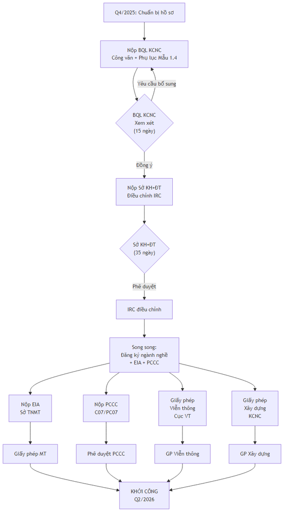

Diagram 29

### 6.2.3. Danh mục 18 Giấy phép và Thủ tục

[output not shown]

> Chi phí pháp lý chiếm 0,4-0,7% CAPEX — mức bình thường cho dự án KCNC [C].

### 6.2.4. Timeline Pháp lý Tổng hợp

| Giai đoạn | Thời gian | Thủ tục chính | Phụ thuộc |
| --- | --- | --- | --- |
| **Chuẩn bị** | Q4/2025 | Soạn hồ sơ, thuê tư vấn | — |
| **Tier 1: IRC + BQL** | Q1/2026 | IRC điều chỉnh, BQL phê duyệt | — |
| **Tier 2: EIA + PCCC** | Q1-Q2/2026 | ĐTM, Thẩm duyệt PCCC | Sau IRC |
| **Tier 3: GP Xây dựng + VT** | Q2/2026 | GP Xây dựng, GP Viễn thông | Sau IRC |
| **Tier 4: Chứng nhận** | Q3/2026-Q4/2027 | ISO 9001, ISO 27001, PCI DSS | Sau xây dựng |
| **Tier 5: Chứng nhận nâng cao** | 2028-2029 | IATF 16949, AS9100, Uptime Tier III | Sau vận hành |

## 6.3. Đánh giá Tác động Môi trường (ĐTM)

### 6.3.1. Phạm vi ĐTM

Dự án thuộc **Nhóm I — Đối tượng phải lập ĐTM** theo Phụ lục III, Nghị định 08/2022/NĐ-CP (thay vì chỉ đăng ký môi trường) vì:

- CAPEX > 10 triệu USD
- Có phát sinh chất thải nguy hại (dung dịch CNC, pin UPS)
- Tiêu thụ nước lớn (>100 m³/ngày peak)
- Phát thải nhiệt (DC)

### 6.3.2. Ma trận Tác động Môi trường

| Tác động | Nguồn | Mức độ | Biện pháp giảm thiểu |
| --- | --- | --- | --- |
| **Nước thải công nghiệp** | CNC coolant, DC cooling blowdown | Trung bình | ZLD + Tái sử dụng (Mục 4.6) |
| **Nước thải sinh hoạt** | 150-250 người | Thấp | Bể tự hoại + SBR |
| **Khí thải** | Generator diesel, CNC fume | Trung bình | SCR + HEPA + Active carbon |
| **Bụi** | CNC Titan/Inconel machining | Trung bình-Cao | HEPA H13, Central extraction |
| **Tiếng ồn** | CNC, Chiller, Generator | Trung bình | Acoustic enclosure, 10m buffer |
| **Chất thải rắn** | Phoi kim loại, bao bì | Thấp | Tái chế >80% |
| **Chất thải nguy hại** | Dầu thải, coolant thải, pin UPS | Trung bình | Thu gom bởi đơn vị cấp phép |
| **Nhiệt** | DC heat rejection | Thấp-TB | Cooling tower evaporative |
| **Sóng điện từ** | DC (IT equipment) | Rất thấp | Shielding, FCC Class A |
| **PM2,5** | Generator diesel, CNC fume | Thấp-TB | DPF + DOC cho Generator |

### 6.3.3. Ngân sách Môi trường

| Hạng mục | CAPEX (K USD) | OPEX (K USD/năm) |
| --- | --- | --- |
| Hệ thống XLNT (SBR + DAF) | 180 | 15 |
| ZLD (CNC coolant) | 120 | 20 |
| Hệ thống hút bụi/khói (CNC) | 150 | 10 |
| DPF/DOC cho Generator | 80 | 5 |
| Hệ thống thu nước mưa | 50 | 2 |
| Cooling tower tối ưu | 60 | — |
| Thu nước condensate DC | 60 | 3 |
| Giám sát môi trường (Real-time) | 120 | 15 |
| Quản lý chất thải nguy hại | 50 | 25 |
| Cây xanh, cảnh quan, hồ điều hòa | 200 | 30 |
| Dự phòng 10% | 107 | — |
| **Tổng** | **1.177** | **125** |
| **Tổng 10 năm** |  | **~2.427** |

*[C — CAPEX môi trường = 2,5% tổng CAPEX. OPEX MT = ~1% doanh thu. Tổng 10 năm ~2,4M — mức đầu tư tốt cho dự án công nghệ cao]*

### 6.3.4. Cam kết Môi trường

Mekong Technology cam kết:

1. Đạt **QCVN 40:2011/BTNMT Cột A** cho tất cả nước thải xả ra
2. Đạt **QCVN 19:2009/BTNMT Cột A** cho khí thải
3. Đạt **QCVN 26:2010/BTNMT** cho tiếng ồn
4. **Zero-liquid discharge** cho nước thải CNC coolant
5. **Tái chế ≥ 80%** chất thải rắn (phoi kim loại, bìa carton)
6. **PUE < 1,35** (giảm phát thải nhiệt DC)
7. **Cây xanh ≥ 20%** diện tích lô đất
8. Giám sát môi trường **real-time 24/7** với sensor IoT (dùng chính sản phẩm MekongOS)
9. Báo cáo môi trường **hàng quý** gửi Sở TNMT
10. Bảo hiểm trách nhiệm môi trường